# Integrate_GeneModels_Obiroi

```r
 if(any(duplicated(findOverlaps(potentialTranscript,ShortStringtie_exonsByGene)@to))){


 AltModels <- ShortStringtie_exonsByTranscript[ShortStringtie_exonsByTranscript %over% overlapRange]

 if(length(AltModels) > 0){

 polyA_lastExon <- polyAModel[length(polyAModel)]
 following_firstExon <- followingModel[1]

 commonExonsOverlap <- intersect(findOverlaps(AltModels,c(polyA_lastExon))@from,
 findOverlaps(AltModels,c(following_firstExon))@from)
 if(length(commonExonsOverlap) > 0){
  AltModels <- AltModels[commonExonsOverlap]
 }
 AltModel <- AltModels[[which.max(sum(width(AltModels)))]]
 overlapAlt <- findOverlaps(overlapRange,AltModel,type = "within")
 if(length(overlapAlt) == 1){
  tempFollowerList <- list(followingTranscript$tx_name)
  names(tempFollowerList) <- polyTranscript$tx_name
  renameFollowersInList <- c(renameFollowersInList,tempFollowerList)
  polyAModel <- GenomicRanges::reduce(c(polyAModel,overlapRange,followingModel))
  temp <- list("Taking model from Short Read - creating a merged exon")
  names(temp) <- toi
  reason <- c(reason,temp)
  message("Making a merge by joining by extending exons")
 }else{
  message("Making a merge by adding new junction")

  temp <- list("Taking model from Short Read - filling in model with junctions")
  names(temp) <- toi
  reason <- c(reason,temp)

  overlapAlt2 <- findOverlaps(AltModel,overlapRange,type = "within")
  missingExons <- NULL
  if(length(overlapAlt2)> 0){
   message("Help")
   missingExons <- AltModel[overlapAlt2@from]
  }

  polyA_lastExon <- polyAModel[length(polyAModel)]
  following_firstExon <- followingModel[1]
  AltModel_overlap_polyA_lastExon <- AltModel[AltModel %over% polyA_lastExon]
  AltModel_overlap_following_firstExon <- AltModel[AltModel %over% following_firstExon]
  if(length(AltModel_overlap_polyA_lastExon) > 0){
   start(polyAModel[length(polyAModel)]) <- start(AltModel_overlap_polyA_lastExon)
  }else{
   polyAModel <- polyAModel[-length(polyAModel)]
  }
  end(followingModel[1]) <- end(AltModel_overlap_following_firstExon)


  tempFollowerList <- list(followingTranscript$tx_name)
  names(tempFollowerList) <- polyTranscript$tx_name
  renameFollowersInList <- c(renameFollowersInList,tempFollowerList)
  polyAModel <- c(polyAModel,missingExons,followingModel)
 }
 }else{
  temp <- list("No overlapping exons, connectioing by junction")
  tempFollowerList <- list(followingTranscript$tx_name)
  names(tempFollowerList) <- polyTranscript$tx_name
  renameFollowersInList <- c(renameFollowersInList,tempFollowerList)
  polyAModel <- c(polyAModel,followingModel)
  names(temp) <- toi
  reason <- c(reason,temp)
 }
 }else{
  temp <- list("Following didnt overlap same Shortread Stringtie gene as polyA gene")
  names(temp) <- toi
  reason <- c(reason,temp)

 }
 }else{
  temp <- list("Following didnt overlap same RefSeq gene as polyA gene")
  names(temp) <- toi
  reason <- c(reason,temp)
 }
 mcols(polyAModel) <- NULL
 mcols(polyAModel) <- data.frame(source="StringTie_curated",type="exon",score=NA,phase=NA,gene_id=gsub("\\.\\d+$","",toi),transcript_id=toi)
 tempGR <- GRangesList(polyAModel)
 names(tempGR) <- toi
 polAmodelList <- c(polAmodelList,tempGR)
}

temp <- unlist(polAmodelList)
rtracklayer::export(temp,con="test_neg1.gtf")

tempOverlap <- findOverlaps(polAmodelList,polAmodelList) %>% as.data.frame()
tempOverlap <- apply(tempOverlap,1,sort) %>% t %>% as.data.frame %>% distinct
tempOverlap <- tempOverlap[tempOverlap[,1] != tempOverlap[,2],]

polAmodelList2 <- polAmodelList
for(i in 1:nrow(tempOverlap)){
 temp <- GenomicRanges::reduce(c(polAmodelList[[tempOverlap[i,2]]],polAmodelList[[tempOverlap[i,1]]]))
 mcols(temp) <- NULL
 mcols(temp) <- data.frame(source="StringTie_curated",type="exon",score=NA,phase=NA,
              gene_id=gsub("\\.\\d+$","",names(polAmodelList[tempOverlap[i,2]])),
              transcript_id=names(polAmodelList[tempOverlap[i,2]]))
 polAmodelList2[[tempOverlap[i,2]]] <- temp
}

polAmodelList2 <- polAmodelList2[-tempOverlap[,1]]

temp <- unlist(polAmodelList2)
rtracklayer::export(temp,con="test_neg2.gtf")


LongStringtie_GTF2 <- import("PacBio/Stringtie/Stringtie_Sample1.gtf")
LongStringtie_GTF2 <- LongStringtie_GTF2[strand(LongStringtie_GTF2) != "*"]
LongStringtie_GTF2 <- LongStringtie_GTF2[LongStringtie_GTF2$type == "exon"]


for(i in 1:length(polAmodelList2)){
 x <- 1
 message(i)
 toi <- names(polAmodelList2)[i]
 goi <- gsub("\\.\\d+$","",toi)
 removedByMerge_toi <- renameFollowersInList[[toi]]
  while(x == 1){
  if(any(names(renameFollowersInList) %in% removedByMerge_toi[length(removedByMerge_toi)])){
   removedByMerge_toi <- c(removedByMerge_toi,unlist(renameFollowersInList[removedByMerge_toi[length(removedByMerge_toi)]]))
  }else{
   x <- 0
  }
 }
 removedByMerge_goi <- gsub("\\.\\d+$","",removedByMerge_toi)
 LongStringtie_GTF2 <- LongStringtie_GTF2[!LongStringtie_GTF2$transcript_id %in% toi,]
 LongStringtie_GTF2 <- LongStringtie_GTF2[!LongStringtie_GTF2$transcript_id %in% removedByMerge_toi,]
 LongStringtie_GTF2$gene_id[LongStringtie_GTF2$gene_id %in% removedByMerge_goi] <- goi
 LongStringtie_GTF2 <- c(LongStringtie_GTF2,polAmodelList2[[i]])
}

export(LongStringtie_GTF2,"test_neg_full.gtf")

## Positive genes

stringtie_TranscriptsWithTXandGene_Pos <- stringtie_TranscriptsWithTXandGene[strand(stringtie_TranscriptsWithTXandGene) == "+"]
stringtie_TranscriptsWithTXandGene_Pos$length <- width(stringtie_TranscriptsWithTXandGene_Pos)


stringtie_TranscriptsWithTXandGene_PosFilt <- stringtie_TranscriptsWithTXandGene_Pos %>%
 as.data.frame() %>%
 arrange(seqnames,start,desc(length)) %>%
 distinct(gene_id,.keep_all = TRUE) %>% GRanges()

stringtie_TranscriptsWithTXandGene_PosFilt_PolyA <- stringtie_TranscriptsWithTXandGene_PosFilt[stringtie_TranscriptsWithTXandGene_PosFilt$tx_name %in% potentialPolyFakeTranscripts]

stringtie_TranscriptsWithTXandGene_PosFilt_PolyA <- stringtie_TranscriptsWithTXandGene_PosFilt_PolyA[unlist(stringtie_TranscriptsWithTXandGene_PosFilt_PolyA$gene_id) %in% polAToClean,]




stringtie_TranscriptsWithTXandGene_PosFilt_PolyA %<>% sort(decreasing = TRUE)
```

```r
follow_LongStringtie_exonsByTranscript <- precede(stringtie_TranscriptsWithTXandGene_PosFilt_PolyA,allstringtie_Transcripts)


polAmodelList <- GRangesList()
reason <- list()
renameFollowersInList <- list()



for(i in 1:length(stringtie_TranscriptsWithTXandGene_PosFilt_PolyA)){
 message("Primed gene ",i)
 toi <- stringtie_TranscriptsWithTXandGene_PosFilt_PolyA$tx_name[i]
 followingTranscript <- allstringtie_Transcripts[follow_LongStringtie_exonsByTranscript[stringtie_TranscriptsWithTXandGene_PosFilt_PolyA$tx_name %in% toi]]
 polyTranscript <- allstringtie_Transcripts[allstringtie_Transcripts$tx_name %in% toi]

 overlapRange <- GRanges(seqnames(polyTranscript),
             IRanges(start=end(polyTranscript),end=start(followingTranscript)),strand = strand(polyTranscript)
             )
 potentialTranscript <- c(polyTranscript,followingTranscript)

 followingModel <- LongStringtie_exonsByTranscript[[followingTranscript$tx_name]]
 polyAModel <- LongStringtie_exonsByTranscript[[polyTranscript$tx_name]]

 if(any(duplicated(findOverlaps(potentialTranscript,BRCDK_exonsByGene)@to))){


 if(any(duplicated(findOverlaps(potentialTranscript,ShortStringtie_exonsByGene)@to))){


 AltModels <- ShortStringtie_exonsByTranscript[ShortStringtie_exonsByTranscript %over% overlapRange]

 if(length(AltModels) > 0){

 polyA_lastExon <- polyAModel[length(polyAModel)]
 following_firstExon <- followingModel[1]

 commonExonsOverlap <- intersect(findOverlaps(AltModels,c(polyA_lastExon))@from,
 findOverlaps(AltModels,c(following_firstExon))@from)
 if(length(commonExonsOverlap) > 0){
  AltModels <- AltModels[commonExonsOverlap]
 }
 AltModel <- AltModels[[which.max(sum(width(AltModels)))]]
 overlapAlt <- findOverlaps(overlapRange,AltModel,type = "within")
 if(length(overlapAlt) == 1){
  tempFollowerList <- list(followingTranscript$tx_name)
  names(tempFollowerList) <- polyTranscript$tx_name
  renameFollowersInList <- c(renameFollowersInList,tempFollowerList)
  polyAModel <- GenomicRanges::reduce(c(polyAModel,overlapRange,followingModel))
  temp <- list("Taking model from Short Read - creating a merged exon")
  names(temp) <- toi
  reason <- c(reason,temp)
  message("Making a merge by joining by extending exons")
 }else{
  message("Making a merge by adding new junction")

  temp <- list("Taking model from Short Read - filling in model with junctions")
  names(temp) <- toi
  reason <- c(reason,temp)

  overlapAlt2 <- findOverlaps(AltModel,overlapRange,type = "within")
  missingExons <- NULL
  if(length(overlapAlt2)> 0){
   message("Help")
   missingExons <- AltModel[overlapAlt2@from]
  }

  polyA_lastExon <- polyAModel[length(polyAModel)]
  following_firstExon <- followingModel[1]
  AltModel_overlap_polyA_lastExon <- AltModel[AltModel %over% polyA_lastExon]
  AltModel_overlap_following_firstExon <- AltModel[AltModel %over% following_firstExon]
  if(length(AltModel_overlap_polyA_lastExon) > 0){
   end(polyAModel[length(polyAModel)]) <- end(AltModel_overlap_polyA_lastExon)
  }else{
   polyAModel <- polyAModel[-length(polyAModel)]
  }
  start(followingModel[1]) <- start(AltModel_overlap_following_firstExon)

  # AltModel_followEnd <- end(AltModel[precede(polyTranscript,AltModel)])
  # AltModel_proceedStart <- start(AltModel[follow(followingTranscript,AltModel)])
  # start(polyAModel[length(polyAModel)]) <- AltModel_proceedStart
  # end(followingModel[1]) <- AltModel_followEnd
  tempFollowerList <- list(followingTranscript$tx_name)
  names(tempFollowerList) <- polyTranscript$tx_name
  renameFollowersInList <- c(renameFollowersInList,tempFollowerList)
  polyAModel <- c(polyAModel,missingExons,followingModel)
 }
 }else{
  temp <- list("No overlapping exons, connectioing by junction")
  tempFollowerList <- list(followingTranscript$tx_name)
  names(tempFollowerList) <- polyTranscript$tx_name
  renameFollowersInList <- c(renameFollowersInList,tempFollowerList)
  polyAModel <- c(polyAModel,followingModel)
  names(temp) <- toi
  reason <- c(reason,temp)
 }
 }else{
  temp <- list("Following didnt overlap same Shortread Stringtie gene as polyA gene")
  names(temp) <- toi
  reason <- c(reason,temp)

 }
 }else{
  temp <- list("Following didnt overlap same RefSeq gene as polyA gene")
  names(temp) <- toi
  reason <- c(reason,temp)
 }
 mcols(polyAModel) <- NULL
 mcols(polyAModel) <- data.frame(source="StringTie_curated",type="exon",score=NA,phase=NA,gene_id=gsub("\\.\\d+$","",toi),transcript_id=toi)
 tempGR <- GRangesList(polyAModel)
 names(tempGR) <- toi
 polAmodelList <- c(polAmodelList,tempGR)
}

temp <- unlist(polAmodelList)
rtracklayer::export(temp,con="test_pos1.gtf")

tempOverlap <- findOverlaps(polAmodelList,polAmodelList) %>% as.data.frame()
tempOverlap <- apply(tempOverlap,1,sort) %>% t %>% as.data.frame %>% distinct
tempOverlap <- tempOverlap[tempOverlap[,1] != tempOverlap[,2],]

polAmodelList2 <- polAmodelList
for(i in 1:nrow(tempOverlap)){
 temp <- GenomicRanges::reduce(c(polAmodelList[[tempOverlap[i,2]]],polAmodelList[[tempOverlap[i,1]]]))
 mcols(temp) <- NULL
 mcols(temp) <- data.frame(source="StringTie_curated",type="exon",score=NA,phase=NA,
              gene_id=gsub("\\.\\d+$","",names(polAmodelList[tempOverlap[i,2]])),
              transcript_id=names(polAmodelList[tempOverlap[i,2]]))
 polAmodelList2[[tempOverlap[i,2]]] <- temp
}

polAmodelList2 <- polAmodelList2[-tempOverlap[,1]]

temp <- unlist(polAmodelList2)
rtracklayer::export(temp,con="test_pos2.gtf")


LongStringtie_GTF3 <- import("PacBio/Stringtie/Stringtie_Sample1.gtf")
LongStringtie_GTF3 <- LongStringtie_GTF3[strand(LongStringtie_GTF3) != "*"]
LongStringtie_GTF3 <- LongStringtie_GTF3[LongStringtie_GTF3$type == "exon"]


for(i in 1:length(polAmodelList2)){
 x <- 1
 message(i)
 toi <- names(polAmodelList2)[i]
 goi <- gsub("\\.\\d+$","",toi)
 removedByMerge_toi <- renameFollowersInList[[toi]]
  while(x == 1){
  if(any(names(renameFollowersInList) %in% removedByMerge_toi[length(removedByMerge_toi)])){
   removedByMerge_toi <- c(removedByMerge_toi,unlist(renameFollowersInList[removedByMerge_toi[length(removedByMerge_toi)]]))
  }else{
   x <- 0
  }
 }
 removedByMerge_goi <- gsub("\\.\\d+$","",removedByMerge_toi)
 LongStringtie_GTF3 <- LongStringtie_GTF3[!LongStringtie_GTF3$transcript_id %in% toi,]
 LongStringtie_GTF3 <- LongStringtie_GTF3[!LongStringtie_GTF3$transcript_id %in% removedByMerge_toi,]
 LongStringtie_GTF3$gene_id[LongStringtie_GTF3$gene_id %in% removedByMerge_goi] <- goi
 LongStringtie_GTF3 <- c(LongStringtie_GTF3,polAmodelList2[[i]])
}
```

```r
# STRG.11313 -- didnt work -- should be named STRG.11315
export(LongStringtie_GTF3,"test_pos_full.gtf")



for(i in 1:length(polAmodelList2)){
 x <- 1
 message(i)
 toi <- names(polAmodelList2)[i]
 goi <- gsub("\\.\\d+$","",toi)
 removedByMerge_toi <- renameFollowersInList[[toi]]
  while(x == 1){
  if(any(names(renameFollowersInList) %in% removedByMerge_toi[length(removedByMerge_toi)])){
   removedByMerge_toi <- c(removedByMerge_toi,unlist(renameFollowersInList[removedByMerge_toi[length(removedByMerge_toi)]]))
  }else{
   x <- 0
  }
 }
 removedByMerge_goi <- gsub("\\.\\d+$","",removedByMerge_toi)
 LongStringtie_GTF2 <- LongStringtie_GTF2[!LongStringtie_GTF2$transcript_id %in% toi,]
 LongStringtie_GTF2 <- LongStringtie_GTF2[!LongStringtie_GTF2$transcript_id %in% removedByMerge_toi,]
 LongStringtie_GTF2$gene_id[LongStringtie_GTF2$gene_id %in% removedByMerge_goi] <- goi
 LongStringtie_GTF2 <- c(LongStringtie_GTF2,polAmodelList2[[i]])
}

# STRG.7191
# STRG.11313 -- didnt work -- should be named STRG.11315
export(LongStringtie_GTF2,"test_polyA_fixed.gtf")
```

### Assess confounded gene models after polyA internal priming rescue

```r
LongStringtie_txdb2 <- makeTxDbFromGRanges(LongStringtie_GTF2)

LongStringtie_exonsByGene <- exonsBy(LongStringtie_txdb2,by="gene")

singleExonGene <- names(LongStringtie_exonsByGene)[lengths(LongStringtie_exonsByGene) == 1]

# BRCDK_exonsByGene[names(updatedGene)] <- updatedGene
overlappingGenes <- findOverlaps(BRCDK_exonsByGene,LongStringtie_exonsByGene)
overlappingGenesDF <- as.data.frame(overlappingGenes)
overlappingGenesDF$queryHitsNames <- names(BRCDK_exonsByGene)[overlappingGenesDF$queryHits]
overlappingGenesDF$subjectHitsNames <- names(LongStringtie_exonsByGene)[overlappingGenesDF$subjectHits]
overlappingGenesDF <- overlappingGenesDF[!overlappingGenesDF$subjectHitsNames %in% singleExonGene,]
overlappingGenesDF <- overlappingGenesDF[!overlappingGenesDF$queryHitsNames %in% names(filterVec[filterVec])
,]
overlappingGenesDF <- overlappingGenesDF[!overlappingGenesDF$queryHitsNames %in% names(filterVec2[filterVec2])
,]

# overlappingGenesDF <- overlappingGenesDF[!overlappingGenesDF$subjectHitsNames %in% potentialPolyFakeGenes
# ,]


QueryHitFreqFrame <- overlappingGenesDF$queryHits %>%
 table %>%
 as.data.frame() %>%
 set_colnames(c("Query_Hit","Freq"))

QueryMultOverlapTotal <- QueryHitFreqFrame %>%
 filter(Freq > 1) %>%
 nrow

QueryMultiHits <- QueryHitFreqFrame %>%
 filter(Freq > 1) %>%
 pull(Query_Hit)

multi_BRCDK <- names(BRCDK_exonsByGene)[as.numeric(unfactor(QueryMultiHits))]


SubjectHitFreqFrame <- overlappingGenesDF$subjectHits %>%
 table %>%
 as.data.frame() %>%
 set_colnames(c("Subject_Hit","Freq"))

SubjectMultOverlapTotal <- SubjectHitFreqFrame %>%
 filter(Freq > 1) %>%
 nrow

SubMultiHits <- SubjectHitFreqFrame %>%
 filter(Freq > 1) %>%
 pull(Subject_Hit)

multi_longStringtie <- names(LongStringtie_exonsByGene)[as.numeric(unfactor(SubMultiHits))]

postPolyAFiltering <- multi_BRCDK

data.frame(Multi_RefSeq_to_Single_LongRead=length(multi_longStringtie),
       Multi_LongRead_to_Single_RefSeq=length(multi_BRCDK)) %>% t %>%
  set_colnames("Counfounding_Gene_Number") %>% datatable()
```

|  | Counfounding_Gene_Number |
| --- | --- |
| Multi_RefSeq_to_Single_LongRead | 606 |
| Multi_LongRead_to_Single_RefSeq | 92 |

#### Manually assess

## Use ShortRead models to confirm LongRead models which split RefSeq genes.

### Assess whether gap between LongRead genes overlapping single RefSeq gene exist in ShortRead gene models

```r
overlappingGenesDF_MultiHits <- overlappingGenesDF[overlappingGenesDF$queryHitsNames %in% multi_BRCDK,]
unique_BRCDK_MultiHits <- overlappingGenesDF_MultiHits %>% pull(queryHitsNames) %>% unique

# GenBank_exonsByGene_noSingle <- GenBank_exonsByGene[lengths(GenBank_exonsByGene) > 1]
filterVec_3 <- vector("logical",length = length(unique_BRCDK_MultiHits))
for(i in 1:length(unique_BRCDK_MultiHits)){
 message(i)
 StringTie_Genes_Temp <- overlappingGenesDF_MultiHits[overlappingGenesDF_MultiHits$queryHitsNames %in%
                 unique_BRCDK_MultiHits[i],
                "subjectHitsNames"]
 OverlapTableTemp_1 <- as.data.frame(findOverlaps(LongStringtie_exonsByGene[StringTie_Genes_Temp],ShortStringtie_exonsByGene))
 if(!any(duplicated(OverlapTableTemp_1$subjectHits)) & nrow(OverlapTableTemp_1) == 2){
  filterVec_3[i] <- TRUE
 }else{
  filterVec_3[i] <- FALSE
 }
}
names(filterVec_3) <- unique_BRCDK_MultiHits
```

### Filter out genes and assess confounded gene models after rescue

```r
LongStringtie_txdb2 <- makeTxDbFromGRanges(LongStringtie_GTF2)

LongStringtie_exonsByGene <- exonsBy(LongStringtie_txdb2,by="gene")

singleExonGene <- names(LongStringtie_exonsByGene)[lengths(LongStringtie_exonsByGene) == 1]

overlappingGenes <- findOverlaps(BRCDK_exonsByGene,LongStringtie_exonsByGene)
overlappingGenesDF <- as.data.frame(overlappingGenes)
overlappingGenesDF$queryHitsNames <- names(BRCDK_exonsByGene)[overlappingGenesDF$queryHits]
overlappingGenesDF$subjectHitsNames <- names(LongStringtie_exonsByGene)[overlappingGenesDF$subjectHits]
overlappingGenesDF <- overlappingGenesDF[!overlappingGenesDF$subjectHitsNames %in% singleExonGene,]
overlappingGenesDF <- overlappingGenesDF[!overlappingGenesDF$queryHitsNames %in% names(filterVec[filterVec])
,]
overlappingGenesDF <- overlappingGenesDF[!overlappingGenesDF$queryHitsNames %in% names(filterVec2[filterVec2])
,]
overlappingGenesDF <- overlappingGenesDF[!overlappingGenesDF$queryHitsNames %in% names(filterVec_3[filterVec_3])
,]
# overlappingGenesDF <- overlappingGenesDF[!overlappingGenesDF$subjectHitsNames %in% potentialPolyFakeGenes
# ,]


QueryHitFreqFrame <- overlappingGenesDF$queryHits %>%
 table %>%
 as.data.frame() %>%
 set_colnames(c("Query_Hit","Freq"))

QueryMultOverlapTotal <- QueryHitFreqFrame %>%
 filter(Freq > 1) %>%
 nrow

QueryMultiHits <- QueryHitFreqFrame %>%
 filter(Freq > 1) %>%
 pull(Query_Hit)

multi_BRCDK <- names(BRCDK_exonsByGene)[as.numeric(unfactor(QueryMultiHits))]
multi_BRCDKOld <- multi_BRCDK


SubjectHitFreqFrame <- overlappingGenesDF$subjectHits %>%
 table %>%
 as.data.frame() %>%
 set_colnames(c("Subject_Hit","Freq"))

SubjectMultOverlapTotal <- SubjectHitFreqFrame %>%
 filter(Freq > 1) %>%
 nrow

SubMultiHits <- SubjectHitFreqFrame %>%
 filter(Freq > 1) %>%
 pull(Subject_Hit)

multi_longStringtie <- names(LongStringtie_exonsByGene)[as.numeric(unfactor(SubMultiHits))]

ShortReadAndLongReadGapFiltering <- multi_BRCDK

data.frame(Multi_RefSeq_to_Single_LongRead=length(multi_longStringtie),
       Multi_LongRead_to_Single_RefSeq=length(multi_BRCDK)) %>% t %>%
  set_colnames("Counfounding_Gene_Number") %>% datatable()
```

|  | Counfounding_Gene_Number |
| --- | --- |
| Multi_RefSeq_to_Single_LongRead | 606 |
| Multi_LongRead_to_Single_RefSeq | 90 |

#### Manually assess

## Clean up LongRead models where genes overlap

### Identify and clean up transcripts i overlapping gene models within LongRead data.

```r
LongStringtie_exonsByTranscript <- exonsBy(LongStringtie_txdb2,by="tx",use.names=TRUE)
LongStringtie_GTF_GeneToTranscript <- LongStringtie_GTF2 %>% mcols %>%
 as.data.frame() %>%
 dplyr::select(gene_id,transcript_id) %>%
 distinct()

selfOverlaps <- findOverlaps(LongStringtie_exonsByTranscript,LongStringtie_exonsByTranscript)
temp_selfOverlaps <- as.data.frame(selfOverlaps)

temp_selfOverlaps$queryHitsNames <- names(LongStringtie_exonsByTranscript)[temp_selfOverlaps$queryHits]
temp_selfOverlaps$subjectHitsNames <- names(LongStringtie_exonsByTranscript)[temp_selfOverlaps$subjectHits]

temp_selfOverlaps$queryHitsGeneNames <- LongStringtie_GTF_GeneToTranscript$gene_id[match(temp_selfOverlaps$queryHitsNames,
                       LongStringtie_GTF_GeneToTranscript$transcript_id)]

temp_selfOverlaps$subjectHitsGeneNames <- LongStringtie_GTF_GeneToTranscript$gene_id[match(temp_selfOverlaps$subjectHitsNames,
                       LongStringtie_GTF_GeneToTranscript$transcript_id)]

temp_selfOverlaps$subjectHitsGeneNames[is.na(temp_selfOverlaps$subjectHitsGeneNames)] <- temp_selfOverlaps$subjectHitsNames[is.na(temp_selfOverlaps$subjectHitsGeneNames)]

temp_selfOverlaps$queryHitsGeneNames[is.na(temp_selfOverlaps$queryHitsGeneNames)] <- temp_selfOverlaps$queryHitsNames[is.na(temp_selfOverlaps$queryHitsGeneNames)]


temp_selfOverlaps <- temp_selfOverlaps[temp_selfOverlaps$queryHitsGeneNames != temp_selfOverlaps$subjectHitsGeneNames,]
nrow(temp_selfOverlaps)
```

```
## [1] 114
```

```r
allSelfOverlapGenes <- temp_selfOverlaps[,3] %>% unique

if(!file.exists("RObjects/LongStringtie_NoGeneModelOverlap.gtf")){



while(nrow(temp_selfOverlaps) > 0){
message("Overlapping transcripts - ",nrow(temp_selfOverlaps))
 loop <- 1
# XM_026973633.1 1372
updatedGene <- GRangesList()
for(i in 1:nrow(temp_selfOverlaps)){
 geneA <- temp_selfOverlaps[i,3]
 geneB <- temp_selfOverlaps[i,4]
 exons_geneA <- LongStringtie_exonsByTranscript[geneA]
 exons_geneB <- LongStringtie_exonsByTranscript[geneB]
 if(all(strand(exons_geneA) == "+")){
  if(start(exons_geneA[[1]][1]) < start(exons_geneB[[1]][1])){
   proceedingGene <- exons_geneA
   followingGene <- exons_geneB
  }else{
   proceedingGene <- exons_geneB
   followingGene <- exons_geneA
  }
  rangeToRestrict <- c(start(proceedingGene[[1]][1]),start(followingGene[[1]][1])-20)
  updatedGene <- c(updatedGene,restrict(proceedingGene[1],start = rangeToRestrict[1],end=rangeToRestrict[2]))
   # print("+")
 }else if(all(strand(exons_geneA) == "-")){
  if(end(exons_geneA[[1]][length(exons_geneA[[1]])]) > end(exons_geneB[[1]][length(exons_geneB[[1]])])){
   proceedingGene <- exons_geneA
   followingGene <- exons_geneB
  }else{
   proceedingGene <- exons_geneB
   followingGene <- exons_geneA
  }
  rangeToRestrict <- c(end(followingGene[[1]][1])+20,end(proceedingGene[[1]][1]))
  updatedGene <- c(updatedGene,restrict(proceedingGene[1],start = rangeToRestrict[1],end=rangeToRestrict[2]))
   # print("-")
 }
 if(i %% 100 == 0)message(loop,":",i)
}

LongStringtie_exonsByTranscript[names(updatedGene)] <- updatedGene
#
# temp <- unlist(LongStringtie_exonsByTranscript)
# df_temp <- data.frame(source="StringTie_curated",
#              type="exon",
#              score=NA,phase=NA,
#              gene_id=LongStringtie_GTF_GeneToTranscript$gene_id[
#               match(names(temp),
#                        LongStringtie_GTF_GeneToTranscript$transcript_id)
#               ],
#              transcript_id=names(temp))
#
# df_temp$gene_id[is.na(df_temp$gene_id)] <- df_temp$transcript_id[is.na(df_temp$gene_id)]
# mcols(temp) <- df_temp
# class(temp$phase) <- "integer"
# LongStringtie_txdb <- makeTxDbFromGRanges(temp)
# LongStringtie_exonsByTranscript <- exonsBy(LongStringtie_txdb,by="tx",use.names=TRUE)
# LongStringtie_GTF_GeneToTranscript <- LongStringtie_GTF %>% mcols %>%
#  as.data.frame() %>%
#  dplyr::filter(type=="transcript") %>%
#  dplyr::select(gene_id,transcript_id) %>%
#  distinct()

selfOverlaps <- findOverlaps(LongStringtie_exonsByTranscript,LongStringtie_exonsByTranscript)
temp_selfOverlaps <- as.data.frame(selfOverlaps)

temp_selfOverlaps$queryHitsNames <- names(LongStringtie_exonsByTranscript)[temp_selfOverlaps$queryHits]
temp_selfOverlaps$subjectHitsNames <- names(LongStringtie_exonsByTranscript)[temp_selfOverlaps$subjectHits]

temp_selfOverlaps$queryHitsGeneNames <- LongStringtie_GTF_GeneToTranscript$gene_id[match(temp_selfOverlaps$queryHitsNames,
                       LongStringtie_GTF_GeneToTranscript$transcript_id)]

temp_selfOverlaps$subjectHitsGeneNames <- LongStringtie_GTF_GeneToTranscript$gene_id[match(temp_selfOverlaps$subjectHitsNames,
                       LongStringtie_GTF_GeneToTranscript$transcript_id)]

temp_selfOverlaps$subjectHitsGeneNames[is.na(temp_selfOverlaps$subjectHitsGeneNames)] <- temp_selfOverlaps$subjectHitsNames[is.na(temp_selfOverlaps$subjectHitsGeneNames)]

temp_selfOverlaps$queryHitsGeneNames[is.na(temp_selfOverlaps$queryHitsGeneNames)] <- temp_selfOverlaps$queryHitsNames[is.na(temp_selfOverlaps$queryHitsGeneNames)]


temp_selfOverlaps <- temp_selfOverlaps[temp_selfOverlaps$queryHitsGeneNames != temp_selfOverlaps$subjectHitsGeneNames,]
loop <- loop+1

}
temp <- unlist(LongStringtie_exonsByTranscript)
df_temp <- data.frame(source="StringTie_curated",
             type="exon",
             score=NA,phase=NA,
             gene_id=LongStringtie_GTF_GeneToTranscript$gene_id[
              match(names(temp),
                       LongStringtie_GTF_GeneToTranscript$transcript_id)
              ],
             transcript_id=names(temp))

df_temp$gene_id[is.na(df_temp$gene_id)] <- df_temp$transcript_id[is.na(df_temp$gene_id)]
mcols(temp) <- df_temp
class(temp$phase) <- "integer"
rtracklayer::export(temp[temp$transcript_id %in% allSelfOverlapGenes,],con="LongStringtie_NoGeneModelOverlap.gtf")
rtracklayer::export(temp,con="LongStringtie_NoGeneModelOverlapFull.gtf")
saveRDS(temp,"LongStringtie_NoGeneModelOverlapFull.RDS")
}

# LongStringtie_GTF <- import("LongStringtie_NoGeneModelOverlapFull.gtf")
LongStringtie_GTF2 <- readRDS("RObjects/LongStringtie_NoGeneModelOverlapFull.RDS")
LongStringtie_txdb <- makeTxDbFromGRanges(LongStringtie_GTF2)
LongStringtie_exonsByGene <- exonsBy(LongStringtie_txdb,by = "gene")
selfOverlaps <- findOverlaps(LongStringtie_exonsByGene,LongStringtie_exonsByGene)
temp_selfOverlaps <- as.data.frame(selfOverlaps)

temp_selfOverlaps$queryHitsNames <- names(LongStringtie_exonsByGene)[temp_selfOverlaps$queryHits]
temp_selfOverlaps$subjectHitsNames <- names(LongStringtie_exonsByGene)[temp_selfOverlaps$subjectHits]


temp_selfOverlaps <- temp_selfOverlaps[temp_selfOverlaps$queryHits != temp_selfOverlaps$subjectHits,]
nrow(temp_selfOverlaps)
```

```
## [1] 0
```

### Assess confounded gene models after fixing overlapping LongRead gene models

```r
LongStringtie_txdb2 <- makeTxDbFromGRanges(LongStringtie_GTF2)

LongStringtie_exonsByGene <- exonsBy(LongStringtie_txdb2,by="gene")

singleExonGene <- names(LongStringtie_exonsByGene)[lengths(LongStringtie_exonsByGene) == 1]

# BRCDK_exonsByGene[names(updatedGene)] <- updatedGene
overlappingGenes <- findOverlaps(BRCDK_exonsByGene,LongStringtie_exonsByGene)
overlappingGenesDF <- as.data.frame(overlappingGenes)
overlappingGenesDF$queryHitsNames <- names(BRCDK_exonsByGene)[overlappingGenesDF$queryHits]
overlappingGenesDF$subjectHitsNames <- names(LongStringtie_exonsByGene)[overlappingGenesDF$subjectHits]
overlappingGenesDF <- overlappingGenesDF[!overlappingGenesDF$subjectHitsNames %in% singleExonGene,]
overlappingGenesDF <- overlappingGenesDF[!overlappingGenesDF$queryHitsNames %in% names(filterVec[filterVec])
,]
overlappingGenesDF <- overlappingGenesDF[!overlappingGenesDF$queryHitsNames %in% names(filterVec2[filterVec2])
,]
overlappingGenesDF <- overlappingGenesDF[!overlappingGenesDF$queryHitsNames %in% names(filterVec_3[filterVec_3])
,]
# overlappingGenesDF <- overlappingGenesDF[!overlappingGenesDF$subjectHitsNames %in% potentialPolyFakeGenes
# ,]


QueryHitFreqFrame <- overlappingGenesDF$queryHits %>%
 table %>%
 as.data.frame() %>%
 set_colnames(c("Query_Hit","Freq"))

QueryMultOverlapTotal <- QueryHitFreqFrame %>%
 filter(Freq > 1) %>%
 nrow

QueryMultiHits <- QueryHitFreqFrame %>%
 filter(Freq > 1) %>%
 pull(Query_Hit)

multi_BRCDK <- names(BRCDK_exonsByGene)[as.numeric(unfactor(QueryMultiHits))]


SubjectHitFreqFrame <- overlappingGenesDF$subjectHits %>%
 table %>%
 as.data.frame() %>%
 set_colnames(c("Subject_Hit","Freq"))

SubjectMultOverlapTotal <- SubjectHitFreqFrame %>%
 filter(Freq > 1) %>%
 nrow

SubMultiHits <- SubjectHitFreqFrame %>%
 filter(Freq > 1) %>%
 pull(Subject_Hit)

multi_longStringtie <- names(LongStringtie_exonsByGene)[as.numeric(unfactor(SubMultiHits))]

SelfOverlapStringtie_Filtering <- multi_BRCDK

data.frame(Multi_RefSeq_to_Single_LongRead=length(multi_longStringtie),
       Multi_LongRead_to_Single_RefSeq=length(multi_BRCDK)) %>% t %>%
  set_colnames("Counfounding_Gene_Number") %>% datatable()
```

|  | Counfounding_Gene_Number |
| --- | --- |
| Multi_RefSeq_to_Single_LongRead | 600 |
| Multi_LongRead_to_Single_RefSeq | 91 |

## Assess whether LongRead models splitting RefSeq genes are caused by ShortRead run on across gene models.

```r
overlappingGenesDF_MultiHits <- overlappingGenesDF[overlappingGenesDF$queryHitsNames %in% multi_BRCDK,]
unique_BRCDK_MultiHits <- overlappingGenesDF_MultiHits %>% pull(queryHitsNames) %>% unique

# GenBank_exonsByGene_noSingle <- GenBank_exonsByGene[lengths(GenBank_exonsByGene) > 1]
filterVec_4 <- vector("logical",length = length(unique_BRCDK_MultiHits))
for(i in 1:length(unique_BRCDK_MultiHits)){
 message(i)
 StringTie_Genes_Temp <- overlappingGenesDF_MultiHits[overlappingGenesDF_MultiHits$queryHitsNames %in%
                 unique_BRCDK_MultiHits[i],
                "subjectHitsNames"]

 if(length(StringTie_Genes_Temp) == 2){

  exons_geneA <- LongStringtie_exonsByGene[StringTie_Genes_Temp[1]]
  exons_geneB <- LongStringtie_exonsByGene[StringTie_Genes_Temp[2]]
  gene_geneA <- GRanges(unique(as.character(seqnames(exons_geneA[[1]]))),
             IRanges(min(start(exons_geneA)),max(end(exons_geneA))))
  gene_geneB <- GRanges(unique(as.character(seqnames(exons_geneB[[1]]))),
             IRanges(min(start(exons_geneB)),max(end(exons_geneB))))
  withinCheck <- findOverlaps(gene_geneB,gene_geneA,type = "within")
  withinCheck2 <- findOverlaps(gene_geneA,gene_geneB,type = "within")
  if(length(withinCheck) == 0 & length(withinCheck2) == 0 ){
   # findOverlaps(exons_geneA,exons_geneB)

   if(all(strand(exons_geneA) == "+")){
    if(start(exons_geneA[[1]][1]) < start(exons_geneB[[1]][1])){
     proceedingGene <- exons_geneA
     followingGene <- exons_geneB
    }else{
     proceedingGene <- exons_geneB
     followingGene <- exons_geneA
    }
    rangeToEval <- GRanges(unique(as.character(seqnames(followingGene[[1]]))),
                IRanges(start=end(proceedingGene[[1]][length(proceedingGene[[1]])]),end=start(followingGene[[1]][1])),strand="+")
    # print("+")
   }else if(all(strand(exons_geneA) == "-")){
    if(end(exons_geneA[[1]][length(exons_geneA[[1]])]) > end(exons_geneB[[1]][length(exons_geneB[[1]])])){
     proceedingGene <- exons_geneA
     followingGene <- exons_geneB
    }else{
     proceedingGene <- exons_geneB
     followingGene <- exons_geneA
    }
    rangeToEval <- GRanges(unique(as.character(seqnames(followingGene[[1]]))),
                IRanges(start=end(followingGene[[1]][length(followingGene[[1]])]),
                    end=start(proceedingGene[[1]][1])),
                strand="-")
    # print("-")
   }
   tempWithinExon <- findOverlaps(rangeToEval,BRCDK_exonsByGene[[unique_BRCDK_MultiHits[i]]],type="within")
   if(length(tempWithinExon) > 0){
    filterVec_4[i] <- TRUE
   }
  }
 }

}
names(filterVec_4) <- unique_BRCDK_MultiHits
```

### Assess effect on confounding gene models.

```r
LongStringtie_txdb2 <- makeTxDbFromGRanges(LongStringtie_GTF2)

LongStringtie_exonsByGene <- exonsBy(LongStringtie_txdb2,by="gene")

singleExonGene <- names(LongStringtie_exonsByGene)[lengths(LongStringtie_exonsByGene) == 1]

# BRCDK_exonsByGene[names(updatedGene)] <- updatedGene
overlappingGenes <- findOverlaps(BRCDK_exonsByGene,LongStringtie_exonsByGene)
overlappingGenesDF <- as.data.frame(overlappingGenes)
overlappingGenesDF$queryHitsNames <- names(BRCDK_exonsByGene)[overlappingGenesDF$queryHits]
overlappingGenesDF$subjectHitsNames <- names(LongStringtie_exonsByGene)[overlappingGenesDF$subjectHits]
overlappingGenesDF <- overlappingGenesDF[!overlappingGenesDF$subjectHitsNames %in% singleExonGene,]
overlappingGenesDF <- overlappingGenesDF[!overlappingGenesDF$queryHitsNames %in% names(filterVec[filterVec])
,]
overlappingGenesDF <- overlappingGenesDF[!overlappingGenesDF$queryHitsNames %in% names(filterVec2[filterVec2])
,]
overlappingGenesDF <- overlappingGenesDF[!overlappingGenesDF$queryHitsNames %in% names(filterVec_3[filterVec_3])
,]
overlappingGenesDF <- overlappingGenesDF[!overlappingGenesDF$queryHitsNames %in% names(filterVec_4[filterVec_4])
,]
# overlappingGenesDF <- overlappingGenesDF[!overlappingGenesDF$subjectHitsNames %in% potentialPolyFakeGenes
# ,]


QueryHitFreqFrame <- overlappingGenesDF$queryHits %>%
 table %>%
 as.data.frame() %>%
 set_colnames(c("Query_Hit","Freq"))

QueryMultOverlapTotal <- QueryHitFreqFrame %>%
 filter(Freq > 1) %>%
 nrow

QueryMultiHits <- QueryHitFreqFrame %>%
 filter(Freq > 1) %>%
 pull(Query_Hit)

multi_BRCDK <- names(BRCDK_exonsByGene)[as.numeric(unfactor(QueryMultiHits))]


SubjectHitFreqFrame <- overlappingGenesDF$subjectHits %>%
 table %>%
 as.data.frame() %>%
 set_colnames(c("Subject_Hit","Freq"))

SubjectMultOverlapTotal <- SubjectHitFreqFrame %>%
 filter(Freq > 1) %>%
 nrow

SubMultiHits <- SubjectHitFreqFrame %>%
 filter(Freq > 1) %>%
 pull(Subject_Hit)

multi_longStringtie <- names(LongStringtie_exonsByGene)[as.numeric(unfactor(SubMultiHits))]

GapAllInExon_Filtering <- multi_BRCDK

data.frame(Multi_RefSeq_to_Single_LongRead=length(multi_longStringtie),
       Multi_LongRead_to_Single_RefSeq=length(multi_BRCDK)) %>% t %>%
  set_colnames("Counfounding_Gene_Number") %>% datatable()
```

|  | Counfounding_Gene_Number |
| --- | --- |
| Multi_RefSeq_to_Single_LongRead | 595 |
| Multi_LongRead_to_Single_RefSeq | 75 |

#### Manually assess

## Does ShortRead and RefSeq agree where gaps in Long read exist

### Assess whether gaps in LongRead data contain junctions/exons where ShortRead and RefSeq agree.

```r
overlappingGenesDF_MultiHits <- overlappingGenesDF[overlappingGenesDF$queryHitsNames %in% multi_BRCDK,]
unique_BRCDK_MultiHits <- overlappingGenesDF_MultiHits %>% pull(queryHitsNames) %>% unique

# GenBank_exonsByGene_noSingle <- GenBank_exonsByGene[lengths(GenBank_exonsByGene) > 1]
filterVec_5 <- vector("logical",length = length(unique_BRCDK_MultiHits))
for(i in 1:length(unique_BRCDK_MultiHits)){
 message(i)
 StringTie_Genes_Temp <- overlappingGenesDF_MultiHits[overlappingGenesDF_MultiHits$queryHitsNames %in%
                 unique_BRCDK_MultiHits[i],
                "subjectHitsNames"]

 if(length(StringTie_Genes_Temp) == 2){

  exons_geneA <- LongStringtie_exonsByGene[StringTie_Genes_Temp[1]]
  exons_geneB <- LongStringtie_exonsByGene[StringTie_Genes_Temp[2]]
  gene_geneA <- GRanges(unique(as.character(seqnames(exons_geneA[[1]]))),
             IRanges(min(start(exons_geneA)),max(end(exons_geneA))))
  gene_geneB <- GRanges(unique(as.character(seqnames(exons_geneB[[1]]))),
             IRanges(min(start(exons_geneB)),max(end(exons_geneB))))
  withinCheck <- findOverlaps(gene_geneB,gene_geneA,type = "within")
  withinCheck2 <- findOverlaps(gene_geneA,gene_geneB,type = "within")
  if(length(withinCheck) == 0 & length(withinCheck2) == 0 ){
   # findOverlaps(exons_geneA,exons_geneB)

   if(all(strand(exons_geneA) == "+")){
    if(start(exons_geneA[[1]][1]) < start(exons_geneB[[1]][1])){
     proceedingGene <- exons_geneA
     followingGene <- exons_geneB
    }else{
     proceedingGene <- exons_geneB
     followingGene <- exons_geneA
    }
    rangeToEval <- GRanges(unique(as.character(seqnames(followingGene[[1]]))),
                IRanges(start=end(proceedingGene[[1]][length(proceedingGene[[1]])]),end=start(followingGene[[1]][1])),strand="+")
    # print("+")
   }else if(all(strand(exons_geneA) == "-")){
    if(end(exons_geneA[[1]][length(exons_geneA[[1]])]) > end(exons_geneB[[1]][length(exons_geneB[[1]])])){
     proceedingGene <- exons_geneA
     followingGene <- exons_geneB
    }else{
     proceedingGene <- exons_geneB
     followingGene <- exons_geneA
    }
    rangeToEval <- GRanges(unique(as.character(seqnames(followingGene[[1]]))),
                IRanges(start=end(followingGene[[1]][length(followingGene[[1]])]),
                    end=start(proceedingGene[[1]][1])),
                strand="-")
    # print("-")
   }
   AltExonsHits <- findOverlaps(rangeToEval,BRCDK_exonsByGene[[unique_BRCDK_MultiHits[i]]])
   ShortReadExonsHits <- findOverlaps(rangeToEval,unlist(ShortStringtie_exonsByGene))
   AltExons <- unique(BRCDK_exonsByGene[[unique_BRCDK_MultiHits[i]]][AltExonsHits@to])
   ShortReadExons <- unique(unlist(ShortStringtie_exonsByGene)[ShortReadExonsHits@to])
   equalOverlap <- findOverlaps(AltExons,ShortReadExons,type = "equal")
   if(length(equalOverlap@from) == length(AltExons))
    filterVec_5[i] <- TRUE
   }
  }
 }

names(filterVec_5) <- unique_BRCDK_MultiHits
```

### Assess confounded gene models after assessing ShortRead and RefSeq agreement in LongRead gaps.

```r
LongStringtie_txdb2 <- makeTxDbFromGRanges(LongStringtie_GTF2)

LongStringtie_exonsByGene <- exonsBy(LongStringtie_txdb2,by="gene")

singleExonGene <- names(LongStringtie_exonsByGene)[lengths(LongStringtie_exonsByGene) == 1]

# BRCDK_exonsByGene[names(updatedGene)] <- updatedGene
overlappingGenes <- findOverlaps(BRCDK_exonsByGene,LongStringtie_exonsByGene)
overlappingGenesDF <- as.data.frame(overlappingGenes)
overlappingGenesDF$queryHitsNames <- names(BRCDK_exonsByGene)[overlappingGenesDF$queryHits]
overlappingGenesDF$subjectHitsNames <- names(LongStringtie_exonsByGene)[overlappingGenesDF$subjectHits]
overlappingGenesDF <- overlappingGenesDF[!overlappingGenesDF$subjectHitsNames %in% singleExonGene,]
overlappingGenesDF <- overlappingGenesDF[!overlappingGenesDF$queryHitsNames %in% names(filterVec[filterVec])
,]
overlappingGenesDF <- overlappingGenesDF[!overlappingGenesDF$queryHitsNames %in% names(filterVec2[filterVec2])
,]
overlappingGenesDF <- overlappingGenesDF[!overlappingGenesDF$queryHitsNames %in% names(filterVec_3[filterVec_3])
,]
overlappingGenesDF <- overlappingGenesDF[!overlappingGenesDF$queryHitsNames %in% names(filterVec_4[filterVec_4])
,]
overlappingGenesDF <- overlappingGenesDF[!overlappingGenesDF$queryHitsNames %in% names(filterVec_5[filterVec_5])
,]
# overlappingGenesDF <- overlappingGenesDF[!overlappingGenesDF$subjectHitsNames %in% potentialPolyFakeGenes
# ,]


QueryHitFreqFrame <- overlappingGenesDF$queryHits %>%
 table %>%
 as.data.frame() %>%
 set_colnames(c("Query_Hit","Freq"))

QueryMultOverlapTotal <- QueryHitFreqFrame %>%
 filter(Freq > 1) %>%
 nrow

QueryMultiHits <- QueryHitFreqFrame %>%
 filter(Freq > 1) %>%
 pull(Query_Hit)

multi_BRCDK <- names(BRCDK_exonsByGene)[as.numeric(unfactor(QueryMultiHits))]


SubjectHitFreqFrame <- overlappingGenesDF$subjectHits %>%
 table %>%
 as.data.frame() %>%
 set_colnames(c("Subject_Hit","Freq"))

SubjectMultOverlapTotal <- SubjectHitFreqFrame %>%
 filter(Freq > 1) %>%
 nrow

SubMultiHits <- SubjectHitFreqFrame %>%
 filter(Freq > 1) %>%
 pull(Subject_Hit)

multi_longStringtie <- names(LongStringtie_exonsByGene)[as.numeric(unfactor(SubMultiHits))]

GapMatchesRefseqAndShortRead_Filtering <- multi_BRCDK
```

#### Manually assess

## Fix last few manually before rejecting gene models

### Manual fix for last few gene models by assessment of Long and Short Read coverage across tissues and existing models.

```r
BRCDK_exonsByTranscript <- exonsBy(BRCDK_txdb,by="tx",use.names=TRUE)
LongStringtie_exonsByTranscript <- exonsBy(LongStringtie_txdb2,by="tx",use.names=TRUE)


BRCDK_GTF_GeneToTranscript <- BRCDK_GTF %>% mcols %>%
 as.data.frame() %>%
 dplyr::select(gene_id,transcript_id) %>%
 distinct()

transcriptsOfI <- BRCDK_GTF_GeneToTranscript[BRCDK_GTF_GeneToTranscript[,1] %in% "LOC105274459",2] %>% unique %>% .[!. %in% ""]

conflicting_end <- end(LongStringtie_exonsByTranscript[["STRG.10779.2"]][1])

for(i in 1:length(transcriptsOfI)){
 BRCDK_exonsByTranscript[[transcriptsOfI[i]]][length(BRCDK_exonsByTranscript[[transcriptsOfI[i]]])] <- restrict(BRCDK_exonsByTranscript[[transcriptsOfI[i]]][length(BRCDK_exonsByTranscript[[transcriptsOfI[i]]])],
      start = conflicting_end+20,
      end=end(BRCDK_exonsByTranscript[[transcriptsOfI[i]]][length(BRCDK_exonsByTranscript[[transcriptsOfI[i]]])]))
}

temp <- unlist(BRCDK_exonsByTranscript)
df_temp <- data.frame(source="StringTie_curated",
             type="exon",
             score=NA,phase=NA,
             gene_id=BRCDK_GTF_GeneToTranscript$gene_id[
              match(names(temp),
                       BRCDK_GTF_GeneToTranscript$transcript_id)
              ],
             transcript_id=names(temp))

df_temp$gene_id[is.na(df_temp$gene_id)] <- df_temp$transcript_id[is.na(df_temp$gene_id)]
mcols(temp) <- df_temp
class(temp$phase) <- "integer"
rtracklayer::export(temp[temp$transcript_id %in% transcriptsOfI,],con="BRCDK_LOC105274459.gtf")

# BRCDK_GTF <- import("BRCDK_NoGeneModelOverlapFull.gtf")
BRCDK_GTF <- temp
BRCDK_txdb <- makeTxDbFromGRanges(BRCDK_GTF)
BRCDK_exonsByGene <- exonsBy(BRCDK_txdb,by = "gene")
selfOverlaps <- findOverlaps(BRCDK_exonsByGene,BRCDK_exonsByGene)
temp_selfOverlaps <- as.data.frame(selfOverlaps)

temp_selfOverlaps$queryHitsNames <- names(BRCDK_exonsByGene)[temp_selfOverlaps$queryHits]
temp_selfOverlaps$subjectHitsNames <- names(BRCDK_exonsByGene)[temp_selfOverlaps$subjectHits]


temp_selfOverlaps <- temp_selfOverlaps[temp_selfOverlaps$queryHits != temp_selfOverlaps$subjectHits,]
nrow(temp_selfOverlaps)
```

```
## [1] 0
```

```r
LongStringtie_GTF2 <- LongStringtie_GTF2[!LongStringtie_GTF2$transcript_id == "STRG.118.1",]

LongStringtie_GTF2[LongStringtie_GTF2$transcript_id == "STRG.10347.1"]$gene_id <- "STRG.10344"
LongStringtie_GTF2[LongStringtie_GTF2$transcript_id == "STRG.10347.1"]$transcript_id <- "STRG.10344.1"
LongStringtie_GTF2 <- LongStringtie_GTF2[-which(LongStringtie_GTF2$transcript_id == "STRG.4488.2")[1]]
```

### Assess confounded gene models after rescue

```r
LongStringtie_txdb2 <- makeTxDbFromGRanges(LongStringtie_GTF2)

LongStringtie_exonsByGene <- exonsBy(LongStringtie_txdb2,by="gene")

singleExonGene <- names(LongStringtie_exonsByGene)[lengths(LongStringtie_exonsByGene) == 1]

# BRCDK_exonsByGene[names(updatedGene)] <- updatedGene
overlappingGenes <- findOverlaps(BRCDK_exonsByGene,LongStringtie_exonsByGene)
overlappingGenesDF <- as.data.frame(overlappingGenes)
overlappingGenesDF$queryHitsNames <- names(BRCDK_exonsByGene)[overlappingGenesDF$queryHits]
overlappingGenesDF$subjectHitsNames <- names(LongStringtie_exonsByGene)[overlappingGenesDF$subjectHits]
overlappingGenesDF <- overlappingGenesDF[!overlappingGenesDF$subjectHitsNames %in% singleExonGene,]
overlappingGenesDF <- overlappingGenesDF[!overlappingGenesDF$queryHitsNames %in% names(filterVec[filterVec])
,]
overlappingGenesDF <- overlappingGenesDF[!overlappingGenesDF$queryHitsNames %in% names(filterVec2[filterVec2])
,]
overlappingGenesDF <- overlappingGenesDF[!overlappingGenesDF$queryHitsNames %in% names(filterVec_3[filterVec_3])
,]
overlappingGenesDF <- overlappingGenesDF[!overlappingGenesDF$queryHitsNames %in% names(filterVec_4[filterVec_4])
,]
overlappingGenesDF <- overlappingGenesDF[!overlappingGenesDF$queryHitsNames %in% names(filterVec_5[filterVec_5])
,]
# overlappingGenesDF <- overlappingGenesDF[!overlappingGenesDF$subjectHitsNames %in% potentialPolyFakeGenes
# ,]


QueryHitFreqFrame <- overlappingGenesDF$queryHits %>%
 table %>%
 as.data.frame() %>%
 set_colnames(c("Query_Hit","Freq"))

QueryMultOverlapTotal <- QueryHitFreqFrame %>%
 filter(Freq > 1) %>%
 nrow

QueryMultiHits <- QueryHitFreqFrame %>%
 filter(Freq > 1) %>%
 pull(Query_Hit)

multi_BRCDK <- names(BRCDK_exonsByGene)[as.numeric(unfactor(QueryMultiHits))]


SubjectHitFreqFrame <- overlappingGenesDF$subjectHits %>%
 table %>%
 as.data.frame() %>%
 set_colnames(c("Subject_Hit","Freq"))

SubjectMultOverlapTotal <- SubjectHitFreqFrame %>%
 filter(Freq > 1) %>%
 nrow

SubMultiHits <- SubjectHitFreqFrame %>%
 filter(Freq > 1) %>%
 pull(Subject_Hit)

multi_longStringtie <- names(LongStringtie_exonsByGene)[as.numeric(unfactor(SubMultiHits))]

AfterManualTouchUp_Filtering <- multi_BRCDK

data.frame(Multi_RefSeq_to_Single_LongRead=length(multi_longStringtie),
       Multi_LongRead_to_Single_RefSeq=length(multi_BRCDK)) %>% t %>%
   set_colnames("Counfounding_Gene_Number") %>% datatable()
```

|  | Counfounding_Gene_Number |
| --- | --- |
| Multi_RefSeq_to_Single_LongRead | 582 |
| Multi_LongRead_to_Single_RefSeq | 27 |

#### Assess manually

### Manually accept gene models based on

```r
accept_refSeq_manual <- c("LOC105275990","LOC105277680","LOC105278262","LOC105278631",
"LOC105280692","LOC105281370","LOC105281448","LOC105281730","LOC105284377",
"LOC105284524","LOC105286340","LOC105286657")

accept_LongStringtie_manual <- c("LOC105276245","LOC105278994","LOC105279031","LOC105281402","LOC105282423",
 "LOC105283711","LOC105283935","LOC105284788","LOC105286207","LOC105286632","LOC105287977","LOC105288145",
 "LOC113561858","LOC113563199")

accept_ShortStringtie_manual <- c("LOC105287969")
```

## Assess confounded gene models after rescue

```r
LongStringtie_txdb2 <- makeTxDbFromGRanges(LongStringtie_GTF2)

LongStringtie_exonsByGene <- exonsBy(LongStringtie_txdb2,by="gene")

singleExonGene <- names(LongStringtie_exonsByGene)[lengths(LongStringtie_exonsByGene) == 1]

# BRCDK_exonsByGene[names(updatedGene)] <- updatedGene
overlappingGenes <- findOverlaps(BRCDK_exonsByGene,LongStringtie_exonsByGene)
overlappingGenesDF <- as.data.frame(overlappingGenes)
overlappingGenesDF$queryHitsNames <- names(BRCDK_exonsByGene)[overlappingGenesDF$queryHits]
overlappingGenesDF$subjectHitsNames <- names(LongStringtie_exonsByGene)[overlappingGenesDF$subjectHits]
overlappingGenesDF <- overlappingGenesDF[!overlappingGenesDF$subjectHitsNames %in% singleExonGene,]
overlappingGenesDF <- overlappingGenesDF[!overlappingGenesDF$queryHitsNames %in% names(filterVec[filterVec])
,]
overlappingGenesDF <- overlappingGenesDF[!overlappingGenesDF$queryHitsNames %in% names(filterVec2[filterVec2])
,]
overlappingGenesDF <- overlappingGenesDF[!overlappingGenesDF$queryHitsNames %in% names(filterVec_3[filterVec_3])
,]
overlappingGenesDF <- overlappingGenesDF[!overlappingGenesDF$queryHitsNames %in% names(filterVec_4[filterVec_4])
,]
overlappingGenesDF <- overlappingGenesDF[!overlappingGenesDF$queryHitsNames %in% names(filterVec_5[filterVec_5])
,]
overlappingGenesDF <- overlappingGenesDF[!overlappingGenesDF$queryHitsNames %in% accept_refSeq_manual
,]
overlappingGenesDF <- overlappingGenesDF[!overlappingGenesDF$queryHitsNames %in% accept_LongStringtie_manual
,]
overlappingGenesDF <- overlappingGenesDF[!overlappingGenesDF$queryHitsNames %in% accept_ShortStringtie_manual
,]
# overlappingGenesDF <- overlappingGenesDF[!overlappingGenesDF$subjectHitsNames %in% potentialPolyFakeGenes
# ,]


QueryHitFreqFrame <- overlappingGenesDF$queryHits %>%
 table %>%
 as.data.frame() %>%
 set_colnames(c("Query_Hit","Freq"))

QueryMultOverlapTotal <- QueryHitFreqFrame %>%
 filter(Freq > 1) %>%
 nrow

QueryMultiHits <- QueryHitFreqFrame %>%
 filter(Freq > 1) %>%
 pull(Query_Hit)

multi_BRCDK <- names(BRCDK_exonsByGene)[as.numeric(unfactor(QueryMultiHits))]


SubjectHitFreqFrame <- overlappingGenesDF$subjectHits %>%
 table %>%
 as.data.frame() %>%
 set_colnames(c("Subject_Hit","Freq"))

SubjectMultOverlapTotal <- SubjectHitFreqFrame %>%
 filter(Freq > 1) %>%
 nrow

SubMultiHits <- SubjectHitFreqFrame %>%
 filter(Freq > 1) %>%
 pull(Subject_Hit)

multi_longStringtie <- names(LongStringtie_exonsByGene)[as.numeric(unfactor(SubMultiHits))]

AfterManualAssignUp_Filtering <- multi_BRCDK

data.frame(Multi_RefSeq_to_Single_LongRead=length(multi_longStringtie),
       Multi_LongRead_to_Single_RefSeq=length(multi_BRCDK)) %>% t %>%
   set_colnames("Counfounding_Gene_Number") %>% datatable()
```

|  | Counfounding_Gene_Number |
| --- | --- |
| Multi_RefSeq_to_Single_LongRead | 570 |
| Multi_LongRead_to_Single_RefSeq | 0 |

# Summarise step-wise filtering and rescue steps

```r
data.frame(NoFilter=length(noFiltering),
After_Single_Exon_filter=length(singleExon_Filtering),
After_GenBank_Agreement_filter=length(GenbankFiltering),
After_RefSeq_SelfOverlap_CleanUp=length(overlappingRefSeqFiltering) ,
After_ShortRead_Agreement_filter=length(ShortReadAndLongReadMatchFiltering),
# Afterlength(preInternalPrimeFiltering)
After_Internal_Priming_CleanUp=length(postPolyAFiltering) ,
After_ShortRead_And_LongRead_Agree_On_Gaps_filter=length(ShortReadAndLongReadGapFiltering) ,
After_LongRead_SelfOverlap_CleanUp=length(SelfOverlapStringtie_Filtering) ,
After_LongRead_Gap_ContainedIn_ShortRead_Exon_filter=length(GapAllInExon_Filtering),
After_ShortRead_And_RefSeq_agree_In_LongRead_Gap_filter=length(GapMatchesRefseqAndShortRead_Filtering),
After_Human_Curation_Fixing=length(AfterManualTouchUp_Filtering),
After_Human_Curation_Accepting=length(AfterManualAssignUp_Filtering)) %>% t %>%
 datatable
```

|  | V1 |
| --- | --- |
| NoFilter | 720 |
| After_Single_Exon_filter | 407 |
| After_GenBank_Agreement_filter | 179 |
| After_RefSeq_SelfOverlap_CleanUp | 168 |
| After_ShortRead_Agreement_filter | 132 |
| After_Internal_Priming_CleanUp | 92 |
| After_ShortRead_And_LongRead_Agree_On_Gaps_filter | 90 |
| After_LongRead_SelfOverlap_CleanUp | 91 |
| After_LongRead_Gap_ContainedIn_ShortRead_Exon_filter | 75 |
| After_ShortRead_And_RefSeq_agree_In_LongRead_Gap_filter | 29 |

[output cut: 2 more lines]

# Create final gene models based on filters and fixes.

## Merge RefSeq and LongRead gene models.

### Fix GTFs by established filters and fixes for merging Refseq and LongRead gene models.

```r
# BRCDK_GTF
# LongStringtie_GTF2
LongStringtie_txdb2 <- makeTxDbFromGRanges(LongStringtie_GTF2)

LongStringtie_exonsByGene <- exonsBy(LongStringtie_txdb2,by="gene")

singleExonGene <- names(LongStringtie_exonsByGene)[lengths(LongStringtie_exonsByGene) == 1]

ShortStringtie_Cleaned <- ShortStringtie_GTF[ShortStringtie_GTF$gene_id %in% c("MSTRG.8281","MSTRG.8282","MSTRG.8283")]
ShortStringtie_txdb2 <- makeTxDbFromGRanges(ShortStringtie_Cleaned)

ShortStringtie_exonsByGene <- exonsBy(ShortStringtie_txdb2,by="gene")
overlappingGenes <- findOverlaps(ShortStringtie_exonsByGene,LongStringtie_exonsByGene)
overlappingGenesDF <- as.data.frame(overlappingGenes)
overlappingGenesDF$queryHitsNames <- names(ShortStringtie_exonsByGene)[overlappingGenesDF$queryHits]
overlappingGenesDF$subjectHitsNames <- names(LongStringtie_exonsByGene)[overlappingGenesDF$subjectHits]
nrow(overlappingGenesDF)
```

```
## [1] 3
```

```r
overlappingGenes <- findOverlaps(ShortStringtie_exonsByGene,BRCDK_exonsByGene)
overlappingGenesDF <- as.data.frame(overlappingGenes)
overlappingGenesDF$queryHitsNames <- names(ShortStringtie_exonsByGene)[overlappingGenesDF$queryHits]
overlappingGenesDF$subjectHitsNames <- names(BRCDK_exonsByGene)[overlappingGenesDF$subjectHits]
nrow(overlappingGenesDF)
```

```
## [1] 3
```

```r
OverlapIncludedShortReadGenes <- overlappingGenesDF$subjectHitsNames

overlappingGenes <- findOverlaps(BRCDK_exonsByGene,LongStringtie_exonsByGene)
overlappingGenesDF <- as.data.frame(overlappingGenes)
overlappingGenesDF$queryHitsNames <- names(BRCDK_exonsByGene)[overlappingGenesDF$queryHits]
overlappingGenesDF$subjectHitsNames <- names(LongStringtie_exonsByGene)[overlappingGenesDF$subjectHits]




gapFilter <- overlappingGenesDF[overlappingGenesDF$queryHitsNames %in% names(filterVec_5[filterVec_5]),]$subjectHitsNames
manFilter <- overlappingGenesDF[overlappingGenesDF$queryHitsNames %in% accept_refSeq_manual,]$subjectHitsNames
shortReadFilter <- overlappingGenesDF[overlappingGenesDF$queryHitsNames %in% accept_ShortStringtie_manual,]$subjectHitsNames


LongStringtie_Cleaned <- LongStringtie_GTF2[!LongStringtie_GTF2$gene_id %in% singleExonGene,]
LongStringtie_Cleaned <- LongStringtie_Cleaned[!LongStringtie_Cleaned$gene_id %in% gapFilter,]
LongStringtie_Cleaned <- LongStringtie_Cleaned[!LongStringtie_Cleaned$gene_id %in% manFilter,]
LongStringtie_Cleaned <- LongStringtie_Cleaned[!LongStringtie_Cleaned$gene_id %in% shortReadFilter,]

BRCDK_Cleaned <- BRCDK_GTF[!BRCDK_GTF$gene_id %in% names(filterVec[filterVec]),]
BRCDK_Cleaned <- BRCDK_Cleaned[!BRCDK_Cleaned$gene_id %in% names(filterVec2[filterVec2]),]
BRCDK_Cleaned <- BRCDK_Cleaned[!BRCDK_Cleaned$gene_id %in% names(filterVec_3[filterVec_3]),]
BRCDK_Cleaned <- BRCDK_Cleaned[!BRCDK_Cleaned$gene_id %in% names(filterVec_4[filterVec_4]),]
BRCDK_Cleaned <- BRCDK_Cleaned[!BRCDK_Cleaned$gene_id %in% names(filterVec_4[filterVec_4]),]
BRCDK_Cleaned <- BRCDK_Cleaned[!BRCDK_Cleaned$gene_id %in% accept_LongStringtie_manual,]
BRCDK_Cleaned <- BRCDK_Cleaned[!BRCDK_Cleaned$gene_id %in% accept_ShortStringtie_manual,]
BRCDK_Cleaned <- BRCDK_Cleaned[!BRCDK_Cleaned$gene_id %in% OverlapIncludedShortReadGenes,]




LongStringtie_txdb_Cleaned <- makeTxDbFromGRanges(LongStringtie_Cleaned)

LongStringtie_exonsByGene <- exonsBy(LongStringtie_txdb_Cleaned,by="gene")

BRCDK_txdb_Cleaned <- makeTxDbFromGRanges(BRCDK_Cleaned)

BRCDK_exonsByGene <- exonsBy(BRCDK_txdb_Cleaned,by="gene")



# BRCDK_exonsByGene[names(updatedGene)] <- updatedGene
overlappingGenes <- findOverlaps(BRCDK_exonsByGene,LongStringtie_exonsByGene)
overlappingGenesDF <- as.data.frame(overlappingGenes)
overlappingGenesDF$queryHitsNames <- names(BRCDK_exonsByGene)[overlappingGenesDF$queryHits]
overlappingGenesDF$subjectHitsNames <- names(LongStringtie_exonsByGene)[overlappingGenesDF$subjectHits]


QueryHitFreqFrame <- overlappingGenesDF$queryHits %>%
 table %>%
 as.data.frame() %>%
 set_colnames(c("Query_Hit","Freq"))

QueryMultOverlapTotal <- QueryHitFreqFrame %>%
 filter(Freq > 1) %>%
 nrow

QueryMultiHits <- QueryHitFreqFrame %>%
 filter(Freq > 1) %>%
 pull(Query_Hit)

multi_BRCDK <- names(BRCDK_exonsByGene)[as.numeric(unfactor(QueryMultiHits))]


SubjectHitFreqFrame <- overlappingGenesDF$subjectHits %>%
 table %>%
 as.data.frame() %>%
 set_colnames(c("Subject_Hit","Freq"))

SubjectMultOverlapTotal <- SubjectHitFreqFrame %>%
 filter(Freq > 1) %>%
 nrow

SubMultiHits <- SubjectHitFreqFrame %>%
 filter(Freq > 1) %>%
 pull(Subject_Hit)

multi_longStringtie <- names(LongStringtie_exonsByGene)[as.numeric(unfactor(SubMultiHits))]

Cleaned_filter <- multi_BRCDK

data.frame(Multi_RefSeq_to_Single_LongRead=length(multi_longStringtie),
       Multi_LongRead_to_Single_RefSeq=length(multi_BRCDK)) %>% t %>%
   set_colnames("Counfounding_Gene_Number") %>% datatable()
```

|  | Counfounding_Gene_Number |
| --- | --- |
| Multi_RefSeq_to_Single_LongRead | 568 |
| Multi_LongRead_to_Single_RefSeq | 0 |

Must remove or update names for genes which were many refsq to one stringtie In fact could that better of all…maybe before merging. STRG.2373 this is strange one..check rules on when to merge genes for polyA tailed genes…

### Accept LongRead gene models which fuse multiple RefSeq genes.

```r
toCleanMultiBRCDK <- overlappingGenesDF[overlappingGenesDF$subjectHitsNames %in% multi_longStringtie,]$queryHitsNames %>% unique
```

```r
BRCDK_Cleaned <- BRCDK_Cleaned[!BRCDK_Cleaned$gene_id %in% toCleanMultiBRCDK,]




LongStringtie_txdb_Cleaned <- makeTxDbFromGRanges(LongStringtie_Cleaned)

LongStringtie_exonsByGene <- exonsBy(LongStringtie_txdb_Cleaned,by="gene")

BRCDK_txdb_Cleaned <- makeTxDbFromGRanges(BRCDK_Cleaned)

BRCDK_exonsByGene <- exonsBy(BRCDK_txdb_Cleaned,by="gene")



# BRCDK_exonsByGene[names(updatedGene)] <- updatedGene
overlappingGenes <- findOverlaps(BRCDK_exonsByGene,LongStringtie_exonsByGene)
overlappingGenesDF <- as.data.frame(overlappingGenes)
overlappingGenesDF$queryHitsNames <- names(BRCDK_exonsByGene)[overlappingGenesDF$queryHits]
overlappingGenesDF$subjectHitsNames <- names(LongStringtie_exonsByGene)[overlappingGenesDF$subjectHits]


QueryHitFreqFrame <- overlappingGenesDF$queryHits %>%
 table %>%
 as.data.frame() %>%
 set_colnames(c("Query_Hit","Freq"))

QueryMultOverlapTotal <- QueryHitFreqFrame %>%
 filter(Freq > 1) %>%
 nrow

QueryMultiHits <- QueryHitFreqFrame %>%
 filter(Freq > 1) %>%
 pull(Query_Hit)

multi_BRCDK <- names(BRCDK_exonsByGene)[as.numeric(unfactor(QueryMultiHits))]


SubjectHitFreqFrame <- overlappingGenesDF$subjectHits %>%
 table %>%
 as.data.frame() %>%
 set_colnames(c("Subject_Hit","Freq"))

SubjectMultOverlapTotal <- SubjectHitFreqFrame %>%
 filter(Freq > 1) %>%
 nrow

SubMultiHits <- SubjectHitFreqFrame %>%
 filter(Freq > 1) %>%
 pull(Subject_Hit)

multi_longStringtie <- names(LongStringtie_exonsByGene)[as.numeric(unfactor(SubMultiHits))]

Cleaned_filter <- multi_BRCDK

data.frame(Multi_RefSeq_to_Single_LongRead=length(multi_longStringtie),
       Multi_LongRead_to_Single_RefSeq=length(multi_BRCDK)) %>% t %>%
   set_colnames("Counfounding_Gene_Number") %>% datatable()
```

|  | Counfounding_Gene_Number |
| --- | --- |
| Multi_RefSeq_to_Single_LongRead | 0 |
| Multi_LongRead_to_Single_RefSeq | 0 |

### Check merged gene models have no conflicts.

```r
overlappingGenes <- findOverlaps(BRCDK_exonsByGene,LongStringtie_exonsByGene)
overlappingGenesDF <- as.data.frame(overlappingGenes)
overlappingGenesDF$queryHitsNames <- names(BRCDK_exonsByGene)[overlappingGenesDF$queryHits]
overlappingGenesDF$subjectHitsNames <- names(LongStringtie_exonsByGene)[overlappingGenesDF$subjectHits]
duplicated(overlappingGenesDF$queryHitsNames) %>% any
```

```
## [1] FALSE
```

```r
duplicated(overlappingGenesDF$subjectHitsNames) %>% any
```

```
## [1] FALSE
```

```r
LongToBRCDK_geneId <- overlappingGenesDF$subjectHitsNames[
              match(BRCDK_Cleaned$gene_id,overlappingGenesDF$queryHitsNames)
              ]
BRCDK_Cleaned$old_gene_id <- BRCDK_Cleaned$gene_id
BRCDK_Cleaned$gene_id <- LongToBRCDK_geneId
BRCDK_Cleaned$gene_id[is.na(BRCDK_Cleaned$gene_id)] <- BRCDK_Cleaned$old_gene_id[is.na(BRCDK_Cleaned$gene_id)]
# BRCDK_Cleaned$gene_id %>% unique %>% length
LongandRefseq_GTF <- c(LongStringtie_Cleaned,BRCDK_Cleaned)

rtracklayer::export(LongandRefseq_GTF,con = "LongandRefseq_GTF.gtf")

LongandRefseq_txdb <- makeTxDbFromGRanges(LongandRefseq_GTF)
LongandRefseq_exonsByGene <- exonsBy(LongandRefseq_txdb,by = "gene")
selfOverlaps <- findOverlaps(LongandRefseq_exonsByGene,LongandRefseq_exonsByGene)
temp_selfOverlaps <- as.data.frame(selfOverlaps)

temp_selfOverlaps$queryHitsNames <- names(LongandRefseq_exonsByGene)[temp_selfOverlaps$queryHits]
temp_selfOverlaps$subjectHitsNames <- names(LongandRefseq_exonsByGene)[temp_selfOverlaps$subjectHits]


temp_selfOverlaps <- temp_selfOverlaps[temp_selfOverlaps$queryHits != temp_selfOverlaps$subjectHits,]
```

## Merge ShortRead and LongRead gene models.

What is going on with LOC105285984;LOC105285985 and MSTRG.2668 RU.2397.1

### Add ShortRead trascripts which are contained within single LongRead gene models.

```r
LongandRefseq_txdb <- makeTxDbFromGRanges(LongandRefseq_GTF)

LongandRefseq_exonsByGene <- exonsBy(LongandRefseq_txdb,by="gene")

ShortStringtie_exonsByTranscript <- exonsBy(ShortStringtie_txdb,by="tx",use.names=TRUE)
ShortStringtie_GTF_GeneToTranscript <- ShortStringtie_GTF %>% mcols %>%
 as.data.frame() %>%
 dplyr::select(gene_id,transcript_id) %>%
 distinct()

someOverlaps <- findOverlaps(LongandRefseq_exonsByGene,ShortStringtie_exonsByTranscript)
temp_someOverlaps <- as.data.frame(someOverlaps)

temp_someOverlaps$queryHitsNames <- names(LongandRefseq_exonsByGene)[temp_someOverlaps$queryHits]
temp_someOverlaps$subjectHitsNames <- names(ShortStringtie_exonsByTranscript)[temp_someOverlaps$subjectHits]


temp_someOverlaps$subjectHitsGeneNames <- ShortStringtie_GTF_GeneToTranscript$gene_id[match(temp_someOverlaps$subjectHitsNames,
                       ShortStringtie_GTF_GeneToTranscript$transcript_id)]

shortOverlappingTrans <- temp_someOverlaps %>%
 mutate(dup=duplicated(subjectHitsNames)) %>% filter(dup) %>% pull(subjectHitsNames)

# shortOverlappingTrans2 <- temp_someOverlaps %>%
#  mutate(dup=duplicated(queryHitsNames)) %>% filter(dup) %>% pull(queryHitsNames)
#
# [temp_someOverlaps$queryHitsNames %in% shortOverlappingTrans2,]


ShortStringtie_Cleaned <- ShortStringtie_GTF[!ShortStringtie_GTF$transcript_id %in% shortOverlappingTrans]
ShortStringtie_txdb2 <- makeTxDbFromGRanges(ShortStringtie_Cleaned)


ShortStringtie_exonsByTranscript <- exonsBy(ShortStringtie_txdb2,by="tx",use.names=TRUE)
ShortStringtie_GTF_GeneToTranscript <- ShortStringtie_Cleaned %>% mcols %>%
 as.data.frame() %>%
 dplyr::select(gene_id,transcript_id) %>%
 distinct()

someOverlaps <- findOverlaps(LongandRefseq_exonsByGene,ShortStringtie_exonsByTranscript)
temp_someOverlaps <- as.data.frame(someOverlaps)

temp_someOverlaps$queryHitsNames <- names(LongandRefseq_exonsByGene)[temp_someOverlaps$queryHits]
temp_someOverlaps$subjectHitsNames <- names(ShortStringtie_exonsByTranscript)[temp_someOverlaps$subjectHits]


temp_someOverlaps$subjectHitsGeneNames <- ShortStringtie_GTF_GeneToTranscript$gene_id[match(temp_someOverlaps$subjectHitsNames,
                       ShortStringtie_GTF_GeneToTranscript$transcript_id)]

LongToShort_geneId <- temp_someOverlaps$queryHitsNames[
              match(ShortStringtie_Cleaned$transcript_id,temp_someOverlaps$subjectHitsNames)
              ]

ShortStringtie_Cleaned$old_gene_id <- ShortStringtie_Cleaned$gene_id
ShortStringtie_Cleaned$gene_id <- LongToShort_geneId
ShortStringtie_Cleaned$gene_id[is.na(ShortStringtie_Cleaned$gene_id)] <- ShortStringtie_Cleaned$old_gene_id[is.na(ShortStringtie_Cleaned$gene_id)]
# BRCDK_Cleaned$gene_id %>% unique %>% length
LongandRefseqandShort_GTF <- c(LongandRefseq_GTF,ShortStringtie_Cleaned)



LongandRefseqandShort_txdb <- makeTxDbFromGRanges(LongandRefseqandShort_GTF)
LongandRefseqandShort_exonsByGene <- exonsBy(LongandRefseqandShort_txdb,by = "gene")
LongandRefseqandShort_transcriptsByGene <- exonsBy(LongandRefseqandShort_txdb,by = "tx",use.names=TRUE)
selfOverlaps <- findOverlaps(LongandRefseqandShort_exonsByGene,LongandRefseqandShort_transcriptsByGene)
temp_selfOverlaps <- as.data.frame(selfOverlaps)

temp_selfOverlaps$queryHitsNames <- names(LongandRefseqandShort_exonsByGene)[temp_selfOverlaps$queryHits]
temp_selfOverlaps$subjectHitsNames <- names(LongandRefseqandShort_transcriptsByGene)[temp_selfOverlaps$subjectHits]


shortOverlappingTrans2 <- temp_selfOverlaps %>%
 mutate(dup=duplicated(subjectHitsNames)) %>% filter(dup) %>% pull(subjectHitsNames)

LongandRefseqandShort_Cleaned_GTF <- LongandRefseqandShort_GTF[!LongandRefseqandShort_GTF$transcript_id %in% shortOverlappingTrans2]
rtracklayer::export(LongandRefseqandShort_Cleaned_GTF,con = "LongandRefseqandShort_Cleaned_GTF.gtf")


LongandRefseq_txdb <- makeTxDbFromGRanges(LongandRefseqandShort_Cleaned_GTF)
LongandRefseq_exonsByGene <- exonsBy(LongandRefseq_txdb,by = "gene")
selfOverlaps <- findOverlaps(LongandRefseq_exonsByGene,LongandRefseq_exonsByGene)
temp_selfOverlaps <- as.data.frame(selfOverlaps)

temp_selfOverlaps$queryHitsNames <- names(LongandRefseq_exonsByGene)[temp_selfOverlaps$queryHits]
temp_selfOverlaps$subjectHitsNames <- names(LongandRefseq_exonsByGene)[temp_selfOverlaps$subjectHits]


temp_selfOverlaps <- temp_selfOverlaps[temp_selfOverlaps$queryHits != temp_selfOverlaps$subjectHits,]
# nrow(temp_selfOverlaps)
```

### Clean up to make sure no ShortRead transcripts overlap multiple LongRead genes.

```r
LongandRefseq_transcriptsByGene <- exonsBy(LongandRefseq_txdb,by = "tx",use.names=TRUE)
selfOverlaps <- findOverlaps(LongandRefseq_transcriptsByGene,LongandRefseq_transcriptsByGene,type = "equal")
temp_selfOverlaps <- as.data.frame(selfOverlaps)
temp_selfOverlaps <- temp_selfOverlaps[temp_selfOverlaps$queryHits != temp_selfOverlaps$subjectHits,]
temp_selfOverlaps$queryHitsNames <- names(LongandRefseq_transcriptsByGene)[temp_selfOverlaps$queryHits]
temp_selfOverlaps$subjectHitsNames <- names(LongandRefseq_transcriptsByGene)[temp_selfOverlaps$subjectHits]
toFilter <- temp_selfOverlaps %>% select(queryHitsNames,subjectHitsNames) %>% apply(1,sort) %>% t %>% as.data.frame %>% distinct

repeatTranscripts <- unique(toFilter$V2)

LongandRefseqandShort_Cleaned2_GTF <- LongandRefseqandShort_Cleaned_GTF[!LongandRefseqandShort_Cleaned_GTF$transcript_id %in%
                                     repeatTranscripts]
```

```r
LongandRefseqandShort_Cleaned2_DF <- LongandRefseqandShort_Cleaned2_GTF %>% as.data.frame(row.names = NULL)

unique_genes <- unique(LongandRefseqandShort_Cleaned2_DF$gene_id)
new_gene_ids <- paste0("RU.", seq_along(unique_genes))
gene_map <- setNames(new_gene_ids, unique_genes)

LongandRefseqandShort_Cleaned2_DF <- LongandRefseqandShort_Cleaned2_DF %>%
 mutate(ru_gene_id = gene_map[gene_id])


LongandRefseqandShort_Cleaned2_DF <- LongandRefseqandShort_Cleaned2_DF %>%
 group_by(ru_gene_id) %>%
 mutate(ru_trans_id = paste0(ru_gene_id, ".", dense_rank(transcript_id))) %>%
 ungroup()

LongandRefseqandShort_Cleaned2_DF %<>%
 mutate(old_gene_id=ifelse(is.na(old_gene_id),gene_id,old_gene_id))


LongandRefseqandShort_Cleaned2_DF %<>%
 mutate(gene_id=ru_gene_id,transcript_id=ru_trans_id) %>%
 filter(type == "exon") %>%
 select(-ru_gene_id,-ru_trans_id)

LongandRefseqandShort_Cleaned2_GTF <- GRanges(LongandRefseqandShort_Cleaned2_DF)

export(LongandRefseqandShort_Cleaned2_GTF,con = "LongandRefseqandShort_Cleaned3_GTF.gtf")
```

# Annotate final gene models for overlaps with RefSeq, Genbank and Ensembl gene/transcript models

```r
UCSC_EnsGene_GTF <- import("Originals/UCSC_EnsGene/GCF_003672135.1_Obir_v5.4.ensGene.2021_12.gtf.gz")
chr_map <- read.delim("Originals/UCSC_Map/GCF_003672135.1.chromAlias.txt")
UCSC_EnsGene_GTF_2 <- renameSeqlevels(UCSC_EnsGene_GTF,
               chr_map %>% pull(assembly,name = "X..refseq"))
```

```r
Combined_txdb <- makeTxDbFromGRanges(LongandRefseqandShort_Cleaned2_GTF)
EnsGene_txdb <- makeTxDbFromGRanges(UCSC_EnsGene_GTF_2)
GenBank_txdb <- makeTxDbFromGRanges(GenBank_GTF)
RefSeq_txdb <- makeTxDbFromGRanges(RefSeq_GTF)
```

```r
Combined_exonsByGene <- exonsBy(Combined_txdb,by="gene")
EnsGene_exonsByGene <- exonsBy(EnsGene_txdb,by="gene")
RefSeq_exonsByGene <- exonsBy(RefSeq_txdb,by="gene")
GenBank_exonsByGene <- exonsBy(GenBank_txdb,by="gene")
```

```r
EnsOverlaps <- findOverlaps(Combined_exonsByGene,EnsGene_exonsByGene)
temp_EnsOverlaps <- as.data.frame(EnsOverlaps)

temp_EnsOverlaps$queryHitsNames <- names(Combined_exonsByGene)[temp_EnsOverlaps$queryHits]
temp_EnsOverlaps$subjectHitsNames <- names(EnsGene_exonsByGene)[temp_EnsOverlaps$subjectHits]
temp_EnsOverlaps %<>%
 select(queryHitsNames,subjectHitsNames) %>%
 group_by(queryHitsNames) %>%
 summarise(Ens_gene_id=paste(subjectHitsNames,collapse = ";"))

RefseqOverlaps <- findOverlaps(Combined_exonsByGene,RefSeq_exonsByGene)
temp_RefseqOverlaps <- as.data.frame(RefseqOverlaps)

temp_RefseqOverlaps$queryHitsNames <- names(Combined_exonsByGene)[temp_RefseqOverlaps$queryHits]
temp_RefseqOverlaps$subjectHitsNames <- names(RefSeq_exonsByGene)[temp_RefseqOverlaps$subjectHits]
temp_RefseqOverlaps %<>%
 select(queryHitsNames,subjectHitsNames) %>%
 group_by(queryHitsNames) %>%
 summarise(Refseq_gene_id=paste(subjectHitsNames,collapse = ";"))

GenbankOverlaps <- findOverlaps(Combined_exonsByGene,GenBank_exonsByGene)
temp_GenbankOverlaps <- as.data.frame(GenbankOverlaps)

temp_GenbankOverlaps$queryHitsNames <- names(Combined_exonsByGene)[temp_GenbankOverlaps$queryHits]
temp_GenbankOverlaps$subjectHitsNames <- names(GenBank_exonsByGene)[temp_GenbankOverlaps$subjectHits]
temp_GenbankOverlaps %<>%
 select(queryHitsNames,subjectHitsNames) %>%
 group_by(queryHitsNames) %>%
 summarise(Genbank_gene_id=paste(subjectHitsNames,collapse = ";"))

LongandRefseqandShort_Cleaned2_DF <- as.data.frame(LongandRefseqandShort_Cleaned2_GTF)

LongandRefseqandShort_Cleaned2_DF <- merge(LongandRefseqandShort_Cleaned2_DF,temp_RefseqOverlaps,
                      by.x="gene_id",by.y="queryHitsNames",
                      all.x=TRUE,all.y=FALSE)

LongandRefseqandShort_Cleaned2_DF <- merge(LongandRefseqandShort_Cleaned2_DF,temp_EnsOverlaps,
                      by.x="gene_id",by.y="queryHitsNames",
                      all.x=TRUE,all.y=FALSE)

LongandRefseqandShort_Cleaned2_DF <- merge(LongandRefseqandShort_Cleaned2_DF,temp_GenbankOverlaps,
                      by.x="gene_id",by.y="queryHitsNames",
                      all.x=TRUE,all.y=FALSE)

LongandRefseqandShort_Cleaned2_GTF <- GRanges(LongandRefseqandShort_Cleaned2_DF)
Combined_txdb <- makeTxDbFromGRanges(LongandRefseqandShort_Cleaned2_GTF)
```

```r
Combined_exonsBytranscript <- exonsBy(Combined_txdb,by="tx",use.names=TRUE)
EnsGene_exonsBytranscript <- exonsBy(EnsGene_txdb,by="tx",use.names=TRUE)
RefSeq_exonsBytranscript <- exonsBy(RefSeq_txdb,by="tx",use.names=TRUE)
GenBank_exonsBytranscript <- exonsBy(GenBank_txdb,by="tx",use.names=TRUE)
```

```r
EnsOverlaps <- findOverlaps(Combined_exonsBytranscript,EnsGene_exonsBytranscript)
temp_EnsOverlaps <- as.data.frame(EnsOverlaps)

temp_EnsOverlaps$queryHitsNames <- names(Combined_exonsBytranscript)[temp_EnsOverlaps$queryHits]
temp_EnsOverlaps$subjectHitsNames <- names(EnsGene_exonsBytranscript)[temp_EnsOverlaps$subjectHits]
temp_EnsOverlaps %<>%
 select(queryHitsNames,subjectHitsNames) %>%
 group_by(queryHitsNames) %>%
 summarise(Ens_transcript_id=paste(subjectHitsNames,collapse = ";"))

RefseqOverlaps <- findOverlaps(Combined_exonsBytranscript,RefSeq_exonsBytranscript)
temp_RefseqOverlaps <- as.data.frame(RefseqOverlaps)

temp_RefseqOverlaps$queryHitsNames <- names(Combined_exonsBytranscript)[temp_RefseqOverlaps$queryHits]
temp_RefseqOverlaps$subjectHitsNames <- names(RefSeq_exonsBytranscript)[temp_RefseqOverlaps$subjectHits]
temp_RefseqOverlaps %<>%
 select(queryHitsNames,subjectHitsNames) %>%
 group_by(queryHitsNames) %>%
 summarise(Refseq_transcript_id=paste(subjectHitsNames,collapse = ";"))

GenbankOverlaps <- findOverlaps(Combined_exonsBytranscript,GenBank_exonsBytranscript)
temp_GenbankOverlaps <- as.data.frame(GenbankOverlaps)

temp_GenbankOverlaps$queryHitsNames <- names(Combined_exonsBytranscript)[temp_GenbankOverlaps$queryHits]
temp_GenbankOverlaps$subjectHitsNames <- names(GenBank_exonsBytranscript)[temp_GenbankOverlaps$subjectHits]
temp_GenbankOverlaps %<>%
 select(queryHitsNames,subjectHitsNames) %>%
 group_by(queryHitsNames) %>%
 summarise(Genbank_transcript_id=paste(subjectHitsNames,collapse = ";"))

LongandRefseqandShort_Cleaned2_DF <- as.data.frame(LongandRefseqandShort_Cleaned2_GTF)

LongandRefseqandShort_Cleaned2_DF <- merge(LongandRefseqandShort_Cleaned2_DF,temp_RefseqOverlaps,
                      by.x="transcript_id",by.y="queryHitsNames",
                      all.x=TRUE,all.y=FALSE)

LongandRefseqandShort_Cleaned2_DF <- merge(LongandRefseqandShort_Cleaned2_DF,temp_EnsOverlaps,
                      by.x="transcript_id",by.y="queryHitsNames",
                      all.x=TRUE,all.y=FALSE)

LongandRefseqandShort_Cleaned2_DF <- merge(LongandRefseqandShort_Cleaned2_DF,temp_GenbankOverlaps,
                      by.x="transcript_id",by.y="queryHitsNames",
                      all.x=TRUE,all.y=FALSE)

LongandRefseqandShort_Cleaned2_GTF <- GRanges(LongandRefseqandShort_Cleaned2_DF)

export(LongandRefseqandShort_Cleaned2_GTF,con = "Obiroi_ru_combined.gtf")
```

# QC final gene models with gffcompare, squanti3 and Busco

### Create output for BUSCO assessment

```r
genomeSeq <- readDNAStringSet(filepath = "Genome/GenBank.fa")
LongandRefseqandShort_Cleaned2_GTF <- LongandRefseqandShort_Cleaned2_GTF[seqnames(LongandRefseqandShort_Cleaned2_GTF) %in% names(genomeSeq),]

GenBank_GTF[GenBank_GTF$transcript_id == ""]$transcript_id <- NA
RefSeq_GTF[RefSeq_GTF$transcript_id == ""]$transcript_id <- NA
export(GenBank_GTF,con = "Genbank.gtf")
export(RefSeq_GTF,con = "Refseq.gtf")

GenBank_GTF <- GenBank_GTF[seqnames(GenBank_GTF) %in% names(genomeSeq),]
RefSeq_GTF <- RefSeq_GTF[seqnames(RefSeq_GTF) %in% names(genomeSeq),]


export(LongandRefseqandShort_Cleaned2_GTF,con = "Obiroi_ru_combined.gtf")


Combined_txdb <- makeTxDbFromGRanges(LongandRefseqandShort_Cleaned2_GTF)
RefSeq_txdb <- makeTxDbFromGRanges(RefSeq_GTF)
GenBank_txdb <- makeTxDbFromGRanges(GenBank_GTF)

Combined_exonsBytranscript <- exonsBy(Combined_txdb,by="tx",use.names=TRUE)
Genbank_exonsBytranscript <- exonsBy(GenBank_txdb,by="tx",use.names=TRUE)
RefSeq_exonsBytranscript <- exonsBy(RefSeq_txdb,by="tx",use.names=TRUE)

Combined_transSeq <- GenomicFeatures::extractTranscriptSeqs(FaFile("Genome/GenBank.fa"),Combined_exonsBytranscript)
Genbank_transSeq <- GenomicFeatures::extractTranscriptSeqs(FaFile("Genome/GenBank.fa"),Genbank_exonsBytranscript)
Refseq_transSeq <- GenomicFeatures::extractTranscriptSeqs(FaFile("Genome/GenBank.fa"),RefSeq_exonsBytranscript)

writeXStringSet(Combined_transSeq,"Combined_transSeq.fa")
writeXStringSet(Genbank_transSeq,"Genbank_transSeq.fa")
writeXStringSet(Refseq_transSeq,"Refseq_transSeq.fa")
```

### Create output for squanti QC assessment and correction

```r
Combined_transcript <- transcripts(Combined_txdb,columns=c("tx_name","gene_id"))
Combined_genes <- genes(Combined_txdb,columns=c("gene_id"))

Genbank_transcript <- exonsBy(GenBank_txdb,by="tx",use.names=TRUE)
RefSeq_transcript <- exonsBy(RefSeq_txdb,by="tx",use.names=TRUE)


Combined_transcript <- as.data.frame(Combined_transcript) %>% mutate(transcript_id=tx_name,type="transcript") %>% select(-tx_name) %>% GRanges()
Combined_genes <- as.data.frame(Combined_genes) %>% mutate(type="gene") %>% GRanges()

Combined_GFT <- c(Combined_transcript,Combined_genes,LongandRefseqandShort_Cleaned2_GTF) %>% sort
export(Combined_GFT,con = "Obiroi_ru_combined_full.gtf")
```

### Import squanti corrected gene models and reannotate

```r
SQ_corrected <- import("Squanti/squanti3_combined_vs_refseq/combine_vs_refseq.gtf_corrected.gtf")
SQCombined_txdb <- makeTxDbFromGRanges(SQ_corrected)
```

```r
SQCombined_exonsByGene <- exonsBy(SQCombined_txdb,by="gene")
EnsGene_exonsByGene <- exonsBy(EnsGene_txdb,by="gene")
RefSeq_exonsByGene <- exonsBy(RefSeq_txdb,by="gene")
GenBank_exonsByGene <- exonsBy(GenBank_txdb,by="gene")
```

```r
EnsOverlaps <- findOverlaps(SQCombined_exonsByGene,EnsGene_exonsByGene)
temp_EnsOverlaps <- as.data.frame(EnsOverlaps)

temp_EnsOverlaps$queryHitsNames <- names(SQCombined_exonsByGene)[temp_EnsOverlaps$queryHits]
temp_EnsOverlaps$subjectHitsNames <- names(EnsGene_exonsByGene)[temp_EnsOverlaps$subjectHits]
temp_EnsOverlaps %<>%
 select(queryHitsNames,subjectHitsNames) %>%
 group_by(queryHitsNames) %>%
 summarise(Ens_gene_id=paste(subjectHitsNames,collapse = ";"))

RefseqOverlaps <- findOverlaps(SQCombined_exonsByGene,RefSeq_exonsByGene)
temp_RefseqOverlaps <- as.data.frame(RefseqOverlaps)

temp_RefseqOverlaps$queryHitsNames <- names(SQCombined_exonsByGene)[temp_RefseqOverlaps$queryHits]
temp_RefseqOverlaps$subjectHitsNames <- names(RefSeq_exonsByGene)[temp_RefseqOverlaps$subjectHits]
temp_RefseqOverlaps %<>%
 select(queryHitsNames,subjectHitsNames) %>%
 group_by(queryHitsNames) %>%
 summarise(Refseq_gene_id=paste(subjectHitsNames,collapse = ";"))

GenbankOverlaps <- findOverlaps(SQCombined_exonsByGene,GenBank_exonsByGene)
temp_GenbankOverlaps <- as.data.frame(GenbankOverlaps)

temp_GenbankOverlaps$queryHitsNames <- names(SQCombined_exonsByGene)[temp_GenbankOverlaps$queryHits]
temp_GenbankOverlaps$subjectHitsNames <- names(GenBank_exonsByGene)[temp_GenbankOverlaps$subjectHits]
temp_GenbankOverlaps %<>%
 select(queryHitsNames,subjectHitsNames) %>%
 group_by(queryHitsNames) %>%
 summarise(Genbank_gene_id=paste(subjectHitsNames,collapse = ";"))

LongandRefseqandShort_Cleaned2_DF <- as.data.frame(SQ_corrected)

LongandRefseqandShort_Cleaned2_DF <- merge(LongandRefseqandShort_Cleaned2_DF,temp_RefseqOverlaps,
                      by.x="gene_id",by.y="queryHitsNames",
                      all.x=TRUE,all.y=FALSE)

LongandRefseqandShort_Cleaned2_DF <- merge(LongandRefseqandShort_Cleaned2_DF,temp_EnsOverlaps,
                      by.x="gene_id",by.y="queryHitsNames",
                      all.x=TRUE,all.y=FALSE)

LongandRefseqandShort_Cleaned2_DF <- merge(LongandRefseqandShort_Cleaned2_DF,temp_GenbankOverlaps,
                      by.x="gene_id",by.y="queryHitsNames",
                      all.x=TRUE,all.y=FALSE)

LongandRefseqandShort_Cleaned2_GTF <- GRanges(LongandRefseqandShort_Cleaned2_DF)
SQCombined_txdb <- makeTxDbFromGRanges(LongandRefseqandShort_Cleaned2_GTF)
```

```r
SQCombined_exonsBytranscript <- exonsBy(SQCombined_txdb,by="tx",use.names=TRUE)
EnsGene_exonsBytranscript <- exonsBy(EnsGene_txdb,by="tx",use.names=TRUE)
RefSeq_exonsBytranscript <- exonsBy(RefSeq_txdb,by="tx",use.names=TRUE)
GenBank_exonsBytranscript <- exonsBy(GenBank_txdb,by="tx",use.names=TRUE)
```

```r
EnsOverlaps <- findOverlaps(SQCombined_exonsBytranscript,EnsGene_exonsBytranscript)
temp_EnsOverlaps <- as.data.frame(EnsOverlaps)

temp_EnsOverlaps$queryHitsNames <- names(SQCombined_exonsBytranscript)[temp_EnsOverlaps$queryHits]
temp_EnsOverlaps$subjectHitsNames <- names(EnsGene_exonsBytranscript)[temp_EnsOverlaps$subjectHits]
temp_EnsOverlaps %<>%
 select(queryHitsNames,subjectHitsNames) %>%
 group_by(queryHitsNames) %>%
 summarise(Ens_transcript_id=paste(subjectHitsNames,collapse = ";"))

RefseqOverlaps <- findOverlaps(SQCombined_exonsBytranscript,RefSeq_exonsBytranscript)
temp_RefseqOverlaps <- as.data.frame(RefseqOverlaps)

temp_RefseqOverlaps$queryHitsNames <- names(SQCombined_exonsBytranscript)[temp_RefseqOverlaps$queryHits]
temp_RefseqOverlaps$subjectHitsNames <- names(RefSeq_exonsBytranscript)[temp_RefseqOverlaps$subjectHits]
temp_RefseqOverlaps %<>%
 select(queryHitsNames,subjectHitsNames) %>%
 group_by(queryHitsNames) %>%
 summarise(Refseq_transcript_id=paste(subjectHitsNames,collapse = ";"))

GenbankOverlaps <- findOverlaps(SQCombined_exonsBytranscript,GenBank_exonsBytranscript)
temp_GenbankOverlaps <- as.data.frame(GenbankOverlaps)

temp_GenbankOverlaps$queryHitsNames <- names(SQCombined_exonsBytranscript)[temp_GenbankOverlaps$queryHits]
temp_GenbankOverlaps$subjectHitsNames <- names(GenBank_exonsBytranscript)[temp_GenbankOverlaps$subjectHits]
temp_GenbankOverlaps %<>%
 select(queryHitsNames,subjectHitsNames) %>%
 group_by(queryHitsNames) %>%
 summarise(Genbank_transcript_id=paste(subjectHitsNames,collapse = ";"))

LongandRefseqandShort_Cleaned2_DF <- as.data.frame(LongandRefseqandShort_Cleaned2_GTF)

LongandRefseqandShort_Cleaned2_DF <- merge(LongandRefseqandShort_Cleaned2_DF,temp_RefseqOverlaps,
                      by.x="transcript_id",by.y="queryHitsNames",
                      all.x=TRUE,all.y=FALSE)

LongandRefseqandShort_Cleaned2_DF <- merge(LongandRefseqandShort_Cleaned2_DF,temp_EnsOverlaps,
                      by.x="transcript_id",by.y="queryHitsNames",
                      all.x=TRUE,all.y=FALSE)

LongandRefseqandShort_Cleaned2_DF <- merge(LongandRefseqandShort_Cleaned2_DF,temp_GenbankOverlaps,
                      by.x="transcript_id",by.y="queryHitsNames",
                      all.x=TRUE,all.y=FALSE)

LongandRefseqandShort_Cleaned2_GTF <- GRanges(LongandRefseqandShort_Cleaned2_DF)
```

### Create output for gffcompare QC

```r
# levels(LongandRefseqandShort_Cleaned2_GTF$source) <- c("PacBio_Stringtie","Illumina_Stringtie","Refseq")
tempSource <- vector("character",length=length(LongandRefseqandShort_Cleaned2_GTF))

tempSource[grep("^STRG",LongandRefseqandShort_Cleaned2_GTF$old_gene_id)] <- "PacBio_Stringtie"
tempSource[grep("^MSTRG",LongandRefseqandShort_Cleaned2_GTF$old_gene_id)] <- "Illumina_Stringtie"
tempSource[-grep("^MSTRG|^STRG",LongandRefseqandShort_Cleaned2_GTF$old_gene_id)] <- "RefSeq"
LongandRefseqandShort_Cleaned2_GTF$source <- tempSource
export(LongandRefseqandShort_Cleaned2_GTF,con = "Obiroi_ru_SQCombined.gtf")
```

### Install gffcompare

```r
Herper::install_CondaTools("gffcompare",
              "gffcompare",
              pathToMiniConda = "/Users/thomascarroll/Downloads/Kip_Delivery_GeneModels/condaenvs/")
```

### Run gffcompare

```r
dir.create("gffcompare",showWarnings = FALSE,recursive = TRUE)
Herper::with_CondaEnv("gffcompare",
              system("gffcompare -V -r Refseq.gtf -o gffcompare/Obiroi_ru_SQCombined_refseq Obiroi_ru_SQCombined.gtf"),
              pathToMiniConda = "/Users/thomascarroll/Downloads/Kip_Delivery_GeneModels/condaenvs/")

Herper::with_CondaEnv("gffcompare",
              system("gffcompare -V -r Genbank.gtf -o gffcompare/Obiroi_ru_SQCombined_genbank Obiroi_ru_SQCombined.gtf"),
              pathToMiniConda = "/Users/thomascarroll/Downloads/Kip_Delivery_GeneModels/condaenvs/")
```

# Parse QC and make XLSx report.

```r
parse_cuffCompare <- function(stats_file){
lines <- readLines(stats_file)
prec_sens <- lines[grepl("level",lines)] %>%
 str_trim() %>%
 gsub("Intron chain","Intron_chain",.) %>%
 gsub(" level:","_level",.) %>%
 gsub(" +","\t",.) %>% str_split("\t") %>% unlist %>% matrix(ncol=5,byrow = TRUE) %>%
 as.data.frame() %>%
 select(-V3,-V5) %>% set_colnames(c("level","Sensitivity","Precision"))

Query_mrna <- lines[grepl("Query mRNAs :",lines)] %>%
  gsub(".*: +|in|loci|\\(","",.) %>%
  gsub(" +","\t",.) %>% str_split("\t") %>% unlist %>% matrix(ncol=5,byrow = TRUE) %>%
 as.data.frame() %>%
 select(-V4,-V5) %>%
 set_colnames(c("trascripts","genes","multi-exon_transcripts"))

Reference_mrna <- lines[grepl("Reference mRNAs :",lines)] %>%
  gsub(".*: +|in|loci|\\(","",.) %>%
  gsub(" +","\t",.) %>% str_split("\t") %>% unlist %>% matrix(ncol=4,byrow = TRUE) %>%
 as.data.frame() %>%
 select(-V4) %>%
 set_colnames(c("trascripts","genes","multi-exon_transcripts"))

matching <- lines[grepl("Matching",lines)] %>% str_trim() %>%
   gsub(".*:","",.) %>% str_trim() %>% as.numeric %>% as.data.frame() %>% t %>%
 set_colnames(c("Matching_intron_chains","Matching_transcripts","Matching_loci"))

myRownames <- lines[grepl("Missed|Novel",lines)] %>%
 str_trim() %>%
 gsub(":.*","",.) %>% gsub(" ","_",.)
Novel_missing <- lines[grepl("Missed|Novel",lines)] %>% str_trim() %>%
 gsub(".*:","",.) %>% str_trim() %>%
 gsub("\t.*","",.) %>% str_trim() %>% str_split("/") %>% unlist %>% matrix(ncol=2,byrow = TRUE) %>%
 as.data.frame() %>% set_colnames(c("n_of","Total")) %>% set_rownames(myRownames)

toReturn <- list(prec_sens,Query_mrna,Reference_mrna,matching,Novel_missing)
names(toReturn) <- c("prec_sens","Query_mrna","Reference_mrna","matching","Novel_missing")
toReturn
}

refseq_gffcompare <- parse_cuffCompare("gffcompare/Obiroi_ru_SQCombined_refseq.stats")
genbank_gffcompare <- parse_cuffCompare("gffcompare/Obiroi_ru_SQCombined_genbank.stats")

gffcompare_sensitivity <- merge(refseq_gffcompare$prec_sens[,1:2],
                    genbank_gffcompare$prec_sens[,1:2],by=1,all=TRUE) %>%
 set_colnames(c("level",
         paste(c("RefSeq",
         "GenBank"),"Sensitivity",sep="_")))

gffcompare_precision <- merge(refseq_gffcompare$prec_sens[,c(1,3)],
                    genbank_gffcompare$prec_sens[,c(1,3)],by=1,all=TRUE) %>%
 set_colnames(c("level",
         paste(c("RefSeq",
         "GenBank"),"Precision",sep="_")))

gffcompare_ns<- cbind(t(refseq_gffcompare$Query_mrna),
                    t(refseq_gffcompare$Reference_mrna),t(genbank_gffcompare$Reference_mrna)) %>%
 set_colnames(c("RU","RefSeq","GenBank")) %>% as.data.frame() %>% .[c(2,1,3),] %>% rownames_to_column()

gffcompare_matching<- cbind(t(refseq_gffcompare$matching),
                    t(genbank_gffcompare$matching)) %>%
 set_colnames(c("RefSeq","GenBank")) %>% as.data.frame() %>% .[c(3,2,1),] %>% rownames_to_column()

gffcompare_NovelAndMissing <- cbind(refseq_gffcompare$Novel_missing %>%
                   set_colnames(paste0(colnames(.),"_against_RefSeq")),
                  genbank_gffcompare$Novel_missing %>%
                   set_colnames(paste0(colnames(.),"_against_Genbank"))) %>%
 as.data.frame() %>% rownames_to_column()

gffcompare_stats <- list(gffcompare_Summary_numbers=gffcompare_ns,
             gffcompare_NovelAndMissing=gffcompare_NovelAndMissing,
             gffcompare_matching=gffcompare_matching,
             gffcompare_sensitivity=gffcompare_precision,
             gffcompare_precision=gffcompare_precision)
```

```r
parse_squantiQC <- function(QCfile){
 temp <- read.delim(paste0(QCfile,"_classification.txt"))
 broadQC <- temp %>% group_by(structural_category) %>% summarise(Total=n())
 subQC <- temp %>% group_by(structural_category,subcategory) %>% summarise(Total=n()) %>% as.data.frame()
 coding <- temp %>% group_by(coding) %>% summarise(Total=n())
 novel_coding <- temp %>% filter(associated_transcript == "novel") %>% group_by(coding) %>% summarise(Total=n())
 transLevel <- list(broadQC,subQC,coding,novel_coding)

 temp <- read.delim(paste0(QCfile,"_junctions.txt"))
 subQC <- temp %>% group_by(junction_category,canonical) %>% summarise(Total=n()) %>% as.data.frame()
 subQC2 <- temp %>% group_by(junction_category,canonical,RTS_junction) %>% summarise(Total=n()) %>% as.data.frame()

 juncLevel <- list(subQC,subQC2)
 list(transLevel=transLevel,juncLevel=juncLevel)
}
refseq_squanti <- parse_squantiQC("Squanti/squanti3_combined_vs_refseq/combine_vs_refseq.gtf")
genbank_squanti <- parse_squantiQC("Squanti/squanti3_combined_vs_genbank/combine_vs_genbank.gtf")

squanti_transcript_categories <- merge(refseq_squanti$transLevel[[1]],
                    genbank_squanti$transLevel[[1]],by=1,all=TRUE) %>%
 set_colnames(c("structural_category",
         "RU_vs_RefSeq",
         "RU_vs_GenBank")) #%>% mutate(across(1:3,function(x){x[is.na(x)] <- 0}))
squanti_transcript_categories[is.na(squanti_transcript_categories)] <- 0

squanti_subtranscript_categories <- merge(refseq_squanti$transLevel[[2]],
                    genbank_squanti$transLevel[[2]],by=c(1,2),all=TRUE) %>%
 set_colnames(c("structural_category","sub_category",
         "RU_vs_RefSeq",
         "RU_vs_GenBank")) #%>% mutate(across(1:3,function(x){x[is.na(x)] <- 0}))
squanti_subtranscript_categories[is.na(squanti_subtranscript_categories)] <- 0

squanti_coding_categories <- merge(refseq_squanti$transLevel[[3]],
                    genbank_squanti$transLevel[[3]],by=c(1),all=TRUE) %>%
 set_colnames(c("Coding",
         "RU_vs_RefSeq",
         "RU_vs_GenBank")) %>% mutate(Class="Total") %>%
 select(Coding,Class,everything())
squanti_novelcoding_categories <- merge(refseq_squanti$transLevel[[4]],
                    genbank_squanti$transLevel[[4]],by=c(1),all=TRUE) %>%
 set_colnames(c("Coding",
         "RU_vs_RefSeq",
         "RU_vs_GenBank")) %>% mutate(Class="Novel") %>%
 select(Coding,Class,everything())

squanti_coding_categories <- rbind(squanti_coding_categories,
                  squanti_novelcoding_categories)

squanti_junction_categories <- merge(refseq_squanti$juncLevel[[1]],
                    genbank_squanti$juncLevel[[1]],by=c(1,2),all=TRUE) %>%
 set_colnames(c("Junction_category","Canonical",
         "RU_vs_RefSeq",
         "RU_vs_GenBank"))

squanti_stats <- list(squanti_transcript_categories=squanti_transcript_categories,
           squanti_subtranscript_categories=squanti_subtranscript_categories,
           squanti_coding_categories=squanti_coding_categories,
           squanti_junction_categories=squanti_junction_categories)
```

```r
parse_busco <- function(busfile){
 temp <- jsonlite::read_json(busfile)
 result <- data.frame(Total_BUSCO_Markers=temp$lineage_dataset$number_of_buscos %>% as.numeric(),
       Percent_BUSCO_Markers_Complete=temp$results$Complete %>% as.numeric(),
       Percent_BUSCO_Markers_Fragmented=temp$results$Fragmented %>% as.numeric(),
       Percent_BUSCO_Markers_Missing=temp$results$Missing %>% as.numeric()
       )
 result[1,] <- result[1,,drop=FALSE]
}

# genbank_squanti <- parse_busco("busco/Genbank_busco/short_summary.specific.arachnida_odb10.Genbank_busco.json")
# refseq_squanti <- parse_busco("busco/Refseq_busco/short_summary.specific.arachnida_odb10.Refseq_busco.json")
# ru_squanti <- parse_busco("busco/combined_busco/short_summary.specific.arachnida_odb10.busco_corr.json")

genbank_squanti <- parse_busco("busco/Genbank_busco_insect//short_summary.specific.insecta_odb10.Genbank_busco_insect.json")
refseq_squanti <- parse_busco("busco/Refseq_busco_insect//short_summary.specific.insecta_odb10.Refseq_busco_insect.json")
ru_squanti <- parse_busco("busco/busco_corr_insect//short_summary.specific.insecta_odb10.busco_corr_insect.json")

busco_results <- cbind(t(ru_squanti),t(refseq_squanti),t(genbank_squanti)) %>% set_colnames(c("RU","RefSeq","GenBank")) %>% as.data.frame() %>% rownames_to_column()
busco_stats <- list(busco_results=busco_results)
```

```r
c(gffcompare_stats,squanti_stats,busco_stats) %>% rio::export(file="GeneModel_stats_RUvsRefseqAndGenbank.xlsx")
```

## Add Busco information back to GTF.

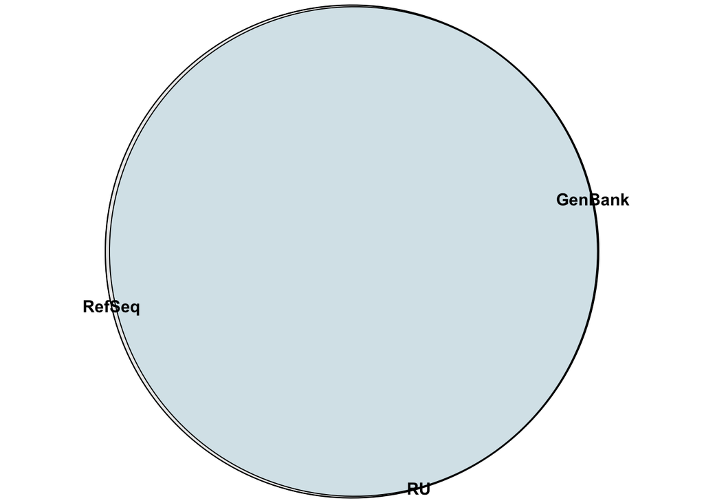

```r
busco_Combined <- read.delim("busco/busco_corr_insect/run_insecta_odb10//full_table.tsv",comment.char = "#",header=FALSE) %>%
 set_colnames(c("Busco_id","Status","Sequence","Score","Length","OrthoDB_url","Description"))
busco_Genbank <- read.delim("busco/Genbank_busco_insect/run_insecta_odb10///full_table.tsv",comment.char = "#",header=FALSE) %>%
 set_colnames(c("Busco_id","Status","Sequence","Score","Length","OrthoDB_url","Description"))
busco_RefSeq <- read.delim("busco/Refseq_busco_insect/run_insecta_odb10///full_table.tsv",comment.char = "#",header=FALSE) %>%
 set_colnames(c("Busco_id","Status","Sequence","Score","Length","OrthoDB_url","Description"))

All_busco <- busco_Combined %>% pull(Busco_id) %>% unique()

Busco_Found_Combined <- busco_Combined %>% filter(!Status %in% "Missing") %>% pull(Busco_id) %>% unique()
Busco_Found_RefSeq <- busco_RefSeq %>% filter(!Status %in% "Missing") %>% pull(Busco_id) %>% unique()
Busco_Found_Genbank <- busco_Genbank %>% filter(!Status %in% "Missing") %>% pull(Busco_id) %>% unique()

busco_table <- data.frame(row.names=All_busco)
busco_table$RU <- rownames(busco_table) %in% Busco_Found_Combined
busco_table$RefSeq <- rownames(busco_table) %in% Busco_Found_RefSeq
busco_table$GenBank <- rownames(busco_table) %in% Busco_Found_Genbank

plot(eulerr::euler(busco_table))
```

```r
RefSeqNotRU <- busco_table[busco_table$RefSeq & !busco_table$RU,] %>% rownames_to_column() %>% pull(rowname)
RUNotRefSeq <- busco_table[!busco_table$RefSeq & busco_table$RU,] %>% rownames_to_column() %>% pull(rowname)

RefSeqNotRU_RefseqIDs <- busco_RefSeq[busco_RefSeq$Busco_id %in% RefSeqNotRU,]$Sequence %>% gsub(":.*","",.) %>% unique
RUNotRefSeq_RUIDs <- busco_Combined[busco_Combined$Busco_id %in% RUNotRefSeq,]$Sequence %>% gsub(":.*","",.) %>% unique
```

## Add in Busco gene info

```r
busco_Combined$RUID <- busco_Combined$Sequence %>% gsub(":.*","",.)
busco_Combined %<>% mutate(BuscoInfo=paste("Busco_id=",Busco_id,";OrthoDB_url=",OrthoDB_url,";Description",Description,sep=""))
LongandRefseqandShort_Cleaned2_DF <- LongandRefseqandShort_Cleaned2_GTF %>% as.data.frame

busco_Combined_toMerge <- busco_Combined %>%
 select(RUID,BuscoInfo) %>%
 group_by(RUID) %>%
 summarise(BuscoInformation=paste(BuscoInfo,sep=":",collapse=":")) %>%
 ungroup() %>%
 select(RUID,BuscoInformation)

LongandRefseqandShort_Cleaned2_DF <- merge(LongandRefseqandShort_Cleaned2_DF,busco_Combined_toMerge,
   by.x="transcript_id",by.y="RUID",all.x=TRUE,all.y=FALSE)
LongandRefseqandShort_Cleaned2_GTF <- LongandRefseqandShort_Cleaned2_DF %>% GRanges()
```

## Add in source for transcripts info

```r
Combined_txdb <- makeTxDbFromGRanges(LongandRefseqandShort_Cleaned2_GTF)
Combined_exonsByTX <- exonsBy(Combined_txdb,by="tx",use.names=TRUE)


BRCDK_GTF <- readRDS("RObjects/BRCDK_NoGeneModelOverlapFull.RDS")
BRCDK_txdb <- makeTxDbFromGRanges(BRCDK_GTF)
BRCDK_exonsByTX <- exonsBy(BRCDK_txdb,by="tx",use.names=TRUE)


Long_txdb <- makeTxDbFromGRanges(LongStringtie_GTF2)
Long_exonsByTX <- exonsBy(Long_txdb,by="tx",use.names=TRUE)

Short_GTF <- import("Illumina/StringTie_NoGTF/stringtie/stringtie/merged_stringtie.gtf")
Short_GTF <- Short_GTF[strand(Short_GTF) != "*"]
Short_txdb <- makeTxDbFromGRanges(Short_GTF)
Short_exonsByTX <- exonsBy(Short_txdb,by="tx",use.names=TRUE)

tempa <- findOverlaps(Combined_exonsByTX,Combined_exonsByTX,type = "equal")

temp1 <- findOverlaps(Combined_exonsByTX,BRCDK_exonsByTX,type = "equal")
temp2 <- findOverlaps(Combined_exonsByTX,Long_exonsByTX,type = "equal")
temp3 <- findOverlaps(Combined_exonsByTX,Short_exonsByTX,type = "equal")

RefSeq_source <- names(Combined_exonsByTX)[temp1@from] %>% unique
PacBio_source <- names(Combined_exonsByTX)[temp2@from] %>% unique
Illumina_source <- names(Combined_exonsByTX)[temp3@from] %>% unique

source_Refseq <- LongandRefseqandShort_Cleaned2_GTF$source
source_PacBio <- LongandRefseqandShort_Cleaned2_GTF$source
source_Illumina <- LongandRefseqandShort_Cleaned2_GTF$source

source_Refseq[LongandRefseqandShort_Cleaned2_GTF$transcript_id %in% RefSeq_source] <- "RefSeq"
source_PacBio[LongandRefseqandShort_Cleaned2_GTF$transcript_id %in% PacBio_source] <- "PacBio_StringTie2"
source_Illumina[LongandRefseqandShort_Cleaned2_GTF$transcript_id %in% Illumina_source] <- "Illumina_StringTie2"
source <- paste(source_Refseq,source_PacBio,source_Illumina,sep=",") %>% gsub(",,",",",.) %>% gsub("^,|,$","",.)
source[source==""] <- "PacBio_StringTie2"
LongandRefseqandShort_Cleaned2_GTF$source <- source
```

## Add in Squanti filtering info

```r
tempF <- read.delim("Squanti/squanti3_filter_combined_vs_refseq//combine_vs_refseq.gtf_RulesFilter_result_classification.txt")
tempF %<>% as.data.frame %>% select(isoform,
                  structural_category,
                  subcategory,
                  RTS_stage,
                  all_canonical,
                  FSM_class,
                  coding,
                  predicted_NMD,
                  perc_A_downstream_TTS,
                  filter_result)
LongandRefseqandShort_Cleaned2_DF <- LongandRefseqandShort_Cleaned2_GTF %>% as.data.frame()
LongandRefseqandShort_Cleaned2_GTF <- merge(LongandRefseqandShort_Cleaned2_DF,
   tempF,by.x="transcript_id",by.y="isoform",all.x=TRUE,all.y=FALSE) %>% GRanges()

export(LongandRefseqandShort_Cleaned2_GTF,con = "LongandRefseqandShort_Cleaned2_GTF.gtf")

LongandRefseqandShort_Cleaned2_DF <- LongandRefseqandShort_Cleaned2_GTF %>% as.data.frame()
LongandRefseqandShort_Cleaned2_DF %>%
 select(seqnames,start,end,width,strand,transcript_id,gene_id,source,type,score,phase) %>% GRanges() %>%
 export(con = "LongandRefseqandShort_Cleaned2_GTF_simple.gtf")
```

```r
Herper::with_CondaEnv("transdecoder",{

 fasta <- "/rugpfs/fs0/brc/scratch/brc_pipeline/analysis/kip_redo/BRCDK_Reference_noGTF/workflow_data/extdata/GenBank.fa.gz"
 output_dir <- "/rugpfs/fs0/brc/scratch/brc_pipeline/analysis/kip_redo/cleanedGTF2/"
 gtf <- "/rugpfs/fs0/brc/scratch/brc_pipeline/analysis/kip_redo/cleanedGTF/LongandRefseqandShort_Cleaned2_GTF_simple.gtf"
 transdecode_File <- "Transdecode_LongandRefseqandShort_Cleaned2_GTF.gtf"
 transcode_output <- file.path(output_dir,"transdecode")
 unzippedFasta <- file.path(output_dir,gsub("\\.gz","",basename(fasta)))
 transfasta <- file.path(output_dir,"transcripts.fasta")
 gffTemp <- file.path(output_dir,gsub("\\.gtf",".gff",basename(gtf)))
 R.utils::gunzip(fasta,unzippedFasta,remove=FALSE)

 cmd <- "gtf_genome_to_cdna_fasta.pl"
 args <- paste(gtf,unzippedFasta,">",transfasta)
 system(paste(cmd,args))

 cmd <- "gtf_to_alignment_gff3.pl"
 args <- paste(gtf,">",gffTemp)
 system(paste(cmd,args))

 system(paste("TransDecoder.LongOrfs -m 75 --output_dir",transcode_output,"-t",
        transfasta))

 system(paste("TransDecoder.Predict --single_best_only --output_dir",transcode_output,"-t",
        transfasta))
 system(paste("cdna_alignment_orf_to_genome_orf.pl",
        paste0(file.path(transcode_output,basename(transfasta)),".transdecoder.gff3"),
        gffTemp,transfasta,">",paste0(file.path(transcode_output,basename(transfasta)),".transdecoder.genome.gff3")))

 system(paste("gffread -E -T",file.path(transcode_output,
                     paste0(
                      basename(transfasta),
                      ".transdecoder.genome.gff3")),
        ">",
        file.path(output_dir,
             transdecode_File)),
 )
 R.utils::gzip(file.path(output_dir,
             transdecode_File),
        paste0(
         file.path(output_dir,
              transdecode_File),
         ".gz"),
        remove=FALSE)
 },
 pathToMiniConda = "/ru-auth/local/home/brc_pipeline/brc_conda/")
```

## Add rRNA annotations from Refseq

```r
RefSeq_GTF <- import("Originals/Refseq/Obiroi_RefSeq__5_4_renamed.gtf.gz")
RefSeq_txdb <- makeTxDbFromGRanges(RefSeq_GTF)
RefSeq_tx <- exonsBy(RefSeq_txdb,by = "tx",use.names=TRUE)
RefSeq_RNAs <- RefSeq_GTF[RefSeq_GTF$transcript_biotype %in%"rRNA"]$transcript_id %>% unique
RefSeq_RNA_tx <- RefSeq_tx[RefSeq_RNAs]

Comb_txdb <- makeTxDbFromGRanges(LongandRefseqandShort_Cleaned2_GTF)
Comb_tx <- exonsBy(Comb_txdb,by = "tx",use.names=TRUE)

hits_rRNA <- findOverlaps(Comb_tx,RefSeq_RNA_tx,type = "equal")
rRNAgenes <- names(Comb_tx)[hits_rRNA@from]
rRNAfound <- names(RefSeq_RNA_tx)[hits_rRNA@to]

hits_rRNA2 <- findOverlaps(Comb_tx,RefSeq_RNA_tx)
rRNAfound2 <- names(RefSeq_RNA_tx)[hits_rRNA2@to] %>% unique
OverlappingRNA <- rRNAfound2[!rRNAfound2 %in% rRNAfound]

rRNA_to_add <- RefSeq_RNAs[!RefSeq_RNAs %in% rRNAfound2]


rRNAs_to_Label <- rRNAgenes
rRNA_to_add_GR <- RefSeq_GTF[RefSeq_GTF$transcript_id %in% rRNA_to_add]
mcols(rRNA_to_add_GR) <- mcols(rRNA_to_add_GR) %>% as.data.frame %>% select(source,type,score,phase)
```

## Add tRNA annotations from Refseq

```r
RefSeq_GTF <- import("Originals/Refseq/Obiroi_RefSeq__5_4_renamed.gtf.gz")
RefSeq_txdb <- makeTxDbFromGRanges(RefSeq_GTF)
RefSeq_tx <- exonsBy(RefSeq_txdb,by = "tx",use.names=TRUE)
RefSeq_tRNAs <- RefSeq_GTF[RefSeq_GTF$transcript_biotype %in%"tRNA"]$transcript_id %>% unique
RefSeq_tRNA_tx <- RefSeq_tx[RefSeq_tRNAs]

Comb_txdb <- makeTxDbFromGRanges(LongandRefseqandShort_Cleaned2_GTF)
Comb_tx <- exonsBy(Comb_txdb,by = "tx",use.names=TRUE)

hits_tRNA <- findOverlaps(Comb_tx,RefSeq_tRNA_tx,type = "equal")
tRNAgenes <- names(Comb_tx)[hits_tRNA@from]
tRNAfound <- names(RefSeq_tRNA_tx)[hits_tRNA@to]

hits_tRNA2 <- findOverlaps(Comb_tx,RefSeq_tRNA_tx)
tRNAfound2 <- names(RefSeq_tRNA_tx)[hits_tRNA2@to] %>% unique
OverlappingtRNA <- tRNAfound2[!tRNAfound2 %in% tRNAfound]

tRNA_to_add <- RefSeq_tRNAs[!RefSeq_tRNAs %in% tRNAfound2]


tRNAs_to_Label <- tRNAgenes
tRNA_to_add_GR <- RefSeq_GTF[RefSeq_GTF$transcript_id %in% tRNA_to_add]
mcols(tRNA_to_add_GR) <- mcols(tRNA_to_add_GR) %>% as.data.frame %>% select(source,type,score,phase)
```

## Add snoRNA annotations from Refseq

```r
RefSeq_GTF <- import("Originals/Refseq/Obiroi_RefSeq__5_4_renamed.gtf.gz")
RefSeq_txdb <- makeTxDbFromGRanges(RefSeq_GTF)
RefSeq_tx <- exonsBy(RefSeq_txdb,by = "tx",use.names=TRUE)
RefSeq_snoRNAs <- RefSeq_GTF[RefSeq_GTF$transcript_biotype %in%"snoRNA"]$transcript_id %>% unique
RefSeq_snoRNA_tx <- RefSeq_tx[RefSeq_snoRNAs]

Comb_txdb <- makeTxDbFromGRanges(LongandRefseqandShort_Cleaned2_GTF)
Comb_tx <- exonsBy(Comb_txdb,by = "tx",use.names=TRUE)

hits_snoRNA <- findOverlaps(Comb_tx,RefSeq_snoRNA_tx,type = "equal")
snoRNAgenes <- names(Comb_tx)[hits_snoRNA@from]
snoRNAfound <- names(RefSeq_snoRNA_tx)[hits_snoRNA@to]

hits_snoRNA2 <- findOverlaps(Comb_tx,RefSeq_snoRNA_tx)
snoRNAfound2 <- names(RefSeq_snoRNA_tx)[hits_snoRNA2@to] %>% unique
OverlappingsnoRNA <- snoRNAfound2[!snoRNAfound2 %in% snoRNAfound]

snoRNA_to_add <- RefSeq_snoRNAs[!RefSeq_snoRNAs %in% snoRNAfound2]


snoRNAs_to_Label <- snoRNAgenes
snoRNA_to_add_GR <- RefSeq_GTF[RefSeq_GTF$transcript_id %in% snoRNA_to_add]
mcols(snoRNA_to_add_GR) <- mcols(snoRNA_to_add_GR) %>% as.data.frame %>% select(source,type,score,phase)
```

## Add snRNA annotations from Refseq

```r
RefSeq_GTF <- import("Originals/Refseq/Obiroi_RefSeq__5_4_renamed.gtf.gz")
RefSeq_txdb <- makeTxDbFromGRanges(RefSeq_GTF)
RefSeq_tx <- exonsBy(RefSeq_txdb,by = "tx",use.names=TRUE)
RefSeq_snRNAs <- RefSeq_GTF[RefSeq_GTF$transcript_biotype %in%"snRNA"]$transcript_id %>% unique
RefSeq_snRNA_tx <- RefSeq_tx[RefSeq_snRNAs]

Comb_txdb <- makeTxDbFromGRanges(LongandRefseqandShort_Cleaned2_GTF)
Comb_tx <- exonsBy(Comb_txdb,by = "tx",use.names=TRUE)

hits_snRNA <- findOverlaps(Comb_tx,RefSeq_snRNA_tx,type = "equal")
snRNAgenes <- names(Comb_tx)[hits_snRNA@from]
snRNAfound <- names(RefSeq_snRNA_tx)[hits_snRNA@to]

hits_snRNA2 <- findOverlaps(Comb_tx,RefSeq_snRNA_tx)
snRNAfound2 <- names(RefSeq_snRNA_tx)[hits_snRNA2@to] %>% unique
OverlappingsnRNA <- snRNAfound2[!snRNAfound2 %in% snRNAfound]

snRNA_to_add <- RefSeq_snRNAs[!RefSeq_snRNAs %in% snRNAfound2]


snRNAs_to_Label <- snRNAgenes
snRNA_to_add_GR <- RefSeq_GTF[RefSeq_GTF$transcript_id %in% snRNA_to_add]
mcols(snRNA_to_add_GR) <- mcols(snRNA_to_add_GR) %>% as.data.frame %>% select(source,type,score,phase)
```

## Add piRNA annotations from pilfer

```r
piRNAbed <- import.bed("piRNAs/piRNAs_pilfer.bed")
piRNAbed <- renameSeqlevels(piRNAbed,
               chr_map %>% pull(assembly,name = "X..refseq"))
export(piRNAbed,"piRNAs/piRNAs_pilfer_renamed.bed")

piRNAbed <- GenomicRanges::reduce(piRNAbed)
export(piRNAbed,"piRNAs/piRNAs_pilfer_renamed_reduced.bed")


Comb_txdb <- makeTxDbFromGRanges(LongandRefseqandShort_Cleaned2_GTF)
Comb_tx <- exonsBy(Comb_txdb,by = "tx",use.names=TRUE)

hits_piRNA <- findOverlaps(Comb_tx,piRNAbed)
```

```r
LongandRefseqandShort_Cleaned2_DF <- LongandRefseqandShort_Cleaned2_GTF %>%
 as.data.frame()
LongandRefseqandShort_Cleaned2_DF$transcript_type <- NA
LongandRefseqandShort_Cleaned2_DF[LongandRefseqandShort_Cleaned2_DF$type == "transcript",]$transcript_type <- "mRNA"

LongandRefseqandShort_Cleaned2_DF[LongandRefseqandShort_Cleaned2_DF$type == "transcript" & LongandRefseqandShort_Cleaned2_DF$transcript_id %in% rRNAs_to_Label,]$transcript_type <- "rRNA"

LongandRefseqandShort_Cleaned2_DF[LongandRefseqandShort_Cleaned2_DF$type == "transcript" & LongandRefseqandShort_Cleaned2_DF$transcript_id %in% tRNAs_to_Label,]$transcript_type <- "tRNA"

LongandRefseqandShort_Cleaned2_DF[LongandRefseqandShort_Cleaned2_DF$type == "transcript" & LongandRefseqandShort_Cleaned2_DF$transcript_id %in% snoRNAs_to_Label,]$transcript_type <- "snoRNA"

LongandRefseqandShort_Cleaned2_DF[LongandRefseqandShort_Cleaned2_DF$type == "transcript" & LongandRefseqandShort_Cleaned2_DF$transcript_id %in% snRNAs_to_Label,]$transcript_type <- "snRNA"

LongandRefseqandShort_Cleaned2_GTF <- LongandRefseqandShort_Cleaned2_DF %>% GRanges()

rRNA_to_add_df <- rRNA_to_add_GR %>% as.data.frame() %>% mutate(source="RefSeq",Refseq_gene_id=NA,Ens_gene_id=NA,Genbank_gene_id=NA,Refseq_transcript_id=NA,
                       Ens_transcript_id=NA,Genbank_transcript_id=NA,BuscoInformation=NA,
                       structural_category=NA,subcategory=NA,
                    RTS_stage=NA,all_canonical=NA,FSM_class=NA,coding=NA,
                    predicted_NMD=NA,perc_A_downstream_TTS=NA,
                       filter_result="Isoform",transcript_type="rRNA")

maxID <- LongandRefseqandShort_Cleaned2_GTF$gene_id %>% gsub("RU\\.","",.) %>% as.numeric() %>% max
rRNA_to_add_df$gene_id <- NA
rRNA_to_add_df$transcript_id <- NA
rRNA_to_add_df[rRNA_to_add_df$type == "transcript",]$gene_id <- paste0("RU.",seq(maxID+1,maxID+nrow(rRNA_to_add_df[rRNA_to_add_df$type %in% "transcript",])))
rRNA_to_add_df[rRNA_to_add_df$type == "exon",]$gene_id <- paste0("RU.",seq(maxID+1,maxID+nrow(rRNA_to_add_df[rRNA_to_add_df$type %in% "exon",])))
rRNA_to_add_df[rRNA_to_add_df$type == "transcript",]$transcript_id <- paste0(rRNA_to_add_df[rRNA_to_add_df$type == "transcript",]$gene_id,".1")
rRNA_to_add_df[rRNA_to_add_df$type == "exon",]$transcript_id <- paste0(rRNA_to_add_df[rRNA_to_add_df$type == "exon",]$gene_id,".1")
rRNA_to_add_GR <- rRNA_to_add_df %>% GRanges()
LongandRefseqandShort_Cleaned2_GTF <- c(LongandRefseqandShort_Cleaned2_GTF,rRNA_to_add_GR) %>% sort
```

```r
LongandRefseq_txdb <- makeTxDbFromGRanges(LongandRefseqandShort_Cleaned2_GTF)
LongandRefseq_exonsByGene <- exonsBy(LongandRefseq_txdb,by = "gene")
selfOverlaps <- findOverlaps(LongandRefseq_exonsByGene,LongandRefseq_exonsByGene)
temp_selfOverlaps <- as.data.frame(selfOverlaps)

temp_selfOverlaps$queryHitsNames <- names(LongandRefseq_exonsByGene)[temp_selfOverlaps$queryHits]
temp_selfOverlaps$subjectHitsNames <- names(LongandRefseq_exonsByGene)[temp_selfOverlaps$subjectHits]


temp_selfOverlaps <- temp_selfOverlaps[temp_selfOverlaps$queryHits != temp_selfOverlaps$subjectHits,]
```

```r
transTemp <- import("transdecoder/Transdecode_75bpORF_LongandRefseqandShort_Cleaned2_GTF.gtf")
transTemp$transcript_id <- transTemp$transcript_id %>%
 gsub("\\.p.*","",.)
transTemp$gene_id <- transTemp$gene_id %>%
 gsub("\\^.*","",.)
transTempStrandSummary <- transTemp %>% as.data.frame() %>%
 select(transcript_id,strand) %>%
 group_by(transcript_id) %>% summarise(Strand=unique(strand))

LRStradSummary <- LongandRefseqandShort_Cleaned2_GTF %>% as.data.frame %>% filter(!is.na(transcript_id)) %>%
 select(transcript_id,strand) %>%
 group_by(transcript_id) %>% summarise(Strand=unique(strand))

compareStrand <- merge(transTempStrandSummary,LRStradSummary,by=1,all=FALSE)
noCodingOnCorrectSrand <- compareStrand[compareStrand$Strand.x != compareStrand$Strand.y,"transcript_id"]

transTemp <- transTemp[!transTemp$transcript_id %in% noCodingOnCorrectSrand]
transTemp_CDS <- transTemp[transTemp$type == "CDS"]
LongandRefseqandShort_Cleaned3_GTF <- c(LongandRefseqandShort_Cleaned2_GTF,transTemp_CDS) %>% sort


allTranscripts <- LongandRefseqandShort_Cleaned3_GTF[LongandRefseqandShort_Cleaned3_GTF$transcript_type %in% "mRNA",]$transcript_id %>% unique
codingTranscripts <- LongandRefseqandShort_Cleaned3_GTF[LongandRefseqandShort_Cleaned3_GTF$type == "CDS" & LongandRefseqandShort_Cleaned3_GTF$type == "CDS",]$transcript_id %>% unique
lncRNAs <- allTranscripts[!allTranscripts %in% codingTranscripts] %>% unique
LongandRefseqandShort_Cleaned3_GTF[LongandRefseqandShort_Cleaned3_GTF$transcript_id %in% lncRNAs & LongandRefseqandShort_Cleaned3_GTF$type == "transcript",]$transcript_type <- "lncRNA"
# makeTxDbFromGRanges(LongandRefseqandShort_Cleaned3_GTF)
```

```r
LongandRefseqandShort_Cleaned3_GTF[LongandRefseqandShort_Cleaned3_GTF$coding %in% "non_coding" & LongandRefseqandShort_Cleaned3_GTF$type == "transcript"]$transcript_type %>% table %>% as.data.frame %>% DT::datatable()

LongandRefseqandShort_Cleaned3_GTF[LongandRefseqandShort_Cleaned3_GTF$coding %in% "coding" & LongandRefseqandShort_Cleaned3_GTF$type == "transcript"]$transcript_type %>% table %>% as.data.frame %>% DT::datatable()

LongandRefseqandShort_Cleaned3_GTF[LongandRefseqandShort_Cleaned3_GTF$transcript_type %in% "lncRNA" & LongandRefseqandShort_Cleaned3_GTF$type == "transcript"]$coding %>% table %>% as.data.frame %>% DT::datatable()

LongandRefseqandShort_Cleaned3_GTF[LongandRefseqandShort_Cleaned3_GTF$transcript_type %in% "mRNA" & LongandRefseqandShort_Cleaned3_GTF$type == "transcript"]$coding %>% table %>% as.data.frame %>% DT::datatable()
```

```r
codingInSquanti <- LongandRefseqandShort_Cleaned3_GTF[LongandRefseqandShort_Cleaned3_GTF$transcript_type %in% "lncRNA" & LongandRefseqandShort_Cleaned3_GTF$type == "transcript" & LongandRefseqandShort_Cleaned3_GTF$coding == "coding"]$transcript_id
squanti_cds <- import("Squanti/squanti3_combined_vs_refseq/combine_vs_refseq.gtf_corrected.gtf.cds.gff")
squanti_justcds <- squanti_cds[squanti_cds$transcript_id %in% codingInSquanti & squanti_cds$type == "CDS",]

squanti_justcds$gene_id <- gsub("\\.\\d+$","",squanti_justcds$transcript_id)

LongandRefseqandShort_Cleaned4_GTF <- c(LongandRefseqandShort_Cleaned3_GTF,squanti_justcds) %>% sort

LongandRefseqandShort_Cleaned4_GTF[LongandRefseqandShort_Cleaned4_GTF$transcript_id %in% codingInSquanti & LongandRefseqandShort_Cleaned4_GTF$type == "transcript"]$transcript_type <- "mRNA"
```

```r
LongandRefseqandShort_Cleaned4_GTF[LongandRefseqandShort_Cleaned4_GTF$transcript_type %in% "lncRNA" & LongandRefseqandShort_Cleaned4_GTF$type == "transcript"]$coding %>% table %>% as.data.frame %>% DT::datatable()
```

```r
LongandRefseq_txdb <- makeTxDbFromGRanges(LongandRefseqandShort_Cleaned4_GTF)
LongandRefseq_exonsByGene <- exonsBy(LongandRefseq_txdb,by = "gene")
selfOverlaps <- findOverlaps(LongandRefseq_exonsByGene,LongandRefseq_exonsByGene)
temp_selfOverlaps <- as.data.frame(selfOverlaps)

temp_selfOverlaps$queryHitsNames <- names(LongandRefseq_exonsByGene)[temp_selfOverlaps$queryHits]
temp_selfOverlaps$subjectHitsNames <- names(LongandRefseq_exonsByGene)[temp_selfOverlaps$subjectHits]


temp_selfOverlaps <- temp_selfOverlaps[temp_selfOverlaps$queryHits != temp_selfOverlaps$subjectHits,]
```

```r
LongandRefseqandShort_Cleaned4_DF <- LongandRefseqandShort_Cleaned4_GTF %>% as.data.frame()
LongandRefseqandShort_Cleaned4_DF_exon <- LongandRefseqandShort_Cleaned4_DF[LongandRefseqandShort_Cleaned4_DF$type == "exon",]
LongandRefseqandShort_Cleaned4_DF_cds <- LongandRefseqandShort_Cleaned4_DF[LongandRefseqandShort_Cleaned4_DF$type == "CDS",]
LongandRefseqandShort_Cleaned4_DF_exon <- LongandRefseqandShort_Cleaned4_DF_exon %>% select(seqnames,start,end,width,strand,transcript_id,gene_id,type,score,phase)
LongandRefseqandShort_Cleaned4_DF_cds <- LongandRefseqandShort_Cleaned4_DF_cds %>% select(seqnames,start,end,width,strand,transcript_id,gene_id,source,type,score,phase)
#LongandRefseqandShort_Cleaned4_DF_cds$source %>% is.na %>% table
#LongandRefseqandShort_Cleaned4_DF_cds$source %>% table
LongandRefseqandShort_Cleaned4_DF_cds$source  <- ifelse(LongandRefseqandShort_Cleaned4_DF_cds$source == "PacBio","GeneMark","transdecoder")

LongandRefseqandShort_Cleaned4_DF_transcript <- LongandRefseqandShort_Cleaned4_DF[LongandRefseqandShort_Cleaned4_DF$type == "transcript",]
# LongandRefseqandShort_Cleaned4_DF_transcript$transcript_id %>% is.na %>% table
# LongandRefseqandShort_Cleaned4_DF_transcript$gene_id %>% is.na %>% table
# LongandRefseqandShort_Cleaned4_DF_transcript$source  %>% is.na %>% table
# LongandRefseqandShort_Cleaned4_DF_transcript$source  %>% table

source <- LongandRefseqandShort_Cleaned4_DF_transcript$source %>% as.character()
source[grepl("RefSeq",LongandRefseqandShort_Cleaned4_DF_transcript$source) & is.na(LongandRefseqandShort_Cleaned4_DF_transcript$Refseq_gene_id)] <- gsub("RefSeq","GenBank",LongandRefseqandShort_Cleaned4_DF_transcript[grepl("RefSeq",LongandRefseqandShort_Cleaned4_DF_transcript$source) & is.na(LongandRefseqandShort_Cleaned4_DF_transcript$Refseq_gene_id),]$source)
 LongandRefseqandShort_Cleaned4_DF_transcript$source <- factor(source)

LongandRefseqandShort_Cleaned4_DF_transcript[LongandRefseqandShort_Cleaned4_DF_transcript$seqnames == "MT",]$transcript_type <- "mRNA"

LongandRefseqandShort_Cleaned4_GTF <- c(LongandRefseqandShort_Cleaned4_DF_transcript %>% GRanges(),
LongandRefseqandShort_Cleaned4_DF_cds %>% GRanges(),
LongandRefseqandShort_Cleaned4_DF_exon %>% GRanges()) %>% sort
```

```r
LongandRefseq_txdb <- makeTxDbFromGRanges(LongandRefseqandShort_Cleaned4_GTF)
LongandRefseq_exonsByGene <- exonsBy(LongandRefseq_txdb,by = "gene")
selfOverlaps <- findOverlaps(LongandRefseq_exonsByGene,LongandRefseq_exonsByGene)
temp_selfOverlaps <- as.data.frame(selfOverlaps)

temp_selfOverlaps$queryHitsNames <- names(LongandRefseq_exonsByGene)[temp_selfOverlaps$queryHits]
temp_selfOverlaps$subjectHitsNames <- names(LongandRefseq_exonsByGene)[temp_selfOverlaps$subjectHits]


temp_selfOverlaps <- temp_selfOverlaps[temp_selfOverlaps$queryHits != temp_selfOverlaps$subjectHits,]
```

```r
names(LongandRefseqandShort_Cleaned4_GTF) <- NULL
# LongandRefseqandShort_Cleaned4_GTF

chr_map <- read.delim("Originals/UCSC_Map/GCF_003672135.1.chromAlias.txt")

LongandRefseqandShort_Cleaned4_GTF_1 <- LongandRefseqandShort_Cleaned4_GTF[!grepl("NW_|QO",seqnames(LongandRefseqandShort_Cleaned4_GTF))]

LongandRefseqandShort_Cleaned4_GTF_2 <- LongandRefseqandShort_Cleaned4_GTF[grepl("NW_",seqnames(LongandRefseqandShort_Cleaned4_GTF))]
LongandRefseqandShort_Cleaned4_GTF_2 <- renameSeqlevels(LongandRefseqandShort_Cleaned4_GTF_2,
               chr_map %>% pull(assembly,name = "X..refseq"))

LongandRefseqandShort_Cleaned4_GTF_3 <- LongandRefseqandShort_Cleaned4_GTF[grepl("QO",seqnames(LongandRefseqandShort_Cleaned4_GTF))]

LongandRefseqandShort_Cleaned4_GTF_3 <- renameSeqlevels(LongandRefseqandShort_Cleaned4_GTF_3,
               chr_map %>% pull(assembly,name = "genbank"))

LongandRefseqandShort_Cleaned4_GTF_4 <- c(LongandRefseqandShort_Cleaned4_GTF_1,LongandRefseqandShort_Cleaned4_GTF_2,LongandRefseqandShort_Cleaned4_GTF_3)


LongandRefseq_txdb <- makeTxDbFromGRanges(LongandRefseqandShort_Cleaned4_GTF_4)
LongandRefseq_exonsByGene <- exonsBy(LongandRefseq_txdb,by = "gene")
selfOverlaps <- findOverlaps(LongandRefseq_exonsByGene,LongandRefseq_exonsByGene)
temp_selfOverlaps <- as.data.frame(selfOverlaps)

temp_selfOverlaps$queryHitsNames <- names(LongandRefseq_exonsByGene)[temp_selfOverlaps$queryHits]
temp_selfOverlaps$subjectHitsNames <- names(LongandRefseq_exonsByGene)[temp_selfOverlaps$subjectHits]


temp_selfOverlaps <- temp_selfOverlaps[temp_selfOverlaps$queryHits != temp_selfOverlaps$subjectHits,]

LongandRefseqandShort_Cleaned4_GTF_4 <- LongandRefseqandShort_Cleaned4_GTF_4[!LongandRefseqandShort_Cleaned4_GTF_4$gene_id %in% c("RU.15009"),]

LongandRefseq_txdb <- makeTxDbFromGRanges(LongandRefseqandShort_Cleaned4_GTF_4)
LongandRefseq_exonsByGene <- exonsBy(LongandRefseq_txdb,by = "gene")
selfOverlaps <- findOverlaps(LongandRefseq_exonsByGene,LongandRefseq_exonsByGene)
temp_selfOverlaps <- as.data.frame(selfOverlaps)

temp_selfOverlaps$queryHitsNames <- names(LongandRefseq_exonsByGene)[temp_selfOverlaps$queryHits]
temp_selfOverlaps$subjectHitsNames <- names(LongandRefseq_exonsByGene)[temp_selfOverlaps$subjectHits]


temp_selfOverlaps <- temp_selfOverlaps[temp_selfOverlaps$queryHits != temp_selfOverlaps$subjectHits,]

LongandRefseqandShort_Cleaned4_GTF <- LongandRefseqandShort_Cleaned4_GTF_4
# export(LongandRefseqandShort_Cleaned4_GTF,con = "LongandRefseqandShort_Cleaned4_GTF.gtf")
```

```r
filesToParse <- dir("mirdeep/",pattern="*.csv",full.names=TRUE)
temp <- list()
for(i in 1:length(filesToParse)){
 tempa <- read.delim(filesToParse[i],skip = 26,sep="\t",header = TRUE)
 tempB <- tempa$precursor.coordinate %>% GRanges()
 tempB$miRNA_ID <- paste0(ifelse(tempa$example.miRBase.miRNA.with.the.same.seed == "-","Novel",tempa$example.miRBase.miRNA.with.the.same.seed),
              ":",tempa$consensus.mature.sequence,":",tempa$consensus.precursor.sequence)
 names(tempB) <- tempB$miRNA_ID
 temp[[i]] <- tempB
}
temp <- GRangesList(temp) %>% unlist
temp2 <- GenomicRanges::reduce(temp,with.revmap=T)
mirnaname <- list()
for(i in 1:length(temp2$revmap)){
 mirnaname[[i]] <- paste(unique(temp$miRNA_ID[temp2$revmap[[i]]]),collapse=";")
}
temp2$miRNA_ID <- unlist(mirnaname)
miRNA_to_add_GR <- temp2 %>% as.data.frame() %>% select(-revmap) %>% GRanges
miRNA_to_add_GR <- renameSeqlevels(miRNA_to_add_GR,
               chr_map %>% pull(assembly,name = "X..refseq"))

miRNA_to_add_df <- miRNA_to_add_GR %>% as.data.frame() %>% mutate(source="mirdeep2",Refseq_gene_id=NA,Ens_gene_id=NA,Genbank_gene_id=NA,Refseq_transcript_id=NA,
                       Ens_transcript_id=NA,Genbank_transcript_id=NA,BuscoInformation=NA,
                       structural_category=NA,subcategory=NA,
                    RTS_stage=NA,all_canonical=NA,FSM_class=NA,coding=NA,
                    predicted_NMD=NA,perc_A_downstream_TTS=NA,
                       filter_result="Isoform",transcript_type="miRNA")

maxID <- LongandRefseqandShort_Cleaned4_GTF$gene_id %>% gsub("RU\\.","",.) %>% as.numeric() %>% max
miRNA_to_add_df$gene_id <- NA
miRNA_to_add_df$transcript_id <- NA
miRNA_to_add_df$gene_id <- paste0("RU.",seq(maxID+1,maxID+nrow(miRNA_to_add_df)))
miRNA_to_add_df$transcript_id <- paste0(miRNA_to_add_df$gene_id,".1")
miRNA_to_add_df_trans <- miRNA_to_add_df
miRNA_to_add_df_exon <- miRNA_to_add_df
miRNA_to_add_df_exon$type <- "exon"
miRNA_to_add_df_trans$type <- "transcript"
# miRNA_to_add_df_exon$transcript_id <- NA
miRNA_to_add_df_exon$filter_result <- NA
miRNA_to_add_GR <- rbind(miRNA_to_add_df_exon,miRNA_to_add_df_trans) %>% GRanges()
LongandRefseqandShort_Cleaned5_GTF <- c(LongandRefseqandShort_Cleaned4_GTF,miRNA_to_add_GR) %>% sort

# findOverlaps(LongandRefseq_exonsByGene,miRNA_to_add_GR)
```

```r
piRNA_to_add_df <- piRNAbed %>% as.data.frame() %>% mutate(source="Pilfer",Refseq_gene_id=NA,Ens_gene_id=NA,Genbank_gene_id=NA,Refseq_transcript_id=NA,
                       Ens_transcript_id=NA,Genbank_transcript_id=NA,BuscoInformation=NA,
                       structural_category=NA,subcategory=NA,
                    RTS_stage=NA,all_canonical=NA,FSM_class=NA,coding=NA,
                    predicted_NMD=NA,perc_A_downstream_TTS=NA,
                       filter_result="Isoform",transcript_type="piRNA")

maxID <- LongandRefseqandShort_Cleaned5_GTF$gene_id %>% gsub("RU\\.","",.) %>% as.numeric() %>% max
piRNA_to_add_df$gene_id <- NA
piRNA_to_add_df$transcript_id <- NA
piRNA_to_add_df$gene_id <- paste0("RU.",seq(maxID+1,maxID+nrow(piRNA_to_add_df)))
piRNA_to_add_df$transcript_id <- paste0(piRNA_to_add_df$gene_id,".1")
piRNA_to_add_df_trans <- piRNA_to_add_df
piRNA_to_add_df_exon <- piRNA_to_add_df
piRNA_to_add_df_exon$type <- "exon"
piRNA_to_add_df_trans$type <- "transcript"
# piRNA_to_add_df_exon$transcript_id <- NA
piRNA_to_add_df_exon$filter_result <- NA
piRNA_to_add_GR <- rbind(piRNA_to_add_df_exon,piRNA_to_add_df_trans) %>% GRanges()
LongandRefseqandShort_Cleaned6_GTF <- c(LongandRefseqandShort_Cleaned5_GTF,piRNA_to_add_GR) %>% sort
```

```r
Combined_all <- LongandRefseqandShort_Cleaned6_GTF
piRNAs <- Combined_all[Combined_all$type == "transcript" & Combined_all$transcript_type == "piRNA"]$transcript_id
sq_filter <- Combined_all[Combined_all$type == "transcript" &
                            Combined_all$transcript_type %in% c("mRNA","lncRNA") &
                            Combined_all$source == "PacBio_StringTie2" &
                            is.na(Combined_all$BuscoInformation)]$transcript_id

sqSum <- Combined_all %>%
  as.data.frame %>%
  select(structural_category,subcategory,RTS_stage,all_canonical,FSM_class,coding,predicted_NMD,perc_A_downstream_TTS,filter_result) %>%
  apply(1,paste,sep=";",collapse=";")

Combined_all2 <- Combined_all %>% as.data.frame %>%
  select(-structural_category,-subcategory,-RTS_stage,-all_canonical,-FSM_class,-coding,-predicted_NMD,-perc_A_downstream_TTS,-filter_result)
Combined_all2$SQinfo <- sqSum
Combined_all2 %<>% GRanges()

Combined_all_no_pirna <- Combined_all2[!Combined_all2$transcript_id %in% piRNAs]
Combined_all_no_pirna_filtered <- Combined_all2[!Combined_all2$transcript_id %in% piRNAs &
                                         !Combined_all2$transcript_id %in% sq_filter]

export(Combined_all2,
       con = "Combined.gtf")
export(Combined_all_no_pirna,
       con = "Combined_noPiRNA.gtf")
export(Combined_all_no_pirna_filtered,
       con = "Combined_noPiRNA_filtered.gtf")
```

# QC final gene models with gffcompare, squanti3 and Busco

### Create output for BUSCO assessment

```r
genomeSeq <- readDNAStringSet(filepath = "Genome/GenBank.fa")
Combined_all_no_pirna2 <- Combined_all_no_pirna[seqnames(Combined_all_no_pirna) %in% names(genomeSeq),]
Combined_txdb <- makeTxDbFromGRanges(Combined_all_no_pirna2)
Combined_exonsBytranscript <- exonsBy(Combined_txdb,by="tx",use.names=TRUE)
Combined_transSeq <- GenomicFeatures::extractTranscriptSeqs(FaFile("Genome/GenBank.fa"),Combined_exonsBytranscript)
writeXStringSet(Combined_transSeq,"Combined_all_noPiRNA_transSeq.fa")

genomeSeq <- readDNAStringSet(filepath = "Genome/GenBank.fa")
Combined_all_no_pirna_filtered22 <- Combined_all_no_pirna_filtered[seqnames(Combined_all_no_pirna_filtered) %in% names(genomeSeq),]
Combined_txdb <- makeTxDbFromGRanges(Combined_all_no_pirna_filtered22)
Combined_exonsBytranscript <- exonsBy(Combined_txdb,by="tx",use.names=TRUE)
Combined_transSeq <- GenomicFeatures::extractTranscriptSeqs(FaFile("Genome/GenBank.fa"),Combined_exonsBytranscript)
writeXStringSet(Combined_transSeq,"Combined_all_noPiRNA_filtered_transSeq.fa")
```

### Create output for squanti QC assessment and correction

```r
Combined_all_no_pirna_filteredtxdb <- makeTxDbFromGRanges(Combined_all_no_pirna_filtered)
Combined_genes <- genes(Combined_all_no_pirna_filteredtxdb,columns=c("gene_id"))
Combined_genes <- as.data.frame(Combined_genes) %>% mutate(type="gene") %>% GRanges()

Combined_GFT <- c(Combined_genes,Combined_all_no_pirna_filtered) %>% sort
names(Combined_GFT) <- NULL
export(Combined_GFT,con = "Combined_all_no_pirna_filtered_forSQ.gtf")

Combined_all_no_pirnatxdb <- makeTxDbFromGRanges(Combined_all_no_pirna)
Combined_genes <- genes(Combined_all_no_pirnatxdb,columns=c("gene_id"))
Combined_genes <- as.data.frame(Combined_genes) %>% mutate(type="gene") %>% GRanges()

Combined_GFT <- c(Combined_genes,Combined_all_no_pirna) %>% sort
names(Combined_GFT) <- NULL
export(Combined_GFT,con = "Combined_all_no_pirna_forSQ.gtf")
```

### Run gffcompare

```r
dir.create("gffcompare_2025",showWarnings = FALSE,recursive = TRUE)
Herper::with_CondaEnv("gffcompare",
              system("gffcompare -V -r Refseq.gtf -o gffcompare_2025/Combined_all_no_pirna_filtered_forSQ_refseq Combined_all_no_pirna_filtered_forSQ.gtf"),
              pathToMiniConda = "/Users/thomascarroll/Downloads/Kip_Delivery_GeneModels/condaenvs/")

Herper::with_CondaEnv("gffcompare",
              system("gffcompare -V -r Refseq.gtf -o gffcompare_2025/Combined_all_no_pirna_forSQ_refseq Combined_all_no_pirna_forSQ.gtf"),
              pathToMiniConda = "/Users/thomascarroll/Downloads/Kip_Delivery_GeneModels/condaenvs/")

Herper::with_CondaEnv("gffcompare",
              system("gffcompare -V -r Genbank.gtf -o gffcompare_2025/Combined_all_no_pirna_filtered_forSQ_genbank Combined_all_no_pirna_filtered_forSQ.gtf"),
              pathToMiniConda = "/Users/thomascarroll/Downloads/Kip_Delivery_GeneModels/condaenvs/")

Herper::with_CondaEnv("gffcompare",
              system("gffcompare -V -r Genbank.gtf -o gffcompare_2025/Combined_all_no_pirna_forSQ_genbank Combined_all_no_pirna_forSQ.gtf"),
              pathToMiniConda = "/Users/thomascarroll/Downloads/Kip_Delivery_GeneModels/condaenvs/")
```

# Parse QC and make XLSx report for unfiltered

```r
parse_cuffCompare <- function(stats_file){
lines <- readLines(stats_file)
prec_sens <- lines[grepl("level",lines)] %>%
 str_trim() %>%
 gsub("Intron chain","Intron_chain",.) %>%
 gsub(" level:","_level",.) %>%
 gsub(" +","\t",.) %>% str_split("\t") %>% unlist %>% matrix(ncol=5,byrow = TRUE) %>%
 as.data.frame() %>%
 select(-V3,-V5) %>% set_colnames(c("level","Sensitivity","Precision"))

Query_mrna <- lines[grepl("Query mRNAs :",lines)] %>%
  gsub(".*: +|in|loci|\\(","",.) %>%
  gsub(" +","\t",.) %>% str_split("\t") %>% unlist %>% matrix(ncol=5,byrow = TRUE) %>%
 as.data.frame() %>%
 select(-V4,-V5) %>%
 set_colnames(c("trascripts","genes","multi-exon_transcripts"))

Reference_mrna <- lines[grepl("Reference mRNAs :",lines)] %>%
  gsub(".*: +|in|loci|\\(","",.) %>%
  gsub(" +","\t",.) %>% str_split("\t") %>% unlist %>% matrix(ncol=4,byrow = TRUE) %>%
 as.data.frame() %>%
 select(-V4) %>%
 set_colnames(c("trascripts","genes","multi-exon_transcripts"))

matching <- lines[grepl("Matching",lines)] %>% str_trim() %>%
   gsub(".*:","",.) %>% str_trim() %>% as.numeric %>% as.data.frame() %>% t %>%
 set_colnames(c("Matching_intron_chains","Matching_transcripts","Matching_loci"))

myRownames <- lines[grepl("Missed|Novel",lines)] %>%
 str_trim() %>%
 gsub(":.*","",.) %>% gsub(" ","_",.)
Novel_missing <- lines[grepl("Missed|Novel",lines)] %>% str_trim() %>%
 gsub(".*:","",.) %>% str_trim() %>%
 gsub("\t.*","",.) %>% str_trim() %>% str_split("/") %>% unlist %>% matrix(ncol=2,byrow = TRUE) %>%
 as.data.frame() %>% set_colnames(c("n_of","Total")) %>% set_rownames(myRownames)

toReturn <- list(prec_sens,Query_mrna,Reference_mrna,matching,Novel_missing)
names(toReturn) <- c("prec_sens","Query_mrna","Reference_mrna","matching","Novel_missing")
toReturn
}

refseq_gffcompare <- parse_cuffCompare("gffcompare_2025/Combined_all_no_pirna_forSQ_refseq.stats")
genbank_gffcompare <- parse_cuffCompare("gffcompare_2025/Combined_all_no_pirna_forSQ_genbank.stats")

gffcompare_sensitivity <- merge(refseq_gffcompare$prec_sens[,1:2],
                    genbank_gffcompare$prec_sens[,1:2],by=1,all=TRUE) %>%
 set_colnames(c("level",
         paste(c("RefSeq",
         "GenBank"),"Sensitivity",sep="_")))

gffcompare_precision <- merge(refseq_gffcompare$prec_sens[,c(1,3)],
                    genbank_gffcompare$prec_sens[,c(1,3)],by=1,all=TRUE) %>%
 set_colnames(c("level",
         paste(c("RefSeq",
         "GenBank"),"Precision",sep="_")))

gffcompare_ns<- cbind(t(refseq_gffcompare$Query_mrna),
                    t(refseq_gffcompare$Reference_mrna),t(genbank_gffcompare$Reference_mrna)) %>%
 set_colnames(c("RU","RefSeq","GenBank")) %>% as.data.frame() %>% .[c(2,1,3),] %>% rownames_to_column()

gffcompare_matching<- cbind(t(refseq_gffcompare$matching),
                    t(genbank_gffcompare$matching)) %>%
 set_colnames(c("RefSeq","GenBank")) %>% as.data.frame() %>% .[c(3,2,1),] %>% rownames_to_column()

gffcompare_NovelAndMissing <- cbind(refseq_gffcompare$Novel_missing %>%
                   set_colnames(paste0(colnames(.),"_against_RefSeq")),
                  genbank_gffcompare$Novel_missing %>%
                   set_colnames(paste0(colnames(.),"_against_Genbank"))) %>%
 as.data.frame() %>% rownames_to_column()

gffcompare_stats_unfiltered <- list(gffcompare_Summary_numbers=gffcompare_ns,
             gffcompare_NovelAndMissing=gffcompare_NovelAndMissing,
             gffcompare_matching=gffcompare_matching,
             gffcompare_sensitivity=gffcompare_sensitivity,
             gffcompare_precision=gffcompare_precision)
```

# Parse QC and make XLSx report for filtered

```r
parse_cuffCompare <- function(stats_file){
lines <- readLines(stats_file)
prec_sens <- lines[grepl("level",lines)] %>%
 str_trim() %>%
 gsub("Intron chain","Intron_chain",.) %>%
 gsub(" level:","_level",.) %>%
 gsub(" +","\t",.) %>% str_split("\t") %>% unlist %>% matrix(ncol=5,byrow = TRUE) %>%
 as.data.frame() %>%
 select(-V3,-V5) %>% set_colnames(c("level","Sensitivity","Precision"))

Query_mrna <- lines[grepl("Query mRNAs :",lines)] %>%
  gsub(".*: +|in|loci|\\(","",.) %>%
  gsub(" +","\t",.) %>% str_split("\t") %>% unlist %>% matrix(ncol=5,byrow = TRUE) %>%
 as.data.frame() %>%
 select(-V4,-V5) %>%
 set_colnames(c("trascripts","genes","multi-exon_transcripts"))

Reference_mrna <- lines[grepl("Reference mRNAs :",lines)] %>%
  gsub(".*: +|in|loci|\\(","",.) %>%
  gsub(" +","\t",.) %>% str_split("\t") %>% unlist %>% matrix(ncol=4,byrow = TRUE) %>%
 as.data.frame() %>%
 select(-V4) %>%
 set_colnames(c("trascripts","genes","multi-exon_transcripts"))

matching <- lines[grepl("Matching",lines)] %>% str_trim() %>%
   gsub(".*:","",.) %>% str_trim() %>% as.numeric %>% as.data.frame() %>% t %>%
 set_colnames(c("Matching_intron_chains","Matching_transcripts","Matching_loci"))

myRownames <- lines[grepl("Missed|Novel",lines)] %>%
 str_trim() %>%
 gsub(":.*","",.) %>% gsub(" ","_",.)
Novel_missing <- lines[grepl("Missed|Novel",lines)] %>% str_trim() %>%
 gsub(".*:","",.) %>% str_trim() %>%
 gsub("\t.*","",.) %>% str_trim() %>% str_split("/") %>% unlist %>% matrix(ncol=2,byrow = TRUE) %>%
 as.data.frame() %>% set_colnames(c("n_of","Total")) %>% set_rownames(myRownames)

toReturn <- list(prec_sens,Query_mrna,Reference_mrna,matching,Novel_missing)
names(toReturn) <- c("prec_sens","Query_mrna","Reference_mrna","matching","Novel_missing")
toReturn
}

refseq_gffcompare <- parse_cuffCompare("gffcompare_2025/Combined_all_no_pirna_filtered_forSQ_refseq.stats")
genbank_gffcompare <- parse_cuffCompare("gffcompare_2025/Combined_all_no_pirna_filtered_forSQ_genbank.stats")

gffcompare_sensitivity <- merge(refseq_gffcompare$prec_sens[,1:2],
                    genbank_gffcompare$prec_sens[,1:2],by=1,all=TRUE) %>%
 set_colnames(c("level",
         paste(c("RefSeq",
         "GenBank"),"Sensitivity",sep="_")))

gffcompare_precision <- merge(refseq_gffcompare$prec_sens[,c(1,3)],
                    genbank_gffcompare$prec_sens[,c(1,3)],by=1,all=TRUE) %>%
 set_colnames(c("level",
         paste(c("RefSeq",
         "GenBank"),"Precision",sep="_")))

gffcompare_ns<- cbind(t(refseq_gffcompare$Query_mrna),
                    t(refseq_gffcompare$Reference_mrna),t(genbank_gffcompare$Reference_mrna)) %>%
 set_colnames(c("RU","RefSeq","GenBank")) %>% as.data.frame() %>% .[c(2,1,3),] %>% rownames_to_column()

gffcompare_matching<- cbind(t(refseq_gffcompare$matching),
                    t(genbank_gffcompare$matching)) %>%
 set_colnames(c("RefSeq","GenBank")) %>% as.data.frame() %>% .[c(3,2,1),] %>% rownames_to_column()

gffcompare_NovelAndMissing <- cbind(refseq_gffcompare$Novel_missing %>%
                   set_colnames(paste0(colnames(.),"_against_RefSeq")),
                  genbank_gffcompare$Novel_missing %>%
                   set_colnames(paste0(colnames(.),"_against_Genbank"))) %>%
 as.data.frame() %>% rownames_to_column()

gffcompare_stats_filtered <- list(gffcompare_Summary_numbers=gffcompare_ns,
             gffcompare_NovelAndMissing=gffcompare_NovelAndMissing,
             gffcompare_matching=gffcompare_matching,
             gffcompare_sensitivity=gffcompare_sensitivity,
             gffcompare_precision=gffcompare_precision)
```

```r
parse_squantiQC <- function(QCfile){
 temp <- read.delim(paste0(QCfile,"_classification.txt"))
 broadQC <- temp %>% group_by(structural_category) %>% summarise(Total=n())
 subQC <- temp %>% group_by(structural_category,subcategory) %>% summarise(Total=n()) %>% as.data.frame()
 coding <- temp %>% group_by(coding) %>% summarise(Total=n())
 novel_coding <- temp %>% filter(associated_transcript == "novel") %>% group_by(coding) %>% summarise(Total=n())
 transLevel <- list(broadQC,subQC,coding,novel_coding)

 temp <- read.delim(paste0(QCfile,"_junctions.txt"))
 subQC <- temp %>% group_by(junction_category,canonical) %>% summarise(Total=n()) %>% as.data.frame()
 subQC2 <- temp %>% group_by(junction_category,canonical,RTS_junction) %>% summarise(Total=n()) %>% as.data.frame()

 juncLevel <- list(subQC,subQC2)
 list(transLevel=transLevel,juncLevel=juncLevel)
}
refseq_squanti <- parse_squantiQC("Squanti_2025/sq_combined_all_no_pirna_vs_refseq/combined_all_no_pirna_vs_refseq.gtf")
genbank_squanti <- parse_squantiQC("Squanti_2025/sq_combined_all_no_pirna_vs_genbank//combined_all_no_pirna_vs_genbank.gtf")

squanti_transcript_categories <- merge(refseq_squanti$transLevel[[1]],
                    genbank_squanti$transLevel[[1]],by=1,all=TRUE) %>%
 set_colnames(c("structural_category",
         "RU_vs_RefSeq",
         "RU_vs_Genbank")) #%>% mutate(across(1:3,function(x){x[is.na(x)] <- 0}))
squanti_transcript_categories[is.na(squanti_transcript_categories)] <- 0

squanti_subtranscript_categories <- merge(refseq_squanti$transLevel[[2]],
                    genbank_squanti$transLevel[[2]],by=c(1,2),all=TRUE) %>%
 set_colnames(c("structural_category","sub_category",
         "RU_vs_RefSeq",
         "RU_vs_Genbank")) #%>% mutate(across(1:3,function(x){x[is.na(x)] <- 0}))
squanti_subtranscript_categories[is.na(squanti_subtranscript_categories)] <- 0

squanti_coding_categories <- merge(refseq_squanti$transLevel[[3]],
                    genbank_squanti$transLevel[[3]],by=c(1),all=TRUE) %>%
 set_colnames(c("Coding",
         "RU_vs_RefSeq",
         "RU_vs_Genbank")) %>% mutate(Class="Total") %>%
 select(Coding,Class,everything())
squanti_novelcoding_categories <- merge(refseq_squanti$transLevel[[4]],
                    genbank_squanti$transLevel[[4]],by=c(1),all=TRUE) %>%
 set_colnames(c("Coding",
         "RU_vs_RefSeq",
         "RU_vs_Genbank")) %>% mutate(Class="Novel") %>%
 select(Coding,Class,everything())

squanti_coding_categories <- rbind(squanti_coding_categories,
                  squanti_novelcoding_categories)

squanti_junction_categories <- merge(refseq_squanti$juncLevel[[1]],
                    genbank_squanti$juncLevel[[1]],by=c(1,2),all=TRUE) %>%
 set_colnames(c("Junction_category","Canonical",
         "RU_vs_RefSeq",
         "RU_vs_Genbank"))

squanti_stats_unfiltered <- list(squanti_transcript_categories=squanti_transcript_categories,
           squanti_subtranscript_categories=squanti_subtranscript_categories,
           squanti_coding_categories=squanti_coding_categories,
           squanti_junction_categories=squanti_junction_categories)
```

```r
parse_squantiQC <- function(QCfile){
 temp <- read.delim(paste0(QCfile,"_classification.txt"))
 broadQC <- temp %>% group_by(structural_category) %>% summarise(Total=n())
 subQC <- temp %>% group_by(structural_category,subcategory) %>% summarise(Total=n()) %>% as.data.frame()
 coding <- temp %>% group_by(coding) %>% summarise(Total=n())
 novel_coding <- temp %>% filter(associated_transcript == "novel") %>% group_by(coding) %>% summarise(Total=n())
 transLevel <- list(broadQC,subQC,coding,novel_coding)

 temp <- read.delim(paste0(QCfile,"_junctions.txt"))
 subQC <- temp %>% group_by(junction_category,canonical) %>% summarise(Total=n()) %>% as.data.frame()
 subQC2 <- temp %>% group_by(junction_category,canonical,RTS_junction) %>% summarise(Total=n()) %>% as.data.frame()

 juncLevel <- list(subQC,subQC2)
 list(transLevel=transLevel,juncLevel=juncLevel)
}
refseq_squanti <- parse_squantiQC("Squanti_2025/sq_combined_all_no_pirna_vs_refseq_filtered//combined_all_no_pirna_filtered_vs_refseq.gtf")
genbank_squanti <- parse_squantiQC("Squanti_2025/sq_combined_all_no_pirna_vs_genbank_filtered///combined_all_no_pirna_filtered_vs_genbank.gtf")

squanti_transcript_categories <- merge(refseq_squanti$transLevel[[1]],
                    genbank_squanti$transLevel[[1]],by=1,all=TRUE) %>%
 set_colnames(c("structural_category",
         "RU_vs_RefSeq",
         "RU_vs_Genbank")) #%>% mutate(across(1:3,function(x){x[is.na(x)] <- 0}))
squanti_transcript_categories[is.na(squanti_transcript_categories)] <- 0

squanti_subtranscript_categories <- merge(refseq_squanti$transLevel[[2]],
                    genbank_squanti$transLevel[[2]],by=c(1,2),all=TRUE) %>%
 set_colnames(c("structural_category","sub_category",
         "RU_vs_RefSeq",
         "RU_vs_Genbank")) #%>% mutate(across(1:3,function(x){x[is.na(x)] <- 0}))
squanti_subtranscript_categories[is.na(squanti_subtranscript_categories)] <- 0

squanti_coding_categories <- merge(refseq_squanti$transLevel[[3]],
                    genbank_squanti$transLevel[[3]],by=c(1),all=TRUE) %>%
 set_colnames(c("Coding",
         "RU_vs_RefSeq",
         "RU_vs_Genbank")) %>% mutate(Class="Total") %>%
 select(Coding,Class,everything())
squanti_novelcoding_categories <- merge(refseq_squanti$transLevel[[4]],
                    genbank_squanti$transLevel[[4]],by=c(1),all=TRUE) %>%
 set_colnames(c("Coding",
         "RU_vs_RefSeq",
         "RU_vs_Genbank")) %>% mutate(Class="Novel") %>%
 select(Coding,Class,everything())

squanti_coding_categories <- rbind(squanti_coding_categories,
                  squanti_novelcoding_categories)

squanti_junction_categories <- merge(refseq_squanti$juncLevel[[1]],
                    genbank_squanti$juncLevel[[1]],by=c(1,2),all=TRUE) %>%
 set_colnames(c("Junction_category","Canonical",
         "RU_vs_RefSeq",
         "RU_vs_Genbank"))

squanti_stats_filtered <- list(squanti_transcript_categories=squanti_transcript_categories,
           squanti_subtranscript_categories=squanti_subtranscript_categories,
           squanti_coding_categories=squanti_coding_categories,
           squanti_junction_categories=squanti_junction_categories)
```

```r
parse_busco <- function(busfile){
 temp <- jsonlite::read_json(busfile)
 result <- data.frame(Total_BUSCO_Markers=temp$lineage_dataset$number_of_buscos %>% as.numeric(),
       Percent_BUSCO_Markers_Complete=temp$results$Complete %>% as.numeric(),
       Percent_BUSCO_Markers_Fragmented=temp$results$Fragmented %>% as.numeric(),
       Percent_BUSCO_Markers_Missing=temp$results$Missing %>% as.numeric()
       )
 result[1,] <- result[1,,drop=FALSE]
}

# genbank_squanti <- parse_busco("busco/Genbank_busco/short_summary.specific.arachnida_odb10.Genbank_busco.json")
# refseq_squanti <- parse_busco("busco/Refseq_busco/short_summary.specific.arachnida_odb10.Refseq_busco.json")
# ru_squanti <- parse_busco("busco/combined_busco/short_summary.specific.arachnida_odb10.busco_corr.json")

genbank_squanti <- parse_busco("busco/Genbank_busco_insect//short_summary.specific.insecta_odb10.Genbank_busco_insect.json")
refseq_squanti <- parse_busco("busco/Refseq_busco_insect//short_summary.specific.insecta_odb10.Refseq_busco_insect.json")
ru_unfiltered_squanti <- parse_busco("Busco_2025/busco_combined_all_no_pirna/short_summary.specific.insecta_odb10.busco_combined_all_no_pirna.json")
ru_filtered_squanti <- parse_busco("Busco_2025/busco_combined_all_no_pirna_filtered//short_summary.specific.insecta_odb10.busco_combined_all_no_pirna_filtered.json")

busco_results <- cbind(t(ru_unfiltered_squanti),t(ru_filtered_squanti),t(refseq_squanti),t(genbank_squanti)) %>% set_colnames(c("RU","RU_filtered","RefSeq","GenBank")) %>% as.data.frame() %>% rownames_to_column()
busco_stats <- list(busco_results=busco_results)
busco_stats_unfiltered <- list(busco_results=busco_results[,-3])
busco_stats_filtered <- list(busco_results=busco_results[,-2] %>% set_colnames(c("rowname","RU","RefSeq","GenBank")))
```

```r
Combined_all_no_pirna <- Combined_all2[!Combined_all2$transcript_id %in% piRNAs]
Combined_all_no_pirna_filtered <- Combined_all2[!Combined_all2$transcript_id %in% piRNAs &
                                         !Combined_all2$transcript_id %in% sq_filter]

Combined_all <- Combined_all2
Combined_all_filtered <- Combined_all2[!Combined_all2$transcript_id %in% sq_filter]


unfiltered_transcripts <- Combined_all[Combined_all$type == "transcript"]$transcript_type %>% table %>% as.data.frame() %>% set_colnames(c("Transcript_type","N_Of_transcripts"))
filtered_transcripts <- Combined_all_filtered[Combined_all_filtered$type == "transcript"]$transcript_type %>% table %>% as.data.frame() %>% set_colnames(c("Transcript_type","N_Of_transcripts"))

unfiltered_gene_count <- list()
for(i in 1:length(unfiltered_transcripts$Transcript_type)){
  unfiltered_gene_count[[i]] <- Combined_all[Combined_all$type == "transcript" & Combined_all$transcript_type == unfiltered_transcripts$Transcript_type[i]]$gene_id %>% unique %>% length
}
names(unfiltered_gene_count) <- unfiltered_transcripts$Transcript_type
unfiltered_gene_count <- unfiltered_gene_count %>% unlist %>% as.data.frame %>% rownames_to_column %>% set_colnames(c("Gene_type","N_Of_genes"))

filtered_gene_count <- list()
for(i in 1:length(filtered_transcripts$Transcript_type)){
  filtered_gene_count[[i]] <- Combined_all_filtered[Combined_all_filtered$type == "transcript" & Combined_all_filtered$transcript_type == filtered_transcripts$Transcript_type[i]]$gene_id %>% unique %>% length
}
names(filtered_gene_count) <- filtered_transcripts$Transcript_type
filtered_gene_count <- filtered_gene_count %>% unlist %>% as.data.frame %>% rownames_to_column %>% set_colnames(c("Gene_type","N_Of_genes"))

filtered_transcript_types <- list(transcript_types=filtered_transcripts)
unfiltered_transcript_types <- list(transcript_types=unfiltered_transcripts)
```

```r
Combined_all_filtered[!Combined_all_filtered$transcript_type %in% "piRNA"]$gene_id %>% unique() %>% length()
Combined_all[!Combined_all$transcript_type %in% "piRNA"]$gene_id %>% unique() %>% length()
filtered_gene_count %>% filter(Gene_type != "piRNA") %>% summarise(sum(N_Of_genes))
unfiltered_gene_count %>% filter(Gene_type != "piRNA") %>% summarise(sum(N_Of_genes))

filtered_gene_count %>% filter(Gene_type != "piRNA") %>% summarise(sum(N_Of_genes))
unfiltered_gene_count %>% filter(Gene_type != "piRNA") %>% summarise(sum(N_Of_genes))

filtered_transcripts %>% filter(Transcript_type != "piRNA") %>% summarise(sum(N_Of_transcripts))
unfiltered_transcripts %>% filter(Transcript_type != "piRNA") %>% summarise(sum(N_Of_transcripts))



tempTest <- makeTxDbFromGRanges(Combined_all[!Combined_all$transcript_type %in% "piRNA"])
tempTest_Genes <- genes(tempTest)
tempTest_ras <- transcripts(tempTest)
(gsub("\\.\\d+$","",tempTest_ras$tx_name)) %>% unique %>% length
tempTest_ras <- transcripts(tempTest,columns=c("tx_name","gene_id"))
(gsub("\\.\\d+$","",tempTest_ras$tx_name) == as.character(tempTest_ras$gene_id)) %>% all

Combined_all %>% as.data.frame %>% filter(type=="transcript") %>%
  filter(!transcript_type %in% "piRNA") %>%
  group_by(transcript_type) %>%
  summarise(N_of_Gene=length(unique(gene_id))) %>% ungroup  %>%
  summarise(TotalGene=sum(N_of_Gene))

Combined_all %>% as.data.frame %>% filter(type=="transcript") %>%
  filter(!transcript_type %in% "piRNA") %>% summarise(TotalGene=length(unique(gene_id)))


temme <- Combined_all %>% as.data.frame %>% filter(type=="transcript") %>%
  filter(!transcript_type %in% "piRNA")

(temme$gene_id == gsub("\\.\\d+$","",temme$transcript_id)) %>% all

Combined_all %>% as.data.frame %>% filter(type=="transcript") %>%
  filter(!transcript_type %in% "piRNA") %>% select(transcript_type,gene_id) %>% distinct() %>% nrow

Combined_all %>% as.data.frame %>% filter(type=="transcript") %>%
  filter(!transcript_type %in% "piRNA") %>% select(transcript_type,gene_id) %>% distinct(gene_id)  %>% nrow

jsjs <- Combined_all %>% as.data.frame %>% filter(type=="transcript") %>%
  filter(!transcript_type %in% "piRNA") %>% select(transcript_type,gene_id) %>% distinct() %>% pull()

Combined_all %>% as.data.frame %>% filter(type=="transcript") %>%
  filter(transcript_type %in% "tRNA")

sllss <- jsjs[duplicated(jsjs)]
Combined_all[Combined_all$gene_id %in% sllss]$transcript_type %>% table

Combined_all[Combined_all$gene_id %in% sllss & Combined_all$transcript_type %in% "tRNA",]
Combined_all[Combined_all$gene_id %in% sllss & Combined_all$transcript_type %in% "rRNA",]
Combined_all[Combined_all$gene_id %in% sllss & Combined_all$transcript_type %in% "snRNA",]


Combined_all[Combined_all$gene_id %in% "RU.9522",]
RU.9522

temp <- read.delim("gffcompare_2025/Combined_all_no_pirna_forSQ_refseq.tracking",header = FALSE)
tempA <- temp$V5 %>% str_split("\\|") %>% unlist %>% matrix(ncol=7,byrow=TRUE)
tempB <- tempA[,1] %>% str_split(":") %>% unlist %>% matrix(ncol=2,byrow=TRUE)
temp <- cbind(temp[,1:4],tempB,tempA[,-1]) %>% as.data.frame()
temp$V2 %>% unique %>% length
temp[,6] %>% unique %>% length

tempA <- temp %>% select(2,6) %>% distinct %>%
  group_by(V2) %>%
  summarise(n())
tempA[tempA$`n()` > 1,]
temp[temp$V2 %in% "XLOC_000142",]
temp[temp$V2 %in% "XLOC_000176",]
temp[temp$V2 %in% "XLOC_000324",]


tempC <- temp %>% select(2,6) %>% distinct %>% set_colnames(c("V2","V3")) %>%
  group_by(V3) %>%
  summarise(n())
```

```r
Combined_all2DF <- Combined_all2 %>% as.data.frame()
maxID <- gsub("RU\\.","",Combined_all2DF$gene_id) %>% as.numeric() %>% max
Combined_all2DF[Combined_all2DF$transcript_id %in% "RU.4951.2",]$gene_id <- paste0("RU.",maxID+1)
newTransID <-  paste0(Combined_all2DF[Combined_all2DF$transcript_id %in% "RU.4951.2",]$gene_id,".1")
Combined_all2DF[Combined_all2DF$transcript_id %in% "RU.4951.2",]$transcript_id <- newTransID

sq_filter <- c(unique(newTransID),sq_filter)

allmRNA_Genes <- Combined_all2DF[Combined_all$transcript_type %in% "mRNA",]$gene_id
allrRNA_Genes <- Combined_all2DF[Combined_all$transcript_type %in% "rRNA",]$gene_id
allsnRNA_Genes <- Combined_all2DF[Combined_all$transcript_type %in% "snRNA",]$gene_id
allsnoRNA_Genes <- Combined_all2DF[Combined_all$transcript_type %in% "snoRNA",]$gene_id
alltRNA_Genes <- Combined_all2DF[Combined_all$transcript_type %in% "tRNA",]$gene_id
alllncRNA_Genes <- Combined_all2DF[Combined_all$transcript_type %in% "lncRNA",]$gene_id

rRNAandmRNAGenes <- allrRNA_Genes[allrRNA_Genes %in% c(allmRNA_Genes,alllncRNA_Genes)]
snRNAandmRNAGenes <- allsnRNA_Genes[allsnRNA_Genes %in% c(allmRNA_Genes,alllncRNA_Genes)]
snoRNAandmRNAGenes <- allsnoRNA_Genes[allsnoRNA_Genes %in% c(allmRNA_Genes,alllncRNA_Genes)]
tRNAandmRNAGenes <- alltRNA_Genes[alltRNA_Genes %in% c(allmRNA_Genes,alllncRNA_Genes)]
lncRNAandmRNAGenes <- alllncRNA_Genes[alllncRNA_Genes %in% allmRNA_Genes]
lncRNAandNotmRNAGenes <- alllncRNA_Genes[!alllncRNA_Genes %in% allmRNA_Genes]

# toTstFilters <- c("RU.4951.2",rRNAandmRNAGenes,snRNAandmRNAGenes,snoRNAandmRNAGenes,tRNAandmRNAGenes,lncRNAandmRNAGenes,lncRNAandNotmRNAGenes)
#
# toTstFilters[toTstFilters %in% sq_filter]

maxID <- gsub("RU\\.","",Combined_all2DF$gene_id) %>% as.numeric() %>% max

newIDs <- paste0("RU.",seq(maxID+1,maxID+length(rRNAandmRNAGenes)))
tempO <- cbind(Combined_all2DF[Combined_all2DF$gene_id %in% rRNAandmRNAGenes &
                  Combined_all2DF$transcript_type %in% "rRNA",]$transcript_id,newIDs) %>%
  as.data.frame()
tempO <- cbind(tempO,paste0(tempO$newIDs,".",1))
# Combined_all2DF[match(tempO$V1,Combined_all2DF$transcript_id,nomatch = 0),]
# tempO$`paste0(tempO$newIDs, ".", 1)`[match(Combined_all2DF$transcript_id,tempO$V1,nomatch = 0)]
for(i in 1:nrow(tempO)){
  indexOfI <- Combined_all2DF$transcript_id %in% tempO[i,1]
  Combined_all2DF[indexOfI,]$transcript_id <- tempO[i,3]
  Combined_all2DF[indexOfI,]$gene_id <- tempO[i,2]
}


maxID <- gsub("RU\\.","",Combined_all2DF$gene_id) %>% as.numeric() %>% max



newIDs <- paste0("RU.",seq(maxID+1,maxID+length(snRNAandmRNAGenes)))
tempO <- cbind(Combined_all2DF[Combined_all2DF$gene_id %in% snRNAandmRNAGenes &
                  Combined_all2DF$transcript_type %in% "snRNA",]$transcript_id,newIDs) %>%
  as.data.frame()
tempO <- cbind(tempO,paste0(tempO$newIDs,".",1))
for(i in 1:nrow(tempO)){
  indexOfI <- Combined_all2DF$transcript_id %in% tempO[i,1]
  Combined_all2DF[indexOfI,]$transcript_id <- tempO[i,3]
  Combined_all2DF[indexOfI,]$gene_id <- tempO[i,2]
}



maxID <- gsub("RU\\.","",Combined_all2DF$gene_id) %>% as.numeric() %>% max

newIDs <- paste0("RU.",seq(maxID+1,maxID+length(snoRNAandmRNAGenes)))
tempO <- cbind(Combined_all2DF[Combined_all2DF$gene_id %in% snoRNAandmRNAGenes &
                  Combined_all2DF$transcript_type %in% "snoRNA",]$transcript_id,newIDs) %>%
  as.data.frame()
tempO <- cbind(tempO,paste0(tempO$newIDs,".",1))
for(i in 1:nrow(tempO)){
  indexOfI <- Combined_all2DF$transcript_id %in% tempO[i,1]
  Combined_all2DF[indexOfI,]$transcript_id <- tempO[i,3]
  Combined_all2DF[indexOfI,]$gene_id <- tempO[i,2]
}


maxID <- gsub("RU\\.","",Combined_all2DF$gene_id) %>% as.numeric() %>% max

newIDs <- paste0("RU.",seq(maxID+1,maxID+length(tRNAandmRNAGenes)))
tempO <- cbind(Combined_all2DF[Combined_all2DF$gene_id %in% tRNAandmRNAGenes &
                  Combined_all2DF$transcript_type %in% "tRNA",]$transcript_id,newIDs) %>%
  as.data.frame()
tempO <- cbind(tempO,paste0(tempO$newIDs,".",1))
for(i in 1:nrow(tempO)){
  indexOfI <- Combined_all2DF$transcript_id %in% tempO[i,1]
  Combined_all2DF[indexOfI,]$transcript_id <- tempO[i,3]
  Combined_all2DF[indexOfI,]$gene_id <- tempO[i,2]
}


# allmRNA_Genes <- Combined_all2DF[Combined_all$transcript_type %in% "mRNA",]$gene_id
# allrRNA_Genes <- Combined_all2DF[Combined_all$transcript_type %in% "rRNA",]$gene_id
# allsnRNA_Genes <- Combined_all2DF[Combined_all$transcript_type %in% "snRNA",]$gene_id
# allsnoRNA_Genes <- Combined_all2DF[Combined_all$transcript_type %in% "snoRNA",]$gene_id
# alltRNA_Genes <- Combined_all2DF[Combined_all$transcript_type %in% "tRNA",]$gene_id
# alllncRNA_Genes <- Combined_all2DF[Combined_all$transcript_type %in% "lncRNA",]$gene_id
#
# rRNAandmRNAGenes <- allrRNA_Genes[allrRNA_Genes %in% c(allmRNA_Genes,alllncRNA_Genes)]
# snRNAandmRNAGenes <- allsnRNA_Genes[allsnRNA_Genes %in% c(allmRNA_Genes,alllncRNA_Genes)]
# snoRNAandmRNAGenes <- allsnoRNA_Genes[allsnoRNA_Genes %in% c(allmRNA_Genes,alllncRNA_Genes)]
# tRNAandmRNAGenes <- alltRNA_Genes[alltRNA_Genes %in% c(allmRNA_Genes,alllncRNA_Genes)]
# lncRNAandmRNAGenes <- alllncRNA_Genes[alllncRNA_Genes %in% allmRNA_Genes]
# lncRNAandNotmRNAGenes <- alllncRNA_Genes[!alllncRNA_Genes %in% allmRNA_Genes]

Combined_all3 <- Combined_all2DF %>% GRanges()
Combined_all3$gene_type <- Combined_all3$transcript_type
allCodingAndNonCoding <- Combined_all3 %>% as.data.frame() %>% select(gene_id,gene_type) %>%
  filter(gene_type %in% c("lncRNA","mRNA")) %>% distinct %>% group_by(gene_id) %>%
  summarise(n())

proteincoding <- allCodingAndNonCoding %>% filter(`n()`>1) %>% pull(gene_id)
Combined_all3[Combined_all3$gene_type %in% "mRNA"]$gene_type <- "protein_coding"
Combined_all3[Combined_all3$gene_id %in% proteincoding]$gene_type <- "protein_coding"

Combined_all3 %>% as.data.frame() %>% select(gene_id,gene_type) %>%
  filter(gene_type %in% c("lncRNA","protein_coding")) %>% distinct %>% group_by(gene_id) %>%
  summarise(n()) %>% filter(`n()`>1)
```

```
## # A tibble: 0 × 2
## # ℹ 2 variables: gene_id <chr>, n() <int>
```

```r
Combined_all_no_pirna <- Combined_all3[!Combined_all3$transcript_id %in% piRNAs]
Combined_all_no_pirna_filtered <- Combined_all3[!Combined_all3$transcript_id %in% piRNAs &
                                         !Combined_all3$transcript_id %in% sq_filter]

Combined_all <- Combined_all3
Combined_all_filtered <- Combined_all3[!Combined_all3$transcript_id %in% sq_filter]


unfiltered_transcripts <- Combined_all[Combined_all$type == "transcript"]$transcript_type %>% table %>% as.data.frame() %>% set_colnames(c("Transcript_type","N_Of_transcripts"))
filtered_transcripts <- Combined_all_filtered[Combined_all_filtered$type == "transcript"]$transcript_type %>% table %>% as.data.frame() %>% set_colnames(c("Transcript_type","N_Of_transcripts"))

gene_type <- Combined_all$gene_type %>% na.omit %>% unique
unfiltered_gene_count <- list()
for(i in 1:length(gene_type)){
  unfiltered_gene_count[[i]] <- Combined_all[Combined_all$type == "transcript" & Combined_all$gene_type == gene_type[i]]$gene_id %>% unique %>% length
}
names(unfiltered_gene_count) <- gene_type
unfiltered_gene_count <- unfiltered_gene_count %>% unlist %>% as.data.frame %>% rownames_to_column %>% set_colnames(c("Gene_type","N_Of_genes"))

filtered_gene_count <- list()
for(i in 1:length(gene_type)){
  filtered_gene_count[[i]] <- Combined_all_filtered[Combined_all_filtered$type == "transcript" & Combined_all_filtered$gene_type == gene_type[i]]$gene_id %>% unique %>% length
}
names(filtered_gene_count) <- gene_type
filtered_gene_count <- filtered_gene_count %>% unlist %>% as.data.frame %>% rownames_to_column %>% set_colnames(c("Gene_type","N_Of_genes"))

filtered_transcript_types <- list(transcript_types=filtered_transcripts)
unfiltered_transcript_types <- list(transcript_types=unfiltered_transcripts)
filtered_gene_types <- list(gene_types=filtered_gene_count)
unfiltered_gene_types <- list(gene_types=unfiltered_gene_count)
```

```r
Combined_all_filtered[!Combined_all_filtered$transcript_type %in% "piRNA"]$gene_id %>% unique() %>% length()
Combined_all[!Combined_all$transcript_type %in% "piRNA"]$gene_id %>% unique() %>% length()
filtered_gene_count %>% filter(Gene_type != "piRNA") %>% summarise(sum(N_Of_genes))
unfiltered_gene_count %>% filter(Gene_type != "piRNA") %>% summarise(sum(N_Of_genes))

filtered_gene_count %>% filter(Gene_type != "piRNA") %>% summarise(sum(N_Of_genes))
unfiltered_gene_count %>% filter(Gene_type != "piRNA") %>% summarise(sum(N_Of_genes))

filtered_transcripts %>% filter(Transcript_type != "piRNA") %>% summarise(sum(N_Of_transcripts))
unfiltered_transcripts %>% filter(Transcript_type != "piRNA") %>% summarise(sum(N_Of_transcripts))
```

```r
c(filtered_gene_types,filtered_transcript_types,gffcompare_stats_filtered,squanti_stats_filtered,busco_stats_filtered) %>% rio::export(file="2025_GeneModel_stats_RUvsRefseqAndGenbank_filtered.xlsx")
c(unfiltered_gene_types,unfiltered_transcript_types,gffcompare_stats_unfiltered,squanti_stats_unfiltered,busco_stats_unfiltered) %>% rio::export(file="2025_GeneModel_stats_RUvsRefseqAndGenbank_full.xlsx")
```

```r
piRNAs <- Combined_all[Combined_all$type == "transcript" & Combined_all$transcript_type == "piRNA"]$transcript_id
toCount <- Combined_all[Combined_all$type == "transcript" & Combined_all$gene_type %in% c("lncRNA","protein_coding")]$gene_id


Combined_all_no_pirna <- Combined_all[!Combined_all$transcript_id %in% piRNAs]
Combined_all_no_pirna_filtered <- Combined_all[!Combined_all$transcript_id %in% piRNAs &
                                         !Combined_all$transcript_id %in% sq_filter]

Combined_all_toCount <- Combined_all[Combined_all$gene_id %in% toCount]

Combined_all_toCount_filtered <- Combined_all[Combined_all$gene_id %in% toCount &
                                         !Combined_all$transcript_id %in% sq_filter]

# Combined_all_toCount_filtered$gene_id %>% unique %>% length
# Combined_all_toCount$gene_id %>% unique %>% length
# filtered_gene_count %>% filter(Gene_type %in% c("lncRNA","protein_coding")) %>% summarise(sum(N_Of_genes))
# unfiltered_gene_count %>% filter(Gene_type %in% c("lncRNA","protein_coding")) %>% summarise(sum(N_Of_genes))

export(Combined_all2,
       con = "Combined_2025.gtf")
export(Combined_all_no_pirna,
       con = "Combined_noPiRNA_2025.gtf")
export(Combined_all_no_pirna_filtered,
       con = "Combined_noPiRNA_filtered_2025.gtf")
export(Combined_all_toCount,
       con = "Combined_forDifferentialExpression_2025.gtf")
export(Combined_all_toCount_filtered,
       con = "Combined_forDifferentialExpression_filtered_2025.gtf")
```

```r
# GenBank_GTF <- GenBank_GTF[seqnames(GenBank_GTF) %in% names(genomeSeq),]
# RefSeq_GTF <- RefSeq_GTF[seqnames(RefSeq_GTF) %in% names(genomeSeq),]

Ref_transTable <- RefSeq_GTF %>% as.data.frame %>% filter(type=="transcript") %>% pull(transcript_biotype) %>% table
Genbank_transTable <- GenBank_GTF %>% as.data.frame %>% filter(type=="transcript") %>% pull(transcript_biotype) %>% table
Combined_transTable <- Combined_all %>% as.data.frame %>% filter(type=="transcript") %>% pull(transcript_type) %>% table
names(Ref_transTable)[2] <- "lncRNA"

Combined_transTable <- Combined_transTable %>% as.data.frame %>% set_colnames(c("Var1","Freq"))
Ref_transTable <- Ref_transTable %>% as.data.frame
Genbank_transTable <- Genbank_transTable %>% as.data.frame  %>% set_colnames(c("Var1","Freq"))


gene_type <- Combined_all$gene_type %>% na.omit %>% unique
unfiltered_gene_count <- list()
for(i in 1:length(gene_type)){
  unfiltered_gene_count[[i]] <- Combined_all[Combined_all$type == "transcript" & Combined_all$gene_type == gene_type[i]]$gene_id %>% unique %>% length
}
names(unfiltered_gene_count) <- gene_type
Combined_geneTable <- unfiltered_gene_count %>% unlist %>% as.data.frame %>% rownames_to_column %>% set_colnames(c("Gene_type","N_Of_genes"))

gene_type <- RefSeq_GTF$gene_biotype %>% na.omit %>% unique
unfiltered_gene_count <- list()
for(i in 1:length(gene_type)){
  unfiltered_gene_count[[i]] <- RefSeq_GTF[RefSeq_GTF$type == "gene" & RefSeq_GTF$gene_biotype == gene_type[i]]$gene_id %>% unique %>% length
}
names(unfiltered_gene_count) <- gene_type
RefSeq_geneTable <- unfiltered_gene_count %>% unlist %>% as.data.frame %>% rownames_to_column %>% set_colnames(c("Gene_type","N_Of_genes"))

gene_type <- GenBank_GTF$gene_biotype %>% na.omit %>% unique
unfiltered_gene_count <- list()
for(i in 1:length(gene_type)){
  unfiltered_gene_count[[i]] <- GenBank_GTF[GenBank_GTF$type == "gene" & GenBank_GTF$gene_biotype == gene_type[i]]$gene_id %>% unique %>% length
}
names(unfiltered_gene_count) <- gene_type
GenBank_geneTable <- unfiltered_gene_count %>% unlist %>% as.data.frame %>% rownames_to_column %>% set_colnames(c("Gene_type","N_Of_genes"))



total_transtable <- merge(Combined_transTable,Ref_transTable,by=1,all=TRUE) %>%
  merge(Genbank_transTable,by=1,all=TRUE) %>%
  set_colnames(c("Transcript_type","RU","RefSeq","GenBank"))

total_genetable <- merge(Combined_geneTable,RefSeq_geneTable,by=1,all=TRUE) %>%
  merge(GenBank_geneTable,by=1,all=TRUE) %>%
  set_colnames(c("Gene_type","RU","RefSeq","GenBank"))

total_genetable[is.na(total_genetable)] <- 0
total_transtable[is.na(total_transtable)] <- 0

list(Gene_Biotypes=total_genetable,
     Transcript_Biotypes=total_transtable) %>% rio::export(file="2025_BioTypes_stats_RUvsRefseqAndGenbank_full.xlsx")

full_biotypes <- list(Gene_Biotypes=total_genetable,
     Transcript_Biotypes=total_transtable)

Combined_all_filtered <- Combined_all[!Combined_all$transcript_id %in% sq_filter]

Combined_transTable <- Combined_all_filtered %>% as.data.frame %>% filter(type=="transcript") %>% pull(transcript_type) %>% table

Combined_transTable <- Combined_transTable %>% as.data.frame %>% set_colnames(c("Var1","Freq"))


gene_type <- Combined_all_filtered$gene_type %>% na.omit %>% unique
unfiltered_gene_count <- list()
for(i in 1:length(gene_type)){
  unfiltered_gene_count[[i]] <- Combined_all_filtered[Combined_all_filtered$type == "transcript" & Combined_all_filtered$gene_type == gene_type[i]]$gene_id %>% unique %>% length
}
names(unfiltered_gene_count) <- gene_type
Combined_geneTable <- unfiltered_gene_count %>% unlist %>% as.data.frame %>% rownames_to_column %>% set_colnames(c("Gene_type","N_Of_genes"))



total_transtable <- merge(Combined_transTable,Ref_transTable,by=1,all=TRUE) %>%
  merge(Genbank_transTable,by=1,all=TRUE) %>%
  set_colnames(c("Transcript_type","RU","RefSeq","GenBank"))

total_genetable <- merge(Combined_geneTable,RefSeq_geneTable,by=1,all=TRUE) %>%
  merge(GenBank_geneTable,by=1,all=TRUE) %>%
  set_colnames(c("Gene_type","RU","RefSeq","GenBank"))

total_genetable[is.na(total_genetable)] <- 0
total_transtable[is.na(total_transtable)] <- 0

list(Gene_Biotypes=total_genetable,
     Transcript_Biotypes=total_transtable) %>% rio::export(file="2025_BioTypes_stats_RUvsRefseqAndGenbank_filtered.xlsx")

filtered_biotypes <- list(Gene_Biotypes=total_genetable,
     Transcript_Biotypes=total_transtable)
```

```r
c(filtered_biotypes,filtered_gene_types,filtered_transcript_types,gffcompare_stats_filtered,squanti_stats_filtered,busco_stats_filtered) %>% rio::export(file="2025_GeneModelandBioTypes_stats_RUvsRefseqAndGenbank_filtered.xlsx")
c(full_biotypes,unfiltered_gene_types,unfiltered_transcript_types,gffcompare_stats_unfiltered,squanti_stats_unfiltered,busco_stats_unfiltered) %>% rio::export(file="2025_GeneModelandBioTypes_stats_RUvsRefseqAndGenbank_full.xlsx")
```

```r
Combined_all %>%
  as.data.frame %>%
  filter(type %in% "transcript") %>%
  filter(transcript_type %in% c("lncRNA","mRNA")) %>% summarise(hasRefSeq=sum(!is.na(Refseq_gene_id)))
```

```
##   hasRefSeq
## 1     65527
```

```r
Combined_all_with_pirna <- Combined_all
Combined_all_with_pirna_filtered <- Combined_all[!Combined_all$transcript_id %in% sq_filter]

names(Combined_all_with_pirna) <- NULL
export(Combined_all_with_pirna,con = "Combined_all_with_pirna.gtf")

names(Combined_all_with_pirna_filtered) <- NULL
export(Combined_all_with_pirna_filtered,con = "Combined_all_with_pirna_filtered.gtf")
```

### Run gffcompare

```r
dir.create("gffcompare_2025",showWarnings = FALSE,recursive = TRUE)
Herper::with_CondaEnv("gffcompare",
              system("gffcompare -V -r Refseq.gtf -o gffcompare_2025/Combined_all_with_pirna_refseq Combined_all_with_pirna.gtf"),
              pathToMiniConda = "/Users/thomascarroll/Downloads/Kip_Delivery_GeneModels/condaenvs/")

Herper::with_CondaEnv("gffcompare",
              system("gffcompare -V -r Refseq.gtf -o gffcompare_2025/Combined_all_with_pirna_filtered_refseq Combined_all_with_pirna_filtered.gtf"),
              pathToMiniConda = "/Users/thomascarroll/Downloads/Kip_Delivery_GeneModels/condaenvs/")

Herper::with_CondaEnv("gffcompare",
              system("gffcompare -V -r Genbank.gtf -o gffcompare_2025/Combined_all_with_pirna_genbank Combined_all_with_pirna.gtf"),
              pathToMiniConda = "/Users/thomascarroll/Downloads/Kip_Delivery_GeneModels/condaenvs/")

Herper::with_CondaEnv("gffcompare",
              system("gffcompare -V -r Genbank.gtf -o gffcompare_2025/Combined_all_with_pirna_filtered_genbank Combined_all_with_pirna_filtered.gtf"),
              pathToMiniConda = "/Users/thomascarroll/Downloads/Kip_Delivery_GeneModels/condaenvs/")
```

```r
parse_cuffCompare <- function(stats_file){
lines <- readLines(stats_file)
prec_sens <- lines[grepl("level",lines)] %>%
 str_trim() %>%
 gsub("Intron chain","Intron_chain",.) %>%
 gsub(" level:","_level",.) %>%
 gsub(" +","\t",.) %>% str_split("\t") %>% unlist %>% matrix(ncol=5,byrow = TRUE) %>%
 as.data.frame() %>%
 select(-V3,-V5) %>% set_colnames(c("level","Sensitivity","Precision"))

Query_mrna <- lines[grepl("Query mRNAs :",lines)] %>%
  gsub(".*: +|in|loci|\\(","",.) %>%
  gsub(" +","\t",.) %>% str_split("\t") %>% unlist %>% matrix(ncol=5,byrow = TRUE) %>%
 as.data.frame() %>%
 select(-V4,-V5) %>%
 set_colnames(c("trascripts","genes","multi-exon_transcripts"))

Reference_mrna <- lines[grepl("Reference mRNAs :",lines)] %>%
  gsub(".*: +|in|loci|\\(","",.) %>%
  gsub(" +","\t",.) %>% str_split("\t") %>% unlist %>% matrix(ncol=4,byrow = TRUE) %>%
 as.data.frame() %>%
 select(-V4) %>%
 set_colnames(c("trascripts","genes","multi-exon_transcripts"))

matching <- lines[grepl("Matching",lines)] %>% str_trim() %>%
   gsub(".*:","",.) %>% str_trim() %>% as.numeric %>% as.data.frame() %>% t %>%
 set_colnames(c("Matching_intron_chains","Matching_transcripts","Matching_loci"))

myRownames <- lines[grepl("Missed|Novel",lines)] %>%
 str_trim() %>%
 gsub(":.*","",.) %>% gsub(" ","_",.)
Novel_missing <- lines[grepl("Missed|Novel",lines)] %>% str_trim() %>%
 gsub(".*:","",.) %>% str_trim() %>%
 gsub("\t.*","",.) %>% str_trim() %>% str_split("/") %>% unlist %>% matrix(ncol=2,byrow = TRUE) %>%
 as.data.frame() %>% set_colnames(c("n_of","Total")) %>% set_rownames(myRownames)

toReturn <- list(prec_sens,Query_mrna,Reference_mrna,matching,Novel_missing)
names(toReturn) <- c("prec_sens","Query_mrna","Reference_mrna","matching","Novel_missing")
toReturn
}

refseq_gffcompare <- parse_cuffCompare("gffcompare_2025/Combined_all_with_pirna_filtered_refseq.stats")
genbank_gffcompare <- parse_cuffCompare("gffcompare_2025/Combined_all_with_pirna_filtered_genbank.stats")

gffcompare_sensitivity <- merge(refseq_gffcompare$prec_sens[,1:2],
                    genbank_gffcompare$prec_sens[,1:2],by=1,all=TRUE) %>%
 set_colnames(c("level",
         paste(c("RefSeq",
         "GenBank"),"Sensitivity",sep="_")))

gffcompare_precision <- merge(refseq_gffcompare$prec_sens[,c(1,3)],
                    genbank_gffcompare$prec_sens[,c(1,3)],by=1,all=TRUE) %>%
 set_colnames(c("level",
         paste(c("RefSeq",
         "GenBank"),"Precision",sep="_")))

gffcompare_ns<- cbind(t(refseq_gffcompare$Query_mrna),
                    t(refseq_gffcompare$Reference_mrna),t(genbank_gffcompare$Reference_mrna)) %>%
 set_colnames(c("RU","RefSeq","GenBank")) %>% as.data.frame() %>% .[c(2,1,3),] %>% rownames_to_column()

gffcompare_matching<- cbind(t(refseq_gffcompare$matching),
                    t(genbank_gffcompare$matching)) %>%
 set_colnames(c("RefSeq","GenBank")) %>% as.data.frame() %>% .[c(3,2,1),] %>% rownames_to_column()

gffcompare_NovelAndMissing <- cbind(refseq_gffcompare$Novel_missing %>%
                   set_colnames(paste0(colnames(.),"_against_RefSeq")),
                  genbank_gffcompare$Novel_missing %>%
                   set_colnames(paste0(colnames(.),"_against_Genbank"))) %>%
 as.data.frame() %>% rownames_to_column()

gffcompare_wihpirna_stats_filtered <- list(gffcompare_Summary_numbers=gffcompare_ns,
             gffcompare_NovelAndMissing=gffcompare_NovelAndMissing,
             gffcompare_matching=gffcompare_matching,
             gffcompare_sensitivity=gffcompare_sensitivity,
             gffcompare_precision=gffcompare_precision)
```

```r
parse_cuffCompare <- function(stats_file){
lines <- readLines(stats_file)
prec_sens <- lines[grepl("level",lines)] %>%
 str_trim() %>%
 gsub("Intron chain","Intron_chain",.) %>%
 gsub(" level:","_level",.) %>%
 gsub(" +","\t",.) %>% str_split("\t") %>% unlist %>% matrix(ncol=5,byrow = TRUE) %>%
 as.data.frame() %>%
 select(-V3,-V5) %>% set_colnames(c("level","Sensitivity","Precision"))

Query_mrna <- lines[grepl("Query mRNAs :",lines)] %>%
  gsub(".*: +|in|loci|\\(","",.) %>%
  gsub(" +","\t",.) %>% str_split("\t") %>% unlist %>% matrix(ncol=5,byrow = TRUE) %>%
 as.data.frame() %>%
 select(-V4,-V5) %>%
 set_colnames(c("trascripts","genes","multi-exon_transcripts"))

Reference_mrna <- lines[grepl("Reference mRNAs :",lines)] %>%
  gsub(".*: +|in|loci|\\(","",.) %>%
  gsub(" +","\t",.) %>% str_split("\t") %>% unlist %>% matrix(ncol=4,byrow = TRUE) %>%
 as.data.frame() %>%
 select(-V4) %>%
 set_colnames(c("trascripts","genes","multi-exon_transcripts"))

matching <- lines[grepl("Matching",lines)] %>% str_trim() %>%
   gsub(".*:","",.) %>% str_trim() %>% as.numeric %>% as.data.frame() %>% t %>%
 set_colnames(c("Matching_intron_chains","Matching_transcripts","Matching_loci"))

myRownames <- lines[grepl("Missed|Novel",lines)] %>%
 str_trim() %>%
 gsub(":.*","",.) %>% gsub(" ","_",.)
Novel_missing <- lines[grepl("Missed|Novel",lines)] %>% str_trim() %>%
 gsub(".*:","",.) %>% str_trim() %>%
 gsub("\t.*","",.) %>% str_trim() %>% str_split("/") %>% unlist %>% matrix(ncol=2,byrow = TRUE) %>%
 as.data.frame() %>% set_colnames(c("n_of","Total")) %>% set_rownames(myRownames)

toReturn <- list(prec_sens,Query_mrna,Reference_mrna,matching,Novel_missing)
names(toReturn) <- c("prec_sens","Query_mrna","Reference_mrna","matching","Novel_missing")
toReturn
}

refseq_gffcompare <- parse_cuffCompare("gffcompare_2025/Combined_all_with_pirna_refseq.stats")
genbank_gffcompare <- parse_cuffCompare("gffcompare_2025/Combined_all_with_pirna_genbank.stats")

gffcompare_sensitivity <- merge(refseq_gffcompare$prec_sens[,1:2],
                    genbank_gffcompare$prec_sens[,1:2],by=1,all=TRUE) %>%
 set_colnames(c("level",
         paste(c("RefSeq",
         "GenBank"),"Sensitivity",sep="_")))

gffcompare_precision <- merge(refseq_gffcompare$prec_sens[,c(1,3)],
                    genbank_gffcompare$prec_sens[,c(1,3)],by=1,all=TRUE) %>%
 set_colnames(c("level",
         paste(c("RefSeq",
         "GenBank"),"Precision",sep="_")))

gffcompare_ns<- cbind(t(refseq_gffcompare$Query_mrna),
                    t(refseq_gffcompare$Reference_mrna),t(genbank_gffcompare$Reference_mrna)) %>%
 set_colnames(c("RU","RefSeq","GenBank")) %>% as.data.frame() %>% .[c(2,1,3),] %>% rownames_to_column()

gffcompare_matching<- cbind(t(refseq_gffcompare$matching),
                    t(genbank_gffcompare$matching)) %>%
 set_colnames(c("RefSeq","GenBank")) %>% as.data.frame() %>% .[c(3,2,1),] %>% rownames_to_column()

gffcompare_NovelAndMissing <- cbind(refseq_gffcompare$Novel_missing %>%
                   set_colnames(paste0(colnames(.),"_against_RefSeq")),
                  genbank_gffcompare$Novel_missing %>%
                   set_colnames(paste0(colnames(.),"_against_Genbank"))) %>%
 as.data.frame() %>% rownames_to_column()

gffcompare_wihpirna_stats <- list(gffcompare_Summary_numbers=gffcompare_ns,
             gffcompare_NovelAndMissing=gffcompare_NovelAndMissing,
             gffcompare_matching=gffcompare_matching,
             gffcompare_sensitivity=gffcompare_sensitivity,
             gffcompare_precision=gffcompare_precision)
```

```r
c(filtered_biotypes,filtered_gene_types,filtered_transcript_types,gffcompare_wihpirna_stats_filtered,squanti_stats_filtered,busco_stats_filtered) %>% rio::export(file="2025_GeneModelandBioTypes_stats_RUvsRefseqAndGenbank_withpiRNAs_filtered.xlsx")
c(full_biotypes,unfiltered_gene_types,unfiltered_transcript_types,gffcompare_wihpirna_stats,squanti_stats_unfiltered,busco_stats_unfiltered) %>% rio::export(file="2025_GeneModelandBioTypes_stats_RUvsRefseqAndGenbank_withpiRNAs_full.xlsx")
```

```r
allIDs <- Combined_all_with_pirna %>% as.data.frame %>% filter(type=="transcript") %>%
  pull(transcript_id) %>% unique
allIDs2 <- Combined_all_with_pirna %>% as.data.frame %>%
  pull(transcript_id) %>% unique

temp <- allIDs2[!allIDs2 %in% allIDs]
Combined_all_with_pirna[Combined_all_with_pirna$gene_id %in% "RU.8978"]

temmp <- makeTxDbFromGRanges(RefSeq_GTF)
myTrans <- transcripts(temmp)
myExonsTrans <- exonsBy(temmp,by = "tx",use.names=TRUE)
length(myTrans)
length(unique(myTrans))
RefSeq_GTF$transcript_id %>% unique %>% length()
full_biotypes$Transcript_Biotypes$RefSeq %>% sum

RefSeq_GTF %>% as.data.frame %>%  pull(transcript_id) %>% unique %>% length
RefSeq_GTF %>% as.data.frame %>% filter(type=="transcript") %>% pull(transcript_id) %>% unique %>% length
RefSeq_GTF %>% as.data.frame %>% filter(type=="transcript") %>% pull(transcript_biotype) %>% table %>% sum
RefSeq_GTF %>% as.data.frame %>% filter(type=="exon") %>% pull(transcript_id) %>% unique %>% length
RefSeq_GTF %>% as.data.frame %>% filter(type=="gene") %>% pull(transcript_id) %>% unique %>% length

teew <- RefSeq_GTF %>% as.data.frame %>%  pull(transcript_id) %>% unique
teew2 <- RefSeq_GTF %>% as.data.frame %>% filter(type=="transcript") %>% pull(transcript_id) %>% unique
teew[!teew %in% teew2]

myTrans[myTrans$tx_name %in% teew2]
RefSeq_GTF[RefSeq_GTF$transcript_id %in% "",]
RefSeq_GTF[RefSeq_GTF$gene_id %in% "LOC113563558",]

RefSeq_GTF[RefSeq_GTF %over% GRanges("Chr1:7590224-7602851")]

RefSeq_GTF[RefSeq_GTF$type %in% "transcript",]

temp <- read.delim("gffcompare_2025/Combined_all_with_pirna_refseq.tracking",header = FALSE)
tempA <- temp$V5 %>% str_split("\\|") %>% unlist %>% matrix(ncol=7,byrow=TRUE)
tempB <- tempA[,1] %>% str_split(":") %>% unlist %>% matrix(ncol=2,byrow=TRUE)
temp <- cbind(temp[,1:4],tempB,tempA[,-1]) %>% as.data.frame()
temp$V2 %>% unique %>% length
temp[,6] %>% unique %>% length

temp[!temp$V3 %in% "-",] %>% as.data.frame %>% .$V3 %>% str_split("\\|") %>% unlist %>% matrix(ncol=2,byrow=TRUE) %>% .[,2] %>% unique

tempA <- temp %>% select(2,6) %>% distinct %>%
  group_by(V2) %>%
  summarise(n())
tempA[tempA$`n()` > 1,]
temp[temp$V2 %in% "XLOC_000142",]
temp[temp$V2 %in% "XLOC_000176",]
temp[temp$V2 %in% "XLOC_000324",]


tempC <- temp %>% select(2,6) %>% distinct %>% set_colnames(c("V2","V3")) %>%
  group_by(V3) %>%
  summarise(n())


temp <- read.delim("Combined_all_with_pirna_refseq.Combined_all_with_pirna.gtf.tmap",header = TRUE)
temp[,2] %>% unique %>% length
```

## Get counts over all gene models

```r
require(bambu)
dir.create("RObjects")
bambuCounts <- bambu("PacBio/PBTools/mergedBams/Sample1_pbmm2.bam",
           annotations="PacBio/Stringtie/Stringtie_Sample1.gtf",
           genome = "Genome/GenBank.fa",
           discovery=FALSE,
           quant=TRUE)
saveRDS(bambuCounts,"RObjects/Stringtie_bambuCounts.RData")
Obiroi_BRCDK_TXDB <- prepareAnnotations("Originals/Updated_2024/Obiroi_BRCDK__5_4.gtf.gz")
bambuCounts2 <- bambu("PacBio/PBTools/mergedBams/Sample1_pbmm2.bam",
           annotations=Obiroi_BRCDK_TXDB,
           genome = "Genome/GenBank.fa",
           discovery=FALSE,
           quant=TRUE)
saveRDS(bambuCounts2,"RObjects/Obiroi_BRCDK_bambuCounts.RData")

Obiroi_GenBank_TXDB <- prepareAnnotations("Originals/Genbank/Obiroi_GenBank__5_4_renamed.gtf.gz")
bambuCounts3 <- bambu("PacBio/PBTools/mergedBams/Sample1_pbmm2.bam",
           annotations=Obiroi_GenBank_TXDB,
           genome = "Genome/GenBank.fa",
           discovery=FALSE,
           quant=TRUE)
saveRDS(bambuCounts3,"RObjects/Obiroi_GenBank_bambuCounts.RData")

Obiroi_RefSeq_TXDB <- prepareAnnotations("Originals/Refseq/Obiroi_RefSeq__5_4_renamed.gtf.gz")
bambuCounts4 <- bambu("PacBio/PBTools/mergedBams/Sample1_pbmm2.bam",
           annotations=Obiroi_RefSeq_TXDB,
           genome = "Genome/GenBank.fa",
           discovery=FALSE,
           quant=TRUE)
saveRDS(bambuCounts4,"RObjects/Obiroi_RefSeq_bambuCounts.RData")

Obiroi_xenoRef_TXDB <- prepareAnnotations("Originals/USCS_XenoRefGene/GCF_003672135.1_Obir_v5.4.xenoRefGenerenamed.gtf.gz")
bambuCounts5 <- bambu("PacBio/PBTools/mergedBams/Sample1_pbmm2.bam",
           annotations=Obiroi_xenoRef_TXDB,
           genome = "Genome/GenBank.fa",
           discovery=FALSE,
           quant=TRUE)
saveRDS(bambuCounts5,"RObjects/Obiroi_xenoRef_bambuCounts.RData")
```

```r
require(Herper)
dir.create("stringtie_transcript_longread_counts",showWarnings = FALSE)
dir.create("stringtie_transcript_longread_counts/Stringtie_Sample1_counts")
Herper::with_CondaEnv(new = "stringtie",
           system(paste("stringtie","PacBio/PBTools/mergedBams/Sample1_pbmm2.bam","-G","PacBio/Stringtie/Stringtie_Sample1.gtf",
                  "-eB","-o","stringtie_transcript_longread_counts/Stringtie_Sample1_counts/"),
               wait=TRUE
               )
           )

temp <- rtracklayer::import("Originals/Updated_2024/Obiroi_BRCDK__5_4.gtf.gz")
temp[temp$transcript_id == "",]$transcript_id <- NA
tempGTF <- paste0(tempfile(),".gtf")
export(temp,tempGTF)
Herper::with_CondaEnv(new = "stringtie",
           system(paste("stringtie","PacBio/PBTools/mergedBams/Sample1_pbmm2.bam","-G",tempGTF,
                  "-eB","-o","stringtie_transcript_longread_counts/Obiroi_BRCDK_counts"),
               wait=TRUE
               )
           )


temp <- rtracklayer::import("Originals/Genbank/Obiroi_GenBank__5_4_renamed.gtf.gz")
temp[temp$transcript_id == "",]$transcript_id <- NA
tempGTF <- paste0(tempfile(),".gtf")
export(temp,tempGTF)
Herper::with_CondaEnv(new = "stringtie",
           system(paste("stringtie","PacBio/PBTools/mergedBams/Sample1_pbmm2.bam","-G",tempGTF,
                  "-eB","-o","stringtie_transcript_longread_counts/Obiroi_GenBank_counts"),
               wait=TRUE
               )
           )

temp <- rtracklayer::import("Originals/Refseq/Obiroi_RefSeq__5_4_renamed.gtf.gz")
temp[temp$transcript_id == "",]$transcript_id <- NA
tempGTF <- paste0(tempfile(),".gtf")
export(temp,tempGTF)
Herper::with_CondaEnv(new = "stringtie",
           system(paste("stringtie","PacBio/PBTools/mergedBams/Sample1_pbmm2.bam","-G",tempGTF,
                  "-eB","-o","stringtie_transcript_longread_counts/Obiroi_Refseq_counts"),
               wait=TRUE
               )
           )

temp <- rtracklayer::import("Originals/USCS_XenoRefGene/GCF_003672135.1_Obir_v5.4.xenoRefGenerenamed.gtf.gz")
# temp[temp$transcript_id == "",]$transcript_id <- NA
tempGTF <- paste0(tempfile(),".gtf")
export(temp,tempGTF)
Herper::with_CondaEnv(new = "stringtie",
           system(paste("stringtie","PacBio/PBTools/mergedBams/Sample1_pbmm2.bam","-G",tempGTF,
                  "-eB","-o","stringtie_transcript_longread_counts/Obiroi_xenoRef_counts"),
               wait=TRUE
               )
           )
```